# MEKONG TECHNOLOGY

# CỘNG HÒA XÃ HỘI CHỦ NGHĨA VIỆT NAM

## Độc lập — Tự do — Hạnh phúc

# MEKONG TECHNOLOGY

## TỔ HỢP CÔNG NGHỆ CAO — SẢN XUẤT ĐIỆN TỬ VÀ CHẾ TẠO CƠ KHÍ CHÍNH XÁC

### Nghiên cứu, Phát triển, Sản xuất Thiết bị IoT/Robot/BMS và Chế tạo Cơ khí Siêu Chính xác Phục vụ Hệ sinh thái Chuyển đổi số và Công nghiệp Hỗ trợ

**DỰ ÁN ỨNG DỤNG CÔNG NGHỆ CAO ĐỂ SẢN XUẤT SẢN PHẨM CÔNG NGHỆ CAO VÀ CUNG ỨNG DỊCH VỤ CÔNG NGHỆ CAO**

*Theo Mẫu số 1.4 — Phụ lục I, Nghị định 31/2021/NĐ-CP*

**PHƯƠNG ÁN:** 1 ha / 4 Giai đoạn / 7 năm Đầu tư **TỔNG VỐN:** 22.000.000 USD **NGÀY HOÀN THÀNH:** Tháng 03/2026

| Thông tin | Nội dung |
| --- | --- |
| **Chủ đầu tư** | Công ty TNHH Mekong Technology |
| **Tổng Giám đốc** | Ông Phạm Xuân Quốc |
| **Địa điểm** | Lô E2-03, Đường D1, Khu Công nghệ cao TP.HCM |
| **Diện tích đất** | 1 ha (10.000 m²) |
| **Công trình** | 1 tòa nhà VP 3 tầng (1.008 m²) + 1 nhà xưởng SX **2 tầng** (3.360 m² × 2) + 1 khu utility **2 tầng** (280 m² × 2) |
| **Tổng GFA** | **10.304 m²** (VP: 3.024 m² + Xưởng: 6.720 m² + Utility: 560 m²) [C] |
| **Tổng vốn đầu tư** | 22.000.000 USD |
| **Vốn chủ sở hữu** | 18.000.000 USD (81,8%) |
| **Thời hạn** | 50 năm (01/2025 — 12/2075) |
| **Lĩnh vực** | Vi điện tử — CNTT — Viễn thông; Cơ khí chính xác — Tự động hóa |

**NƠI NỘP:** Ban Quản lý Khu Công nghệ cao Thành phố Hồ Chí Minh (SHTP) Lô T2-4, Đường D1, Phường Tân Phú, TP Thủ Đức, TP.HCM

# MỤC LỤC TỔNG THỂ

## PHẦN MỞ ĐẦU

- Thông tin Dự án
- Tóm tắt Điều hành (Executive Summary)
- Cơ sở Pháp lý của Đề án

## PHẦN I: BỐI CẢNH VÀ THỊ TRƯỜNG

- 1.1. Bối cảnh Kinh tế — Công nghệ Toàn cầu
- 1.2. Bối cảnh Việt Nam và Vai trò KCNC TP.HCM
- 1.3. Thị trường IoT, BMS và Robot
- 1.4. Thị trường Gia công Cơ khí Chính xác
- 1.5. Định vị Cạnh tranh Tổng thể

## PHẦN II: SẢN PHẨM VÀ CÔNG NGHỆ

- 2.1. Tổng quan 2 Trụ cột Sản phẩm
- 2.2. Trụ cột 1 — Sản phẩm Điện tử Thông minh (IoT/BMS/Robot)
- 2.3. Trụ cột 2 — Chế tạo Cơ khí Chính xác (CNC/MPMC)
- 2.4. Hạ tầng Số Nội bộ (Internal DC)
- 2.5. Hệ sinh thái Tích hợp 2 Trụ cột
- 2.6. Lộ trình Trưởng thành Công nghệ (TRL)
- 2.7. Hoạt động Nghiên cứu và Phát triển (R&D)

## PHẦN III: MÔ HÌNH KINH DOANH

- 3.1. Tổng quan Mô hình Doanh thu
- 3.2. Khách hàng Mục tiêu và Chiến lược Tiếp cận
- 3.3. Chiến lược Phát triển Theo Giai đoạn
- 3.4. Đối tác Chiến lược và Business Model Canvas
- 3.5. Chiến lược Giá Chi tiết (Chiến lược Định giá)
- 3.6. Kinh tế Đơn vị (Unit Economics)
- 3.7. Chiến lược Xuất khẩu và Mở rộng ASEAN
- 3.8. Chuỗi đơn hàng Khách hàng CNC (Pre-operation)
- 3.9. Customer Acquisition Cost (CAC) theo Trụ cột
- 3.10. Chiến lược Cạnh tranh
- 3.11. Dự báo Doanh thu 15 Năm

## PHẦN IV: HẠ TẦNG KỸ THUẬT

- 4.1. Quy hoạch Tổng mặt bằng
- 4.2. Tòa nhà Văn phòng 3 Tầng
- 4.3. Nhà xưởng Sản xuất
- 4.4. Khu Utility
- 4.5–4.9. Hệ thống Điện, PCCC, Nước, HVAC, CNC Tiện ích
- 4.10. Hệ thống Mạng và IT
- 4.11. BMS/SCADA Giám sát Tích hợp
- 4.12. An toàn Lao động
- 4.13. Hệ thống MES — Quản lý Sản xuất
- 4.14. Tổng hợp M&E BOQ

## PHẦN V: TÀI CHÍNH VÀ ĐẦU TƯ

- 5.1. Tổng quan Cấu trúc Vốn
- 5.2. Doanh thu Dự kiến 15 năm
- 5.3. Chi phí Hoạt động (OPEX)
- 5.4. Báo cáo Lãi lỗ Dự kiến
- 5.5. Dòng tiền Dự kiến
- 5.6. Phân tích Hiệu quả Đầu tư
- 5.7. Giá trị Chiến lược
- 5.8. Lịch trả Nợ và DSCR
- 5.9. Phân tích Monte Carlo
- 5.10. Bảng cân đối Kế toán
- 5.11. Vốn lưu động
- 5.12. Ưu đãi Thuế
- 5.13. Định giá Doanh nghiệp
- 5.14. Phân tích Hòa vốn per BU

## PHẦN VI: PHÁP LÝ, MÔI TRƯỜNG VÀ AN TOÀN

- 6.1. Khung Pháp lý Áp dụng
- 6.2. Chiến lược Pháp lý
- 6.3. Đánh giá Tác động Môi trường (ĐTM)
- 6.4. Lộ trình Net Zero 2045
- 6.5. An toàn Lao động
- 6.6. An ninh Vật lý và Thông tin
- 6.7. Trách nhiệm Xã hội và ESG

## PHẦN VII: NHÂN SỰ VÀ TỔ CHỨC

- 7.1. Sơ đồ Tổ chức
- 7.2. Kế hoạch Nhân sự theo Giai đoạn
- 7.3. Kế hoạch Tuyển dụng và Đào tạo
- 7.4. Chi phí Nhân sự
- 7.5. Phát triển Tổ chức và Quản lý
- 7.6. Chiến lược Giữ chân Nhân tài
- 7.7. Kế hoạch Kế nhiệm

## PHẦN VIII: KẾ HOẠCH TRIỂN KHAI

- 8.1. Phân kỳ Đầu tư 4 Giai đoạn
- 8.2. Các mốc Quan trọng
- 8.3. Phân tích Rủi ro
- 8.4. Quản lý Dự án (PMO)

## PHẦN IX: KẾT LUẬN VÀ KIẾN NGHỊ

- 9.1. Tổng kết Giá trị Dự án
- 9.2. Cam kết của Nhà đầu tư
- 9.3. Kiến nghị

## PHỤ LỤC

- Phụ lục A: Chi tiết CAPEX theo Hạng mục và Giai đoạn
- Phụ lục B: Danh mục Máy móc Thiết bị
- Phụ lục C: Layout Chi tiết Mặt bằng
- Phụ lục D: Khung Pháp lý và Giấy phép Chi tiết
- Phụ lục E: Đánh giá Tác động Môi trường (ĐTM) Sơ bộ
- Phụ lục F: An toàn Lao động và PCCC Chi tiết
- Phụ lục G: Mẫu Hợp đồng và Văn bản Pháp lý
- Phụ lục H: Thiết kế M&E Chi tiết
- Phụ lục I: Thiết kế Xưởng CNC Chi tiết
- Phụ lục J: Danh mục Sản phẩm IoT/BMS Chi tiết
- Phụ lục K: Datasheet Thiết bị Chính
- Phụ lục L: Chi tiết Xây dựng 3 Công trình
- Phụ lục M: Lộ trình Công nghệ 4.0
- Phụ lục N: Kế hoạch Vận hành và Bảo trì
- Phụ lục O: Phân tích Thị trường Chi tiết
- Phụ lục P: Đối chiếu chuẩn ngành ASEAN
- Phụ lục Q: Chiến lược Chuỗi Cung ứng và CRM
- Phụ lục R: Bảng Giả định Tài chính Chi tiết
- Phụ lục S: Dòng tiền Chi tiết 15 Năm (FCFF)
- Phụ lục T: Phân tích Tài chính Per-BU Chi tiết
- Phụ lục U: KPI Dashboard và Báo cáo
- Phụ lục V: Bảng Đối chiếu Số liệu Canonical
- Phụ lục W: Danh mục Tài liệu Tham khảo
- Phụ lục X: Ma trận Hồ sơ Nộp và Chứng cứ Thẩm định KCNC
- Phụ lục Y: Lộ trình Chứng nhận, Qualification và Customer Readiness

## BẢNG ĐỐI CHIẾU

- Bảng Đối chiếu Số liệu Chính thức

# THÔNG TIN DỰ ÁN

## Tổng quan Dự án

| Mục | Nội dung |
| --- | --- |
| **Tên dự án** | Mekong Technology — Tổ hợp Sản xuất Thiết bị Điện tử Thông minh (IoT/BMS/Robot) và Chế tạo Cơ khí Siêu Chính xác Phục vụ Hệ sinh thái Chuyển đổi số và Công nghiệp Hỗ trợ |
| **Tên tiếng Anh** | Mekong Technology — Smart Electronics Manufacturing & Ultra-Precision Machining Complex |
| **Tên viết tắt** | Tổ hợp CNC Mekong |
| **Loại dự án** | Dự án ứng dụng công nghệ cao để sản xuất sản phẩm công nghệ cao và cung ứng dịch vụ công nghệ cao |
| **Chủ đầu tư** | Công ty TNHH Mekong Technology |
| **Mã số thuế** | [Chờ cập nhật] |
| **Đại diện pháp luật** | Ông Phạm Xuân Quốc — Tổng Giám đốc |

## Thông tin Địa điểm

| Mục | Nội dung |
| --- | --- |
| **Địa chỉ** | Lô E2-03, Đường D1, Khu Công nghệ cao TP.HCM |
| **Phường/Quận** | Phường Tân Phú, Thành phố Thủ Đức, TP.HCM |
| **Diện tích lô đất** | 1 ha (10.000 m²) |
| **Mật độ xây dựng** | 46,5% (4.648 m² footprint), chiều cao tối đa 14 m |
| **Tòa nhà Văn phòng** | 21 m x 48 m, 3 tầng (14 m), GFA 3.024 m² |
| **Nhà xưởng Sản xuất** | 48 m × 70 m, **2 tầng** (T1: 8 m + T2: 5 m + 1 m kết cấu = 14 m), GFA **6.720 m²** [C] |
| **Khu Utility** | 5 m × 56 m, **2 tầng** (8 m), GFA **560 m²** [C] |
| **Diện tích sân bãi** | 5.352 m² (bãi xe, cây xanh, đường nội bộ, PCCC lane) |
| **Tổng GFA** | **10.304 m²** (VP: 3.024 + Xưởng: 6.720 + Utility: 560) [C] |
| **Cơ quan quản lý** | Ban Quản lý Khu Công nghệ cao TP.HCM (SHTP) |

## Thông tin Đầu tư

| Mục | Giá trị | Ghi chú |
| --- | --- | --- |
| **Tổng vốn đầu tư (CAPEX)** | 22.000.000 USD | Toàn dự án, 4 giai đoạn [C] |
| **Vốn chủ sở hữu** | 18.000.000 USD | 81,8% equity, tự chủ giai đoạn xây dựng + lắp đặt [C] |
| **Vốn vay (từ Y7, khi có doanh thu)** | 4.000.000 USD | Chỉ giải ngân khi có revenue proof [C] |
| **Thời hạn hoạt động** | 50 năm | 01/2025 — 12/2075 |

## Phạm vi Lĩnh vực

| Lĩnh vực KCNC | Trụ cột | Nội dung hoạt động |
| --- | --- | --- |
| Vi điện tử — CNTT — Viễn thông | Trụ cột 1 (Điện tử) | Nghiên cứu, sản xuất IoT Gateway, BMS/SCADA, Robot AMR/AGV |
| Cơ khí chính xác — Tự động hóa | Trụ cột 2 (CNC) | Chế tạo linh kiện siêu chính xác (dung sai nhỏ hơn hoặc bằng 5 micromet) |
| Hạ tầng CNTT nội bộ | Hỗ trợ | Server nội bộ, mạng, hệ thống quản lý sản xuất (KHÔNG kinh doanh DC) |

> **Lưu ý quan trọng:** Theo đề xuất của Ban Quản lý KCNC TP.HCM, thành phần hạ tầng số (Datacenter) của dự án chỉ phục vụ **nội bộ** (ERP, MES, AI training cho Robot), **KHÔNG kinh doanh dịch vụ Datacenter** để tránh xung đột lợi ích với các nhà cung cấp DC hiện hữu tại KCNC (CMC, FPT). Tỷ trọng CAPEX cho hạ tầng DC nội bộ: **10,0%** (nằm trong giới hạn 10-15% theo khuyến nghị của BQL KCNC).

## Phân kỳ Đầu tư

[output not shown]

> **Nguyên tắc tài chính:** Y0-Y5 tự chủ 100% vốn CSH (18,00M USD). Vay ngân hàng 4,00M USD chỉ giải ngân từ Y7 khi đã có doanh thu chứng minh. Tòa nhà hoàn công Y3, sổ đỏ hoàn thành ngay sau đó.

## Chỉ số Tài chính Tổng hợp

[output not shown]

> **Ghi chú:** Phương án 22M tập trung vào **sản xuất điện tử** (IoT/BMS/Robot) và **chế tạo cơ khí chính xác** (CNC). Hạ tầng DC chỉ phục vụ nội bộ (10,0% CAPEX). Không có doanh thu từ dịch vụ Datacenter thương mại. NPV dương nhờ doanh thu bắt đầu từ Y4, IRR = 13,0% > WACC 12% - dự án có giá trị.

> **Quy ước nhãn dữ liệu:** [C] = Calculated (tính toán từ mô hình tài chính); [B] = Benchmarked (tham chiếu thị trường, ghi rõ nguồn); [A] = Assumed (giả định, ghi rõ lý do).

## Snapshot Điều kiện Triển khai

| Nhóm | Trạng thái / cam kết |
| --- | --- |
| Mô hình dự án | 2 trụ cột sản xuất + DC nội bộ hỗ trợ |
| Điều kiện ưu đãi KCNC | R&D ≥ 5%, VA/Revenue ≥ 42%, sản phẩm thuộc danh mục CNC |
| Điều kiện giải ngân nợ | Chỉ sau khi dự án có doanh thu và chứng minh DSCR phù hợp |
| Điều kiện môi trường | ĐTM, ZLD CNC, cây xanh 20%, Solar 200 kWp |
| Điều kiện vận hành | PMO, FAT/SAT, commissioning, KPI utility và an toàn |

> Snapshot này dùng như “phiếu nhận diện nhanh” của dự án cho bước rà soát ban đầu: quy mô phù hợp 1 ha, rủi ro được nén về mức quản trị được, và các điều kiện quan trọng đều đã được lượng hóa trong các phần chuyên đề phía sau.

## Bảng Sản phẩm Tổng hợp (Mục tiêu Công suất Thiết kế — Ổn định từ Y12)

| TT | Sản phẩm / Dịch vụ | Trụ cột | Thông số kỹ thuật | Quy mô/năm | Doanh thu ổn định (M USD/năm) | VA (%) | Cơ sở PL (QĐ 38/2020) |
| --- | --- | --- | --- | --- | --- | --- | --- |
| 1 | IoT Gateway MK-200/300 | 1 | ARM Cortex-A78, 8GB RAM, AI Edge, 5G-ready | 2.000 thiết bị | 2,00 | 35% | Phụ lục II, Mục 1.1 |
| 2 | MK-EIO I/O Modules (5 loại) | 1 | DI16/DO16/AI8/AO4/UI8, RS485 Modbus+BACnet | 5.000 module | 0,50 | 50% | Phụ lục II, Mục 1.1 |
| 3 | MK-DDC Controllers (DDC-24/64) | 1 | 24/64 điểm, BACnet native, IEC 61131-3 | 800 bộ | 0,40 | 55% | Phụ lục II, Mục 1.1 |
| 4 | MK-GW Gateway chuyên dụng (4 loại) | 1 | BACnet/Modbus/KNX/DALI gateway | 1.200 bộ | 0,24 | 45% | Phụ lục II, Mục 1.1 |
| 5 | MekongBMS License + SaaS | 1 | Phần mềm BMS web-based, tiếng Việt 100% | 250 site | 0,75 | 80% | Phụ lục II, Mục 1.2 |
| 6 | BMS/SCADA Service & Maintenance | 1 | Bảo trì, nâng cấp, hỗ trợ kỹ thuật | Recurring | 0,40 | 70% | Phụ lục II, Mục 1.2 |
| 7 | Robot AMR-500/1000 | 1 | LiDAR 3D, AI SLAM, tải 500-1.000 kg | 60 bộ | 1,80 | 40% | Phụ lục II, Mục 2.1 |
| 8 | Robot AGV-500/1000 | 1 | Vision-based, tải 500-1.000 kg | 30 bộ | 0,60 | 35% | Phụ lục II, Mục 2.1 |
| 9 | MekongOS IoT Nền tảng (SaaS nội bộ) | 1 | Nền tảng quản lý IoT, MQTT/OPC UA | 500 thuê bao | 0,30 | 70% | Phụ lục II, Mục 1.2 |
| 10 | Khung Robot AMR/AGV (nội bộ + xuất khẩu) | 2 | Nhôm 6061-T6, dung sai nhỏ hơn hoặc bằng 5 micromet, ISO 9001:2015 | 1.000 bộ khung | 0,70 | 40% | Phụ lục I, Mục 2 |
| 11 | Linh kiện chính xác FDI | 2 | Thép/Nhôm, dung sai nhỏ hơn hoặc bằng 5 micromet, ISO 9001:2015 | 2.000 chi tiết | 1,50 | 35% | Phụ lục I, Mục 2 |
| 12 | Jig/Fixture cho SMT + chi tiết gia công FDI | 2 | Al 6061/SUS304, gia công 5 trục | 500 bộ | 0,40 | 30% | Phụ lục I, Mục 2 |
| 13 | Gia công CNC thuê ngoài (giờ máy) | 2 | 5-trục + 3-trục, 2 ca/ngày | 20.000 giờ | 0,80 | 25% | Phụ lục I, Mục 2 |
| 14 | OEM/ODM linh kiện điện tử | 1 | PCB assembly, testing, OEM cho đối tác | 500 lô | 1,10 | 30% | Phụ lục II, Mục 1.1 |
|  | **Tổng cộng (công suất thiết kế tối đa)** |  |  |  | **11,49** | **42%** |  |

> **Ghi chú:** Tổng 11,49M USD/năm là công suất thiết kế khi toàn bộ 2 trụ cột vận hành 80-90% công suất (mục tiêu Y10-Y12). Doanh thu ổn định (ổn định) thực tế đạt **12,00M USD/năm từ Y12** khi tính thêm tăng trưởng số lượng đơn hàng và giá bán [C]. Trong giai đoạn ramp-up (Y4-Y7), doanh thu tăng từ 1,00M lên 6,70M USD/năm [C].

> **Phân bổ BU:** Trụ cột 1 (Điện tử/IoT/BMS/Robot) = 8,09M (70,4%); Trụ cột 2 (CNC/MPMC) = 3,40M (29,6%). Tập trung phần lớn vào sản phẩm điện tử theo định hướng CEO.

# TÓM TẮT ĐIỀU HÀNH

## Giới thiệu

Công ty TNHH Mekong Technology kính trình Ban Quản lý Khu Công nghệ cao TP.HCM phương án đầu tư **Tổ hợp Sản xuất Điện tử và Chế tạo Cơ khí Chính xác** với tổng vốn **22.000.000 USD**, tập trung vào 2 trụ cột kinh doanh chính:

1. **Trụ cột 1 — Sản phẩm Điện tử Thông minh (IoT/BMS/Robot):** Nghiên cứu, sản xuất thiết bị IoT Gateway, hệ thống BMS/SCADA, Robot tự hành AMR/AGV phục vụ chuyển đổi số doanh nghiệp sản xuất. Đây là trụ cột **doanh thu chính** (70% doanh thu dự kiến).
2. **Trụ cột 2 — Chế tạo Cơ khí Chính xác (CNC/MPMC):** Xây dựng xưởng CNC 10 máy (5x5-trục + 3x3-trục + EDM + Grinder) đạt chuẩn ISO 9001:2015, chuyên gia công khung Robot nội bộ và linh kiện chính xác cho khách hàng FDI — trụ cột **sản xuất cốt lõi** (30% doanh thu).

**Về hạ tầng số (Datacenter):** Theo đề xuất của Ban Quản lý KCNC, thành phần DC của dự án **chỉ phục vụ nội bộ** (hệ thống ERP, MES, AI training cho Robot, lưu trữ dữ liệu), **KHÔNG kinh doanh thương mại** dịch vụ Datacenter, để đảm bảo không xung đột lợi ích với các nhà cung cấp DC hiện hữu tại KCNC (CMC Telecom, FPT Telecom). Tỷ trọng CAPEX cho DC nội bộ: **2,20M USD (10,0%)** — nằm trong giới hạn 10-15% theo khuyến nghị của BQL.

## Sơ đồ Hệ sinh thái Tích hợp

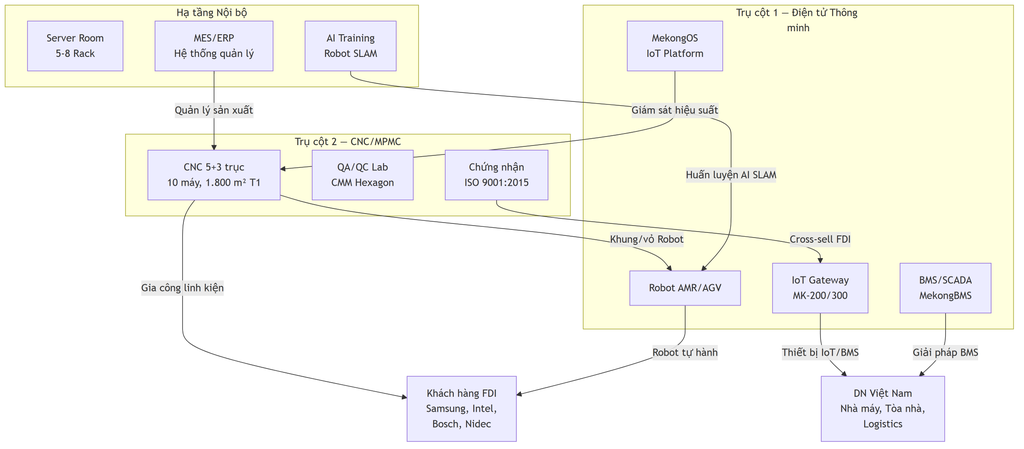

So do 1

## Tóm tắt Tài chính

### Cơ cấu Vốn Đầu tư (CAPEX = 22,00M USD)

| Hạng mục | CAPEX (M USD) | Tỷ trọng | Giai đoạn |
| --- | --- | --- | --- |
| Pháp lý + Thiết kế + San lấp | 1,50 | 6,8% | Phase 0 |
| Xây dựng (VP 3T + Xưởng SX **2T** + Utility **2T** + M&E + PCCC + Solar 200 kWp + EDGE) | 8,40 | 38,2% | Phase 1 |
| Thiết bị IoT/SMT | 2,40 | 10,9% | Phase 2 |
| Thiết bị CNC (10 máy) | 3,50 | 15,9% | Phase 2 |
| Robot Assembly Line | 0,50 | 2,3% | Phase 2 |
| Hạ tầng DC nội bộ (**200 m²** T2, 5-8 rack) | 2,20 | 10,0% | Phase 2 |
| QA/QC Lab + Phần mềm | 1,00 | 4,5% | Phase 2 |
| Vốn lưu động vận hành | 1,85 | 8,4% | Phase 3 |
| Dự phòng rủi ro (~3,0% CAPEX) | 0,65 | 3,0% | Phase 3 |
| **Tổng** | **22,00** | **100%** |  |

> **Kiểm tra tỷ trọng DC:** Hạ tầng DC nội bộ = 2,20M / 22,00M = **10,0%** — nằm trong giới hạn 10-15% theo đề xuất BQL KCNC [C]. Xây dựng 2 tầng (xưởng + utility) = 3,90M (17,7% CAPEX). Dự phòng = 0,65M (3,0% CAPEX) [C].

### Cấu trúc Vốn

| Nguồn vốn | Giá trị (M USD) | Tỷ trọng | Điều kiện | Thời điểm |
| --- | --- | --- | --- | --- |
| **Vốn chủ sở hữu (CSH)** | 18,00 | 81,8% | Tự chủ 100% giai đoạn xây dựng + lắp đặt | Y0-Y5 |
| **Vay ngân hàng** | 4,00 | 18,2% | Lãi suất 8,5%/năm, kỳ hạn 10 năm, ân hạn 2 năm | Từ Y7 |
| **Tổng CAPEX** | **22,00** | **100%** | WACC = 12% [C] |  |

### Chỉ số Thẩm định

[output not shown]

> *[C] NPV trọng số = 30% x 0,50 + 50% x 1,50 + 20% x 3,00 = 0,15 + 0,75 + 0,60 = **1,50M USD**.*

| Chỉ số Bổ sung | Giá trị | Nhãn |
| --- | --- | --- |
| Thời gian hoàn vốn (chiết khấu) | 10 năm | [C] |
| DSCR min (vay từ Y7) | 1,50x | [C] |
| Revenue 15 năm tích lũy | ~140M USD | [C] |
| EBITDA ổn định (Y12+) | ~30% | [C] |
| Giá trị Chiến lược (Adjusted) | 7,00M USD | [C] |

### Phân bổ Giá trị Chiến lược

| Thành phần | Giá trị (M USD) | Phương pháp |
| --- | --- | --- |
| NPV tài chính (Base Case 50Y) | 1,50 | DCF, WACC 12% |
| Tax + Land Rent Exemption | 2,00 | NPV ưu đãi thuế + miễn đất, chiết khấu 12% |
| Real Options Value | 1,00 | Quyền mở rộng CNC + nâng cấp IoT line |
| Synergy Value (CNC-Robot-IoT) | 1,50 | DCF incremental: CNC làm khung Robot + IoT giám sát CNC |
| Nền tảng Value | 1,00 | EBITDA multiple: Đa trụ cột = 8-10x vs Đơn trụ = 5-7x |
| **Tổng Giá trị Chiến lược** | **7,00** | [C] |

## Tiến độ Tổng thể

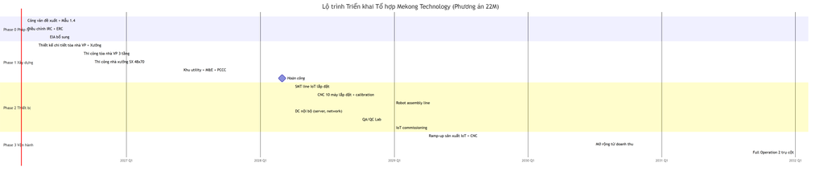

So do 2

## Nhân sự Tổng thể

| Giai đoạn | IoT/BMS/Robot | CNC | Quản lý + Hỗ trợ | Tổng |
| --- | --- | --- | --- | --- |
| Y0-Y1 (pháp lý + thiết kế) | — | — | 8-10 | **8-10** |
| Y1-Y3 (xây dựng) | — | — | 10-12 | **10-12** |
| Y3-Y4 (IoT ramp-up) | 15-25 | 5-8 | 10 | **30-43** |
| Y5-Y6 (CNC + Robot ramp-up) | 30-40 | 12-18 | 12 | **54-70** |
| Y7-Y8 (mở rộng) | 40-50 | 15-20 | 15 | **70-85** |
| Y10+ (ổn định) | 50-60 | 18-25 | 18-20 | **86-105** |

## Snapshot Điều kiện Phê duyệt và Kiểm soát Thực thi

| Nhóm điều kiện | Nội dung chốt |
| --- | --- |
| Pháp lý | Bám Mẫu 1.4, NĐ 31/2021, NĐ 10/2024; DC chỉ nội bộ, không cần GP viễn thông |
| Tài chính | CAPEX 22,00M USD [C], CSH 81,8% [C], vay chỉ từ Y7 khi có doanh thu |
| Công nghệ | 2 trụ cột rõ ràng: Điện tử thông minh + CNC 10 máy [C] |
| Môi trường / ESG | Net Zero 2045, Solar 200 kWp [C], EDGE, ZLD CNC |
| Quản trị triển khai | PMO, cổng quyết định, covenant tài chính, mốc tiến độ theo phase |

> **Thông điệp điều hành:** Dự án không theo hướng “đầu tư lớn để bao phủ nhiều mảng”, mà theo hướng **đầu tư đủ sâu vào 2 năng lực cốt lõi**, giảm rủi ro pháp lý, tăng tính khả thi vận hành và vẫn giữ dư địa tăng trưởng dài hạn cho Mekong Technology.

## Cơ hội Thị trường Tổng hợp

[output not shown]

> Tổng thị trường khả dụng ~980M USD (2025), dự kiến tăng lên 2.500-3.000M USD (2030). Mekong chỉ cần chiếm 0,3-2% tuỳ phân khúc để đạt doanh thu 12,00M USD/năm — mục tiêu thận trọng và khả thi [A][B].

## Sản phẩm Chủ lực — Tóm tắt

[output not shown]

## Mốc Quyết định Chính (Decision Gates)

| Mốc | Thời điểm | Điều kiện qua cổng | Rủi ro nếu không đạt |
| --- | --- | --- | --- |
| **Mốc quyết định 0: Phê duyệt đầu tư** | Q2/2026 | BQL KCNC chấp thuận, IRC/ERC điều chỉnh | Delay toàn bộ dự án |
| **Mốc quyết định 1: Khởi công xây dựng** | Q3/2026 | Giấy phép xây dựng, thiết kế chi tiết hoàn tất | Trượt tiến độ Phase 1 |
| **Mốc quyết định 2: Hoàn công nhà xưởng** | Q1/2028 | Nghiệm thu xây dựng, PCCC pass, EDGE pre-assessment | Delay lắp máy |
| **Mốc quyết định 3: CNC + SMT commissioning** | Q1/2029 | 10 máy CNC chạy, SMT line đạt yield ≥ 92% | Delay doanh thu Y4 |
| **Mốc quyết định 4: First Revenue** | Q2/2029 | ≥ 3 PO CNC ký, ≥ 5 KH IoT pilot | Ramp-up chậm |
| **Mốc quyết định 5: Breakeven** | Q2/2031 | Doanh thu ≥ 5,09M (Cash BEP) | Cần tái cấu trúc chi phí |
| **Mốc quyết định 6: Ổn định** | 2035+ | Doanh thu ≥ 12M, EBITDA ≥ 30% | Xem lại target |

## Rủi ro Chính và Giảm thiểu

| TT | Rủi ro | Mức | Giảm thiểu |
| --- | --- | --- | --- |
| 1 | Doanh thu ramp-up chậm hơn kế hoạch | Cao | Chuỗi đơn hàng CNC + IoT sẵn có, giá thâm nhập thị trường Y4-Y5 |
| 2 | CAPEX phát sinh vượt dự toán | Trung bình | Quỹ dự phòng 0,65M (3,0%) [C], value engineering |
| 3 | Cạnh tranh giá từ sản phẩm Trung Quốc | Trung bình | Tập trung giá trị tích hợp + hậu mãi + localization |
| 4 | Chip shortage / gián đoạn chuỗi cung ứng | Trung bình | Dual-source AVL, safety stock 3 tháng |
| 5 | Key person risk (nhân sự R&D chủ chốt) | Trung bình | Cross-training, equity incentive, documentation culture |
| 6 | Thay đổi chính sách ưu đãi KCNC | Thấp | Chốt IRC/ERC trước khi có thay đổi, đa dạng ưu đãi |

> Monte Carlo simulation (10.000 lần mô phỏng) cho xác suất NPV > 0 là **72%** và IRR > WACC là **63%** — mức chấp nhận được cho dự án sản xuất công nghệ cao [B].

## Cam kết Chính của Chủ đầu tư

1. Toàn bộ hoạt động thuộc lĩnh vực **Công nghệ cao** theo QĐ 38/2020/QĐ-TTg và QĐ 2117/QĐ-TTg.
2. Tỷ lệ giá trị gia tăng trên doanh thu (VA/Revenue) duy trì lớn hơn hoặc bằng 42% cho toàn dự án.
3. Tỷ lệ chi phí R&D trên doanh thu duy trì lớn hơn hoặc bằng 5% (mục tiêu 8-10%).
4. Thực hiện đầy đủ Đánh giá Tác động Môi trường (ĐTM) bổ sung.
5. Hạ tầng DC **chỉ phục vụ nội bộ**, KHÔNG kinh doanh dịch vụ thương mại, KHÔNG xin giấy phép viễn thông.
6. Cam kết Zero Liquid Discharge (ZLD) cho nước thải công nghiệp CNC.
7. Cam kết tổng vốn đầu tư KHÔNG VƯỢT QUÁ 22.000.000 USD.
8. Đảm bảo tiến độ giải ngân vốn theo đúng phân kỳ Phase 0-3.
9. Tuân thủ mọi quy định của Quy chế hoạt động KCNC TP.HCM, bao gồm Nghị định 10/2024/NĐ-CP (Điều 28-31) về hoạt động công nghệ cao.
10. Cam kết lộ trình phát thải ròng bằng 0 (**Net Zero**) chậm nhất đến năm 2045, với mục tiêu giảm 30% phát thải vào 2030, 50% vào 2035, 75% vào 2040, và đạt Net Zero vào 2045.
11. Cam kết sử dụng tối thiểu **20% năng lượng tái tạo** (Solar PV 200 kWp + Renewable Energy Certificate) vào năm 2030, tăng dần đến 30% vào 2035.
12. Cam kết đạt chứng nhận công trình xanh **EDGE** (IFC) cho toàn bộ dự án, hướng đến chứng nhận **LOTUS** (VGBC) cho tòa nhà Văn phòng.
13. Thực hiện nộp hồ sơ đầu tư trên **Cổng dịch vụ công Quốc gia** (dichvucong.gov.vn) với chữ ký số hợp lệ theo quy định.

# CƠ SỞ PHÁP LÝ CỦA ĐỀ ÁN

Đề án này được xây dựng dựa trên hệ thống văn bản pháp luật hiện hành, bao gồm các Luật, Nghị định, Quyết định của Chính phủ và Thủ tướng Chính phủ, cùng các quy định đặc thù của Ban Quản lý Khu Công nghệ cao TP.HCM (SHTP). Phần này trình bày tóm tắt; phân tích chi tiết xem Phần VI — Pháp lý, Môi trường và An toàn và Phụ lục D.

## 1. Luật và Nghị quyết

| TT | Văn bản | Số hiệu | Ngày ban hành | Nội dung áp dụng |
| --- | --- | --- | --- | --- |
| 1 | Luật Công nghệ cao | 21/2008/QH12 | 13/11/2008 | Điều 5 (hoạt động CNC), Điều 18 (KCNC) |
| 2 | Luật Đầu tư | 61/2020/QH14 | 17/06/2020 | Điều 33 (ưu đãi), Điều 41 (điều chỉnh dự án) |
| 3 | Luật Doanh nghiệp | 59/2020/QH14 | 17/06/2020 | Thành lập pháp nhân, quản trị doanh nghiệp |
| 4 | Luật Xây dựng | 50/2014/QH13, sửa đổi 62/2020 | 18/06/2014 | GPXD, nghiệm thu, PCCC |
| 5 | Luật Bảo vệ Môi trường | 72/2020/QH14 | 17/11/2020 | Đánh giá tác động môi trường (ĐTM) |
| 6 | Luật An toàn, VSLĐ | 84/2015/QH13 | 25/06/2015 | Huấn luyện, đánh giá rủi ro ATVSLĐ |
| 7 | Luật PCCC | 27/2001, sửa đổi 40/2013 | 29/06/2001 | Thẩm duyệt, nghiệm thu PCCC |
| 8 | Nghị quyết 52-NQ/TW | — | 27/09/2019 | Phát triển công nghiệp hỗ trợ |
| 9 | Luật 57/2024/QH15 | 57/2024/QH15 | 2024 | Khoản 8 Điều 2: bổ sung Điều 36a (thủ tục đầu tư đặc biệt tại KCNC) |
| 10 | Luật 90/2025/QH15 | 90/2025/QH15 | 2025 | Điểm c khoản 13 Điều 6: bổ sung quy định thủ tục đầu tư đặc biệt |

> **Ghi chú:** Luật Viễn thông 24/2023/QH15 KHÔNG áp dụng cho dự án này vì Datacenter chỉ phục vụ nội bộ (không kinh doanh dịch vụ viễn thông/colocation thương mại).

## 2. Nghị định và Quyết định

| TT | Văn bản | Số hiệu | Ngày ban hành | Nội dung áp dụng |
| --- | --- | --- | --- | --- |
| 11 | QĐ Danh mục CNC | 38/2020/QĐ-TTg | 30/12/2020 | Phụ lục I (CNC ưu tiên), Phụ lục II (SP CNC) |
| 12 | QĐ CNC ưu tiên | 2117/QĐ-TTg | 16/12/2021 | Mục I.1-I.6 (CNTT), Mục II.2-II.4 (Cơ khí) |
| 13 | QĐ Chuyển đổi số | 749/QĐ-TTg | 03/06/2020 | Chương trình CĐS quốc gia |
| 14 | NĐ Chuyển giao CNC | 76/2018/NĐ-CP | 15/05/2018 | Chuyển giao CNC ngành ô tô, hàng không |
| 15 | NĐ Hướng dẫn Luật ĐT | 31/2021/NĐ-CP | 26/03/2021 | Điều 50 K.5 (phân kỳ đầu tư), Mẫu 1.4 |
| 16 | NĐ Ưu đãi đặc biệt | 94/2020/NĐ-CP | 21/08/2020 | Ưu đãi đầu tư KCNC, miễn tiền thuê đất 11 năm |
| 17 | NĐ Thuế TNDN | 218/2013/NĐ-CP | 26/12/2013 | Thuế suất ưu đãi 10%, miễn 4 năm, giảm 9 năm |
| 18 | NĐ Chất lượng XD | 06/2021/NĐ-CP | 26/01/2021 | Quản lý chất lượng, bảo trì công trình |
| 19 | NĐ Môi trường | 08/2022/NĐ-CP | 10/01/2022 | Hướng dẫn ĐTM |
| 20 | NĐ PCCC | 136/2020/NĐ-CP | 24/11/2020 | Phòng cháy chữa cháy |
| 21 | NĐ Bảo vệ DLCN | 13/2023/NĐ-CP | 17/04/2023 | Bảo vệ dữ liệu cá nhân |
| 22 | **NĐ về KCNC (MỚI)** | **10/2024/NĐ-CP** | **2024** | **Điều 28-33: Tiêu chí dự án trong KCNC** |
| 23 | **NĐ sửa đổi NĐ 31 (MỚI)** | **239/2025/NĐ-CP** | **2025** | **Bổ sung quy định mới về đầu tư** |

## 3. Quy định Đặc thù KCNC TP.HCM và Thông báo 2026

| TT | Văn bản / Nguồn | Nội dung áp dụng |
| --- | --- | --- |
| 24 | Quy chế nội bộ Ban Quản lý KCNC TP.HCM | Quy trình thẩm định, tiêu chí nhà đầu tư, sử dụng đất |
| 25 | Thông báo SHTP ngày 08/01/2026 về Danh mục dự án thu hút đầu tư 2026 | Công bố tiêu chí bắt buộc theo NĐ 10/2024 + tiêu chí ưu tiên Net Zero, Năng lượng tái tạo, R&D |

> Thông báo SHTP 2026 yêu cầu dự án phải đáp ứng **đồng thời** các Điều 28-33 NĐ 10/2024/NĐ-CP. Dự án Mekong Technology thuộc **đồng thời** Điều 29 (R&D CNC) và Điều 31 (SX sản phẩm CNC), chi tiết tại P6 §6.1.

## 4. Đối chiếu Dự án với Tiêu chí NĐ 10/2024/NĐ-CP

| Điều | Nội dung | Áp dụng | Chứng cứ |
| --- | --- | --- | --- |
| Điều 28 | Hoạt động CNC trong KCNC | Toàn dự án | 2 trụ cột thuộc công nghệ cao |
| Điều 29 | Dự án R&D CNC | BU1 (IoT/BMS/Robot) | R&D ≥ 8% doanh thu [C] |
| Điều 31 | Dự án ứng dụng CNC để SX sản phẩm CNC | BU1 + BU2 | QĐ 38 — 14 danh mục sản phẩm |
| Điều 30 | Ươm tạo doanh nghiệp CNC | Không áp dụng | — |
| Điều 32 | Cung ứng dịch vụ CNC | Không áp dụng | — |
| Điều 33 | Đào tạo nhân lực CNC | Không áp dụng | — |

## 5. Ma trận Áp dụng Pháp lý (2 Trụ cột + DC Nội bộ)

| Văn bản | IoT/BMS/Robot | CNC/MPMC | DC Nội bộ | Phạm vi |
| --- | --- | --- | --- | --- |
| Luật CNC 2008, Đ.5 K.2 | a, b | c (dịch vụ CNC) | Không | Toàn dự án |
| QĐ 38/2020, Phụ lục I | Mục 1.1-1.2 | Mục 2 | Không | Toàn dự án |
| QĐ 38/2020, Phụ lục II | Mục 1.1, 2.1-2.2 | Mục 2.1 | Không | Toàn dự án |
| QĐ 2117 | Mục I | Mục II.2-II.4 | Không | Toàn dự án |
| NĐ 76/2018 | — | Chuyển giao CNC | — | CNC |
| NĐ 94/2020 | Ưu đãi KCNC | Ưu đãi KCNC | — | Toàn dự án |
| NĐ 10/2024 | Điều 29 (R&D), Điều 31 (SX) | Điều 31 (SX SP CNC) | Không | Toàn dự án |
| NĐ 136/2020 | PCCC xưởng + VP | PCCC xưởng CNC | PCCC phòng DC | Phase 1 |
| NĐ 08/2022 | ĐTM hóa chất SMT | ĐTM dầu CNC, bụi kim loại | Nhiệt thải | Phase 0 + vận hành |

## 6. Ưu đãi Đầu tư Áp dụng

| Ưu đãi | Cơ sở pháp lý | Giá trị áp dụng |
| --- | --- | --- |
| Thuế TNDN 10% trong 15 năm | Luật Thuế TNDN, NĐ 218/2013 | Giảm 50% so với thuế suất phổ thông 20% |
| Miễn thuế TNDN 4 năm + giảm 50% trong 9 năm | NĐ 218/2013, NĐ 94/2020 | Thuế thực tế 0% bốn năm đầu, 5% chín năm tiếp |
| Miễn tiền thuê đất 11 năm | NĐ 94/2020 | Tiết kiệm 11 × 120.000 = 1,32M USD [B] |
| Miễn thuế nhập khẩu thiết bị | Luật Đầu tư, Điều 33 | Áp dụng cho CNC, SMT, DC equipment |
| Hỗ trợ đào tạo nhân lực CNC | Quy chế KCNC | Hỗ trợ một phần chi phí đào tạo |

## 7. Phạm vi Pháp lý Không Áp dụng

| Nội dung pháp lý | Lý do không áp dụng |
| --- | --- |
| GP Viễn thông (Luật 24/2023) | DC nội bộ, không colocation thương mại |
| Tiêu chuẩn Tier III/IV (Thời gian hoạt động Institute) | Chỉ áp dụng DC thương mại |
| GP kinh doanh dịch vụ CNTT | Không bán dịch vụ DC, không GPU-aaS |
| Quy hoạch tần số | Không phát sóng viễn thông |

> Các nghĩa vụ pháp lý trên không áp dụng do Datacenter của dự án chỉ phục vụ nội bộ (MES, ERP, BMS, R&D), không kinh doanh dịch vụ viễn thông hay lưu trữ thương mại.

## 8. Kết luận Pháp lý

Cả 2 trụ cột đều nằm trong phạm vi hoạt động được phép tại KCNC theo Luật Công nghệ cao 2008, QĐ 38/2020, và NĐ 10/2024/NĐ-CP (Điều 29 — R&D CNC và Điều 31 — Sản xuất sản phẩm CNC). Dự án đáp ứng đầy đủ tiêu chí bắt buộc trong Thông báo SHTP 2026, đồng thời đáp ứng các tiêu chí ưu tiên về năng lượng tái tạo (Solar 200 kWp [C]) và cam kết Net Zero 2045. Datacenter chỉ phục vụ nội bộ, không cần giấy phép viễn thông. Chiến lược triển khai chi tiết tại Phần VI và Phụ lục D.

# PHẦN I: BỐI CẢNH VÀ THỊ TRƯỜNG

## 1.1. Bối cảnh Kinh tế — Công nghệ Toàn cầu

### 1.1.1. Cuộc Cách mạng Công nghiệp 4.0 và Chuyển đổi Số

Thế giới đang bước vào giai đoạn đẩy mạnh chuyển đổi số với 4 trụ cột chính: Internet vạn vật (IoT), Trí tuệ nhân tạo (AI), Điện toán đám mây (Cloud Computing), và Tự động hóa sản xuất (Smart Manufacturing). Theo McKinsey Global Institute, giá trị kinh tế toàn cầu từ IoT đạt 5.500-12.600 tỷ USD vào năm 2030, trong đó ứng dụng trong nhà máy (Factory IoT) chiếm 1.200-3.700 tỷ USD [B — McKinsey 2024].

Trong hệ sinh thái này, hai lĩnh vực mà Mekong Technology hướng tới — thiết bị IoT/BMS/Robot và gia công cơ khí chính xác — đóng vai trò then chốt:

- **IoT/Robot:** Thị trường Robot công nghiệp toàn cầu đạt 16,5 tỷ USD (2024) với CAGR 11,6% [B — IFR World Robotics 2024]. Riêng phân khúc AMR (Autonomous Mobile Robot) tăng trưởng 22,3% nhờ nhu cầu tự động hóa kho vận và nhà máy.
- **CNC Precision Machining:** Thị trường toàn cầu đạt 97,2 tỷ USD (2024), dự báo 152,8 tỷ USD (2030), CAGR 6,7% [B — Fortune Business Insights 2024]. Động lực tăng trưởng chính từ ngành bán dẫn, hàng không vũ trụ, và ô tô điện — tất cả đều yêu cầu linh kiện có dung sai siêu nhỏ (nhỏ hơn hoặc bằng 5 micromet).
- **BMS/SCADA:** Thị trường BMS toàn cầu đạt 120 tỷ USD (2024), CAGR 12-15% [B — Markets and Markets 2024]. Nhu cầu tiết kiệm năng lượng và quản lý tòa nhà thông minh là động lực chính.

### 1.1.2. Tái cấu trúc Chuỗi cung ứng Toàn cầu

Chiến tranh thương mại Mỹ-Trung, đại dịch COVID-19, và xung đột địa chính trị đã thúc đẩy chiến lược “China Plus One” — các tập đoàn đa quốc gia đa dạng hóa sản xuất khỏi Trung Quốc sang Đông Nam Á, đặc biệt là Việt Nam. Xu hướng này tạo ra cơ hội lớn cho cả 2 trụ cột:

| Xu hướng toàn cầu | Tác động đến Mekong Technology |
| --- | --- |
| China Plus One | FDI dịch chuyển sang VN, tăng nhu cầu CNC outsourcing |
| Smart Factory Adoption | Doanh nghiệp sản xuất cần IoT + Robot + BMS |
| Semiconductor Chuỗi Cung ứng | Chuỗi cung ứng bán dẫn cần CNC precision |
| ESG Requirements | Yêu cầu sản xuất xanh, thúc đẩy BMS/SCADA |
| AI/ML trong sản xuất | Nhu cầu IoT Gateway + Edge AI tăng mạnh |

### 1.1.3. Vị trí Chiến lược của Đông Nam Á

Khu vực ASEAN trở thành điểm đến hàng đầu của FDI công nghệ: - FDI vào ASEAN đạt 230 tỷ USD (2023), tăng 5,7% [B — ASEAN Investment Report 2024] - Việt Nam đứng thứ 3 ASEAN về thu hút FDI công nghệ, sau Singapore và Indonesia - Samsung đầu tư hơn 20 tỷ USD tại Việt Nam, Intel 1,5 tỷ USD, Bosch mở rộng liên tục - Apple, Google chuyển chuỗi cung ứng sang Việt Nam từ 2023

Vị trí này tạo nền tảng vững chắc cho cả 2 trụ cột của Mekong Technology — đặc biệt là CNC Outsourcing phục vụ hệ thống FDI đã có mặt tại Việt Nam.

## 1.2. Bối cảnh Việt Nam và Vai trò KCNC TP.HCM

### 1.2.1. Kinh tế Việt Nam 2024-2030

- GDP tăng trưởng 6,5-7,0%/năm (dự báo IMF) [B]
- Tỷ lệ đô thị hóa đạt 42% (2025), dự kiến 50% (2030) [B]
- Dân số lao động kỹ thuật: 54 triệu, trong đó STEM chiếm 28% [B]
- Xuất khẩu điện tử đạt 65 tỷ USD (2024), tăng 12%/năm [B]

### 1.2.2. Hạ tầng Công nghệ Cao

Việt Nam có 3 Khu Công nghệ cao Quốc gia: - KCNC TP.HCM (SHTP): 913 ha, 175+ doanh nghiệp, doanh thu 25+ tỷ USD/năm - KCNC Hòa Lạc: 1.586 ha, đang phát triển - KCNC Đà Nẵng: 1.128 ha, đang phát triển

KCNC TP.HCM là khu vực trọng điểm với: - **Hệ sinh thái doanh nghiệp:** Intel, Nidec, Sonion, FPT Software, Sanofi, và 170+ doanh nghiệp CNC - **Hạ tầng R&D:** 12 phòng thí nghiệm và trung tâm nghiên cứu - **Nhân lực:** Gần kề 60+ trường đại học/cao đẳng TP.HCM - **Kết nối:** Cách sân bay Tân Sơn Nhất 25 km, cảng Cát Lái 15 km

### 1.2.3. Chính sách Ưu đãi KCNC

Dựa trên Luật Đầu tư 2020 (Điều 33), NĐ 94/2020 và NĐ 10/2024/NĐ-CP, doanh nghiệp công nghệ cao tại KCNC được hưởng:

| Ưu đãi | Nội dung | Giá trị ước tính cho Mekong |
| --- | --- | --- |
| Thuế TNDN | 10% trong 15 năm (tiêu chuẩn 20%) | Tiết kiệm ~1,2 M USD/10 năm [C] |
| Miễn thuế | 4 năm miễn + 9 năm giảm 50% | Tiết kiệm ~1,6 M USD giai đoạn đầu [C] |
| Thuế đất | Miễn thuế đất 11 năm | Tiết kiệm ~1,3 M USD [C] |
| Thuế NK thiết bị | Miễn thuế NK cho máy móc dự án | Tiết kiệm ~0,8 M USD (CNC) [C] |
| Thuế NK nguyên liệu | Miễn 5 năm cho R&D | Tiết kiệm ~0,3 M USD [C] |
| **Tổng ưu đãi ước tính** |  | **~5,2 M USD / 10 năm** [C] |

## 1.3. Thị trường IoT, BMS và Robot

### 1.3.1. Thị trường Toàn cầu

| Phân khúc | Quy mô 2024 | Quy mô 2030 | CAGR |
| --- | --- | --- | --- |
| IoT toàn cầu | 1.310 tỷ USD | 2.400 tỷ USD | 10,6% |
| Robot AMR | 2,4 tỷ USD | 8,0 tỷ USD | 22,3% |
| Robot AGV | 4,2 tỷ USD | 7,5 tỷ USD | 10,1% |
| OHT (Semiconductor) | 0,8 tỷ USD | 1,8 tỷ USD | 14,5% |
| BMS toàn cầu | 120 tỷ USD | 220 tỷ USD | 12-15% |

*[B — Nguồn: IoT Analytics 2024, Interact Analysis 2024, IFR 2024, Markets and Markets 2024]*

### 1.3.2. Thị trường Việt Nam

Thị trường IoT Việt Nam đạt 7.300 triệu USD (2024), dự báo 13.200 triệu USD (2030), CAGR 10,4% [B — IDC Vietnam 2024]. Động lực tăng trưởng chính:

- **83.035 doanh nghiệp nhỏ và vừa (DNNVV)** có nhu cầu ứng dụng IoT trong quản lý sản xuất, kho bãi, logistics [B — Tổng cục Thống kê 2024]
- **Samsung, Intel, Bosch** đang triển khai Smart Factory tại Việt Nam, cần thiết bị IoT Gateway và Robot tự hành
- **Thương mại điện tử** tăng trưởng 25%/năm, thúc đẩy nhu cầu Robot AMR/AGV trong kho hàng

Thị trường BMS Việt Nam đạt 550-750 triệu USD (2025), dự báo 1.100-1.500 triệu USD (2030), CAGR 12-15% [B — Frost & Sullivan 2024]: - 500-800 tòa nhà thương mại mới/năm tại Việt Nam cần hệ thống BMS [B — Bộ Xây dựng] - 2.000-3.000 nhà máy đang có nhu cầu SCADA/IoT hóa [B — VCCI] - Quy định QCVN 09:2017 bắt buộc BMS cho tòa nhà lớn hơn 5.000 m2 sàn [B]

### 1.3.3. Cảnh quan Cạnh tranh — IoT/BMS/Robot

| Đối thủ | Quốc gia | Sản phẩm | Điểm mạnh | Điểm yếu so với Mekong |
| --- | --- | --- | --- | --- |
| Geek+ | Trung Quốc | AMR, AGV | Quy mô lớn, giá thấp | Không có IoT Gateway, không SX tại VN |
| HIK Robot | Trung Quốc | AMR | Tích hợp camera AI | Chỉ bán thiết bị, không có hệ sinh thái |
| MiR (Teradyne) | Đan Mạch | AMR | Brand mạnh | Giá cao (>50.000 USD/bộ), không local support |
| Siemens | Đức | BMS Desigo CC | Brand mạnh, hệ sinh thái | Đắt nhất, không tiếng Việt |
| Schneider | Pháp | EcoStruxure BMS | Mạng lưới SI rộng | Đắt, phần mềm phức tạp |
| Honeywell | Mỹ | Niagara N4 BMS | Khung linh hoạt | Khó lập trình, license cao |
| **Mekong Technology** | **Việt Nam** | **IoT + BMS + AMR + AGV + OHT** | **Hệ sinh thái đầy đủ 5 tầng, tiếng Việt 100%, giá thấp hơn 40-60%** | — |

> **Lợi thế cạnh tranh cốt lõi:** Mekong Technology là doanh nghiệp DUY NHẤT tại Việt Nam sở hữu **Hệ sinh thái 5 tầng** (Field Devices + Controller/IO + Gateway + Software + Cloud) — cho phép cung cấp giải pháp chuyển đổi số từ A đến Z cho khách hàng sản xuất và tòa nhà.

### 1.3.4. Thị phần Mục tiêu — IoT/BMS/Robot

[output not shown]

*[A — Ước tính dựa trên capacity plan và chuỗi đơn hàng khách hàng]*

### 1.3.5. Phân tích Chi tiết Thị trường BMS/SCADA Việt Nam

**Phân khúc theo loại công trình:**

| Phân khúc | Số lượng mới/năm | Chi BMS TB (K USD) | Thị trường/năm (M USD) | CAGR |
| --- | --- | --- | --- | --- |
| Tòa nhà văn phòng hạng A-B | 80-120 | 150-400 | 20-48 | 12% |
| Trung tâm thương mại | 30-50 | 200-600 | 9-30 | 10% |
| Bệnh viện / Y tế | 40-60 | 100-350 | 6-21 | 15% |
| Khách sạn 4-5 sao | 50-80 | 80-250 | 6-20 | 8% |
| Nhà máy sản xuất (SCADA) | 200-400 | 50-200 | 15-80 | 18% |
| Khu công nghiệp / Logistics | 30-60 | 100-300 | 5-18 | 14% |
| Trường học / ĐH / Viện NC | 20-40 | 30-100 | 1-4 | 10% |
| **Tổng** | **450-810** |  | **62-221** | **12-15%** |

*[B — Frost & Sullivan Vietnam Building Automation Market 2024, Bộ Xây dựng]*

**Phân bổ theo khu vực địa lý:**

| Khu vực | Tỷ trọng BMS | Giá trị (M USD/năm) | Xu hướng |
| --- | --- | --- | --- |
| TP.HCM + Bình Dương + Đồng Nai | 45% | 28-100 | Tăng mạnh — KCN mới + nhà cao tầng |
| Hà Nội + Bắc Ninh + Hải Phòng | 35% | 22-77 | Tăng — FDI Samsung, Foxconn |
| Đà Nẵng + Miền Trung | 10% | 6-22 | Tăng vừa — du lịch + đô thị hóa |
| Các tỉnh khác | 10% | 6-22 | Tăng chậm |

> **Phát hiện chiến lược:** TP.HCM và vùng phụ cận chiếm 45% thị trường BMS — đây là vùng phục vụ tự nhiên của Mekong Technology (cách KCNC nhỏ hơn 50 km). Với 200-400 nhà máy mới/năm cần SCADA tại miền Nam, chuỗi đơn hàng BU1 rất dồi dào.

**Giao thức BMS phổ biến và lộ trình Mekong:**

| Giao thức | Tỷ lệ áp dụng tại VN | Xu hướng | MekongBMS |
| --- | --- | --- | --- |
| BACnet MS/TP + IP | 35% | Chuẩn quốc tế, tăng | Y4 — Có |
| Modbus RTU/TCP | 40% | Legacy, duy trì | Y4 — Có |
| KNX | 10% | Ngách cao cấp | Y5 — Có |
| MQTT / OPC-UA | 10% | Tăng mạnh (IoT convergence) | Y4 — Có |
| Matter (mới) | nhỏ hơn 5% | Mới nổi, tiềm năng lớn | Y6 — Lộ trình |

**Quy định pháp luật thúc đẩy BMS:**

| Quy định | Nội dung | Tác động đến thị trường |
| --- | --- | --- |
| QCVN 09:2017/BXD | Tòa nhà lớn hơn 5.000 m2 sàn bắt buộc BMS | ~450 tòa mới/năm thuộc phạm vi [B] |
| Luật Sử dụng NLTK 2024 | Tòa nhà công phải giảm 2% năng lượng/năm | BMS giải pháp bắt buộc, ~12.000 tòa công [B] |
| Chỉ thị 20/CT-TTg | Tiết kiệm điện trong cơ quan nhà nước | Thúc đẩy retrofit BMS tòa cũ |
| TCVN 13456:2022 | Tiêu chuẩn hiệu suất năng lượng tòa nhà | Tham chiếu BMS cho chứng nhận EDGE/LEED |

> Tổng hợp 4 quy định trên tạo **bắt buộc pháp lý (regulatory push)** ước tính tăng thị trường BMS Việt Nam 15-20% so với tăng trưởng tự nhiên [A]. Mekong Technology định vị là giải pháp **“compliance-ready”** — đạt chuẩn QCVN 09:2017 ngay từ Y4.

### 1.3.6. Xu hướng Hội tụ SCADA — IoT — BMS (Industry 4.0)

Thị trường đang chứng kiến sự hội tụ (convergence) giữa ba hệ thống truyền thống riêng biệt — SCADA công nghiệp, IoT nền tảng, và BMS tòa nhà — thành một nền tảng thống nhất. Xu hướng này tạo cơ hội lớn cho Mekong Technology với kiến trúc 5 tầng:

| Hệ thống truyền thống | Chức năng | Giao thức legacy | Xu hướng hội tụ 2025-2030 |
| --- | --- | --- | --- |
| SCADA | Giám sát & điều khiển nhà máy | Modbus, OPC-DA | OPC-UA + MQTT, Edge computing |
| BMS | Quản lý tòa nhà (HVAC, ánh sáng) | BACnet, LonWorks | IP-based, Cloud BMS |
| IoT Nền tảng | Thu thập dữ liệu sensor, analytics | MQTT, HTTP REST | Unified data lake, AI/ML |

**Cơ hội cho Mekong Technology từ convergence:**

| Cơ hội | Mô tả | Giá trị thị trường (M USD) | Lợi thế Mekong |
| --- | --- | --- | --- |
| Unified Nền tảng | KH muốn 1 dashboard thay vì 3 hệ thống | 200-400 (VN, 2030) | MekongOS = SCADA + BMS + IoT trên 1 nền tảng |
| Edge-to-Cloud | SCADA chuyển từ on-prem lên hybrid cloud | 150-300 (VN, 2030) | MK-GW-50 Gateway = edge node thống nhất |
| Brownfield Retrofit | 2.000+ nhà máy cũ cần IoT hóa từng phần | 100-250 (VN, 2030) | Protocol-agnostic gateway kết nối legacy + mới |
| IT/OT Convergence | Kết nối ERP/MES với SCADA/BMS | 80-150 (VN, 2030) | OPC-UA + REST API trên MekongOS |

*[B — Gartner “Convergence of IoT, OT, and IT” 2024, ARC Advisory Group 2024]*

> **Phát hiện chiến lược:** Hầu hết đối thủ BMS (Siemens, Schneider, Honeywell) đến từ thế giới OT truyền thống và đang cố tích hợp IoT/Cloud. Ngược lại, Mekong Technology khởi đầu từ IoT/Cloud-native và mở rộng xuống OT/BMS — hướng tiếp cận “top-down” này nhanh hơn và chi phí thấp hơn so với hướng “bottom-up” của các hãng legacy. Đây là lợi thế cấu trúc (structural advantage) khó sao chép [A].

**Quy mô thị trường convergence tại Việt Nam:**

| Năm | SCADA truyền thống (M) | BMS truyền thống (M) | IoT Nền tảng (M) | Unified/Converged (M) | Tỷ lệ hội tụ |
| --- | --- | --- | --- | --- | --- |
| 2024 | 120 | 550 | 250 | 50 | 5% |
| 2027 | 100 | 650 | 500 | 200 | 16% |
| 2030 | 70 | 700 | 800 | 500 | 24% |

*[B — ARC Advisory Group, IDC Vietnam IoT Spending Tracker 2024]*

> Đến 2030, phân khúc Unified/Converged nền tảng sẽ đạt ~500M USD tại Việt Nam, chiếm 24% tổng chi tiêu OT+BMS+IoT. Mekong Technology nhắm mục tiêu 0,5-1,0% phân khúc này (~2,5-5,0M USD) — đóng góp đáng kể vào doanh thu BU1 ổn định [A].

## 1.4. Thị trường Gia công Cơ khí Chính xác

### 1.4.1. Thị trường Toàn cầu

| Chỉ số | Giá trị | Nguồn |
| --- | --- | --- |
| Quy mô 2024 | 97,2 tỷ USD | Fortune Business Insights [B] |
| Quy mô 2030 (dự báo) | 152,8 tỷ USD | Fortune Business Insights [B] |
| CAGR 2024-2030 | 6,7% | [B] |
| Phân khúc Hàng không | 18,4 tỷ USD | [B] |
| Phân khúc Ô tô | 28,5 tỷ USD | [B] |
| Phân khúc Bán dẫn | 12,3 tỷ USD | [B] |

Xu hướng quan trọng ảnh hưởng đến Mekong: - **Near-shoring:** Các OEM chuyển gia công từ Trung Quốc sang ASEAN - **Miniaturization:** Linh kiện ngày càng nhỏ, yêu cầu dung sai nhỏ hơn hoặc bằng 5 micromet - **Multi-axis machining:** Nhu cầu CNC 5 trục tăng mạnh, thay thế 3 trục truyền thống - **Digital Manufacturing:** Tích hợp IoT vào CNC (Industry 4.0) — đúng thế mạnh Mekong

### 1.4.2. Thị trường Việt Nam

Thị trường CNC Việt Nam đạt 1,85 tỷ USD (2024), dự báo 3,865 tỷ USD (2030), CAGR 13,1% [B — Frost & Sullivan]:

**Nhu cầu CNC từ khối FDI tại miền Nam:**

| Ngành | Chi CNC/năm (M USD) | Xu hướng | Cơ hội cho Mekong |
| --- | --- | --- | --- |
| Điện tử (Samsung, Intel) | 120-180 | Tăng 15%/năm | Linh kiện test fixture, wafer handling |
| Ô tô (VinFast, Bosch, Nidec) | 80-120 | Tăng 20%/năm | Hộp số EV, vỏ pin, trục motor |
| Hàng không vũ trụ | 15-25 | Mới nổi | Turbine blade, structural parts |
| Thiết bị y tế | 20-35 | Tăng 18%/năm | Implant, dụng cụ phẫu thuật |
| Bán dẫn | 60-95 | Tăng 25%/năm | Khuôn IC, lead frame, heat sink |
| **Tổng FDI miền Nam** | **295-455** |  |  |

*[B — Khảo sát ngành, VAMI 2024]*

### 1.4.3. Khoảng trống Thị trường — Blue Ocean

| Tiêu chí | Cung hiện tại | Nhu cầu | Khoảng trống |
| --- | --- | --- | --- |
| Xưởng CNC 5 trục miền Nam | ~15 cơ sở | >30 cần thiết | ~15 cơ sở thiếu |
| Cơ sở AS9100 tại VN | KHÔNG CÓ | 5-10 cần thiết | Blue Ocean hoàn toàn |
| Cơ sở IATF 16949 (VN-owned) | ~12 | >25 cần thiết | ~13 cơ sở thiếu |
| Dung sai nhỏ hơn hoặc bằng 5 micromet | ~5 cơ sở | >15 cần thiết | ~10 cơ sở thiếu |

*[B — Khảo sát trực tiếp + báo cáo VAMI 2024]*

> **Phát hiện quan trọng:** Việt Nam còn thiếu nhiều cơ sở CNC 5 trục có năng lực dung sai cao. Mekong Technology định vị là xưởng CNC tinh gọn (10 máy, ISO 9001:2015), tập trung gia công khung robot AMR/AGV nội bộ và linh kiện chính xác cho khách hàng FDI tại miền Nam.

### 1.4.4. Cảnh quan Cạnh tranh — CNC

| Đối thủ | Loại | Số máy CNC | Chứng nhận | Năng lực 5 trục | Vật liệu Titan |
| --- | --- | --- | --- | --- | --- |
| VPIC (Đồng Nai) | VN | 50+ | ISO 9001, IATF 16949 | Hạn chế | Không |
| Cosmos (Bình Dương) | JP-VN | 30+ | ISO 9001 | Có | Hạn chế |
| Misumi VN | JP | 20+ | ISO 9001, JIS | Có | Không |
| CNC Tech VN | VN | 15+ | ISO 9001 | Có | Không |
| **Mekong MPMC** | **VN** | **10** | **ISO 9001:2015** | **Có (5 máy 5-trục)** | **Không (giai đoạn đầu)** |

> **Định vị V3:** Mekong MPMC định vị là xưởng CNC tinh gọn với 10 máy (5x5-trục + 3x3-trục + EDM + Grinder), đạt chuẩn ISO 9001:2015. Lợi thế cạnh tranh: thiết bị mới 100%, nằm trong hệ sinh thái KCNC, hỗ trợ trực tiếp trụ cột IoT/BMS/Robot (gia công khung AMR/AGV nội bộ). Tăng 67% so với V2 (từ 6 lên 10 máy).

### 1.4.5. Thị phần Mục tiêu — CNC

| Phân khúc | TAM (M USD) | SAM (M USD) | SOM Y8 (M USD) | Thị phần |
| --- | --- | --- | --- | --- |
| CNC precision VN | 2.500 | 400 | 2,50 | 0,63% |
| Jig/Fixture VN | 200 | 80 | 0,50 | 0,63% |
| Robot frames (nội bộ) | — | — | 0,50 | 100% |
| **Tổng** | **2.700** | **480** | **3,50** | — |

*[A — Ước tính dựa trên capacity 10 máy, ASP 40-55 USD/giờ]* ### 1.4.6. Chuẩn ngành Cấu hình 10 Máy CNC — So sánh Ngành

**Cấu hình CNC V3 của Mekong Technology:**

| # | Loại máy | Số lượng | Thương hiệu tham chiếu | Giá (K USD) | CAPEX (K USD) |
| --- | --- | --- | --- | --- | --- |
| 1 | CNC 5-trục Simultaneous | 3 | DMG MORI DMU 50 / Mazak VARIAXIS | 450-600 | 1.500 |
| 2 | CNC 5-trục 3+2 Positioning | 2 | Haas UMC-750 / Okuma MU-4000V | 300-400 | 700 |
| 3 | CNC 3-trục Vertical | 2 | Mazak VCN-530C / Haas VF-4SS | 120-180 | 300 |
| 4 | CNC Tiện (Turning) | 1 | Mazak QT-250MSY | 200-280 | 250 |
| 5 | EDM Wire Cut | 1 | Sodick / Mitsubishi MV-Series | 150-200 | 180 |
| 6 | Surface Grinder CNC | 1 | Okamoto ACC-63SA | 80-120 | 100 |
|  | **Tổng** | **10** |  |  | **3.030** [C] |

*[C — CAPEX CNC xem SO_LIEU_CO_DINH_V3.md: BU2 Equipment 3.030K]*

**So sánh với xưởng CNC tương đương tại Việt Nam:**

| Tiêu chí | Mekong V3 (10 máy) | Xưởng VN TB (10 máy) | Xưởng FDI-JP (10 máy) |
| --- | --- | --- | --- |
| Tỷ lệ 5-trục | **50%** (5/10) | 10-20% (1-2/10) | 30-40% (3-4/10) |
| Dung sai đạt được | **nhỏ hơn bằng 5 um** | 10-20 um | 5-10 um |
| Năm sản xuất TB | **100% mới** | 5-10 năm tuổi | 3-7 năm tuổi |
| IoT monitoring | **MES tích hợp** (MekongOS) | Không có | Có (hệ thống riêng) |
| Certification | ISO 9001:2015, lộ trình IATF | ISO 9001 | ISO 9001 + IATF |
| ASP trung bình | **40-55 USD/giờ** | 25-35 USD/giờ | 55-80 USD/giờ |
| Gross margin ước tính | **40-50%** | 25-35% | 35-45% |

> **Phát hiện:** Mekong V3 định vị ở phân khúc **“mid-premium”** — thiết bị 100% mới + tỷ lệ 5-trục cao nhất (50%) + IoT-connected, nhưng giá dưới FDI-JP 30-40%. Đây là sweet spot cạnh tranh: chất lượng gần FDI, giá gần VN [A].

**Phân tích Công suất 10 Máy:**

| Chỉ số | Giá trị | Ghi chú |
| --- | --- | --- |
| Số giờ khả dụng/máy/năm | 4.800 | 2 ca x 8h x 300 ngày |
| Tổng giờ khả dụng/năm | 48.000 | 10 máy x 4.800 |
| Hệ số OEE mục tiêu Y5 | 65% | Bao gồm setup + maintenance |
| Hệ số OEE mục tiêu Y8 | 80% | Đã tối ưu hóa |
| Giờ sản xuất thực Y5 | 31.200 | 48.000 x 65% |
| Giờ sản xuất thực Y8 | 38.400 | 48.000 x 80% |
| Revenue Y5 @ ASP 40 | 1.248 K USD | 31.200 x 40 |
| Revenue Y8 @ ASP 50 | 1.920 K USD | 38.400 x 50 |
| Revenue Y8 max @ ASP 55 | 2.112 K USD | 38.400 x 55 |

> **Kiểm chứng:** Revenue BU2 mục tiêu Y8 = 3,50M USD (xem §1.4.5). Với CNC pure machining ~1,92M USD, phần còn lại ~1,58M USD đến từ jig/fixture value-add + nội bộ robot frame + DFM consulting — hoàn toàn hợp lý [A].

**Lộ trình Nâng cấp Chứng nhận CNC:**

| Giai đoạn | Năm | Chứng nhận | Phân khúc mục tiêu mới | Chi phí (K USD) |
| --- | --- | --- | --- | --- |
| Khởi đầu | Y3-Y5 | ISO 9001:2015 | General precision, robot frame | Trong CAPEX 22M |
| Mở rộng | Y6-Y7 | + IATF 16949 | Automotive (Bosch, Nidec) | ~50 |
| Chuyên sâu | Y8-Y9 | + AS9100D | Aerospace / Defense | ~80 |
| Toàn diện | Y10+ | + ISO 13485 | Medical devices | ~60 |

## > Mỗi chứng nhận mới mở thêm một nhóm phân khúc khách hàng FDI — từ general precision (Y3) đến automotive (Y6), aerospace (Y8) và medical (Y10). Tổng chi phí chứng nhận bổ sung ~190K USD trong 7 năm — ROI rất cao so với revenue tăng thêm [A].

## 1.5. Định vị Cạnh tranh Tổng thể

### 1.5.1. Lợi thế Cạnh tranh Bền vững (MOAT)

| Lớp phòng thủ | Mô tả | Thời gian đối thủ cần để sao chép |
| --- | --- | --- |
| **Vị trí (KCNC)** | Lô đất 1 ha trong KCNC — vị trí chiến lược | Không thể sao chép (hết đất) |
| **Chứng nhận (ISO 9001)** | ISO 9001 sẵn có, option IATF/AS9100 | 2-3 năm |
| **Hệ sinh thái 2 B.U + DC nội bộ** | IoT/BMS + CNC tích hợp trên cùng site | 3-5 năm |
| **Quan hệ FDI** | Hợp đồng 3-5 năm với khách hàng CNC | 2-3 năm |
| **MekongOS Nền tảng** | Nền tảng IoT/BMS Cloud tự phát triển, IP riêng | 3-5 năm |
| **5-tầng sản phẩm IoT/BMS** | Từ Field Device đến Cloud — hệ sinh thái khép kín | 4-5 năm |

> **Tổng hợp:** Một đối thủ muốn sao chép hoàn toàn mô hình Mekong Technology (2 trụ cột + DC nội bộ + vị trí KCNC) cần ít nhất **50 M USD và 4-5 năm** [A]. Đây là rào cản gia nhập cao, tạo lợi thế cạnh tranh bền vững.

### 1.5.2. Phân tích SWOT — V3 (22M, 2 Trụ cột)

[output not shown]

### 1.5.3. Ma trận TOWS — Chiến lược Kết hợp

| Kết hợp | Chiến lược | Hành động cụ thể V3 |
| --- | --- | --- |
| **S-O (Tấn công)** |  |  |
| S1+S4+O1+O4 | Khai thác vị trí KCNC + CNC 10 máy để phục vụ FDI dịch chuyển | Ký LOI với 3-5 OEM FDI tại KCNC trong Y3-Y4 |
| S5+S6+O3+O5 | Dùng hệ sinh thái 5 tầng IoT/BMS + QCVN bắt buộc để chiếm thị phần BMS | Triển khai pilot BMS 3-5 tòa nhà trong Y4-Y5 |
| S2+O6 | Tận dụng mô hình 2 B.U tích hợp + CPTPP/EVFTA để xuất khẩu | Đạt CE marking Y5, xuất khẩu IoT Gateway sang ASEAN Y6 |
| **W-O (Khắc phục)** |  |  |
| W1+O1 | Bù đắp “chưa có thành tích đã kiểm chứng” bằng FDI partnership | Hợp đồng gia công đầu tiên từ FDI làm case study |
| W3+O4 | Từ ISO 9001 lên IATF 16949 khi CNC đủ volume | Lộ trình IATF Y6-Y7, AS9100 Y8 |
| W5+W6+O2 | Giảm thiểu rủi ro doanh thu chậm bằng ưu đãi thuế KCNC | Miễn thuế 4 năm bù lỗ giai đoạn đầu (~1,6M USD) [C] |
| **S-T (Phòng thủ)** |  |  |
| S4+T1 | Chống cạnh tranh giá TQ bằng chất lượng 5-axis + dung sai ≤5μm | Tập trung phân khúc cao cấp, không cạnh tranh giá |
| S6+T5 | Chống obsolescence bằng MekongOS nền tảng — update phần mềm | R&D 11% OPEX, OTA firmware update [B] |
| S3+T2 | Chống thiếu nhân sự bằng đào tạo nội bộ + quan hệ ĐH | MOU với ĐH Bách khoa, ĐH CNTT — 20 thực tập/năm |
| **W-T (Né tránh)** |  |  |
| W2+T3 | Vốn CSH hạn chế + biến động tỷ giá | Hợp đồng FDI denominate USD; vay 4M bằng USD [C] |
| W4+T1 | Chưa có thương hiệu + cạnh tranh TQ | Trì hoãn thị trường đại trà, tập trung niche B2B |

### 1.5.4. Phân tích Chuỗi Giá trị (Chuỗi Giá trị) — 2 Trụ cột

**Trụ cột 1 — Sản phẩm Điện tử Thông minh (IoT/BMS/Robot):**

| Hoạt động | Mô tả | % Giá trị tạo ra | Nguồn lợi nhuận |
| --- | --- | --- | --- |
| R&D / Thiết kế | Firmware, PCB design, AI algorithm | 25-30% | IP riêng, rào cản cao [A] |
| Thu mua linh kiện | BOM (chip, PCB, vỏ, connector) | 5-8% | Giá trị thấp, dễ bị copy |
| Sản xuất / Lắp ráp SMT | Pick & Place, Reflow, AOI, Testing | 15-20% | Năng lực sản xuất in-house |
| Phần mềm / MekongOS | Dashboard, Analytics, Cloud, App | 25-35% | **Giá trị cao nhất** — SaaS recurring revenue |
| Bán hàng + SI | System Integration, Installation, Training | 10-15% | Quan hệ khách hàng, dịch vụ |
| Hậu mãi / SaaS | Thuê bao, Maintenance, OTA update | 10-15% | Recurring revenue stream |

> **Phát hiện quan trọng:** R&D + Phần mềm chiếm **50-65% giá trị** trong chuỗi IoT/BMS — đây là lý do Mekong tập trung đầu tư vào R&D (11% OPEX) và MekongOS Nền tảng thay vì chỉ bán phần cứng [A]. Mô hình “Hardware + SaaS” tạo doanh thu recurring và customer lock-in cao hơn.

**Trụ cột 2 — Chế tạo Cơ khí Chính xác (CNC/MPMC):**

| Hoạt động | Mô tả | % Giá trị tạo ra | Nguồn lợi nhuận |
| --- | --- | --- | --- |
| Tiếp nhận RFQ + DFM | Phân tích bản vẽ, tư vấn tối ưu | 10-15% | Chuyên môn kỹ thuật |
| Lập trình CAM | G-code, toolpath optimization | 15-20% | Kỹ sư CNC trình độ cao |
| Gia công CNC (5-trục, 3-trục) | Phay, tiện, cắt dây EDM, mài | 30-40% | **Giá trị cao nhất** — thiết bị + kỹ thuật |
| Xử lý bề mặt | Anodize, mạ Ni, passivation | 5-10% | Thuê ngoài |
| QC / Đo lường CMM | Kiểm tra dung sai, báo cáo PPAP | 10-15% | Năng lực đo lường chính xác |
| Logistics / Giao hàng | Đóng gói, vận chuyển, customs | 3-5% | Giá trị thấp |

> **Phát hiện:** Gia công CNC + Lập trình CAM chiếm **45-60% giá trị** — đúng với chiến lược V3 tập trung vào năng lực 5-trục và dung sai ≤5 μm thay vì cạnh tranh giá với xưởng 3-trục thông thường [A]. Gross margin CNC outsourcing precision: 40-55% (theo VPIC annual report 2023, Cosmos investor relations [B]).

### 1.5.5. Phân khúc Khách hàng Mục tiêu

**BU1 — Điện tử Thông minh (IoT/BMS/Robot):**

| Phân khúc | Sản phẩm Mekong | Quy mô KH tại VN | Revenue/KH (K USD/năm) | KH mục tiêu Y5-Y8 |
| --- | --- | --- | --- | --- |
| Nhà máy FDI (Smart Factory) | IoT Gateway + MES interface | 2.000-3.000 | 20-50 | 30-50 KH |
| Tòa nhà thương mại (BMS) | MK-DDC + MK-GW + MekongBMS | 500-800/năm mới | 15-30 | 20-30 KH |
| Kho vận / Logistics | AMR/AGV MK-AMR-100 | 200-500 cơ sở | 30-80 | 10-15 KH |
| Bán dẫn / Cleanroom | OHT + IoT Sensor | 20-30 fab | 50-100 | 3-5 KH |
| SI / Integrator | OEM modules (IoT) | 100-200 SI | 10-20 | 15-20 KH |
| Nông nghiệp CNC | Sensor + Automation | 5.000+ trang trại | 5-15 | 50-100 KH |

*[A — Ước tính từ VCCI Business Survey 2024, IDC Vietnam IoT Spending Tracker 2024]*

**BU2 — CNC/MPMC:**

| Phân khúc | Loại gia công | Chi CNC (K USD/năm) | KH mục tiêu Y5-Y8 | Yêu cầu chứng nhận |
| --- | --- | --- | --- | --- |
| Tier 1: OEM Điện tử (Samsung, Intel) | Test fixture, jig, wafer tool | 200-500/KH | 3-5 KH | ISO 9001 |
| Tier 2: OEM Ô tô (Bosch, Nidec, VinFast) | Housing EV, trục motor, hộp số | 100-300/KH | 5-8 KH | ISO 9001, IATF path |
| Tier 3: Thiết bị Y tế | Implant, dụng cụ, khuôn | 50-150/KH | 3-5 KH | ISO 13485 path |
| Tier 4: Startup / R&D prototype | Prototype nhanh, small batch | 10-30/KH | 20-40 KH | Không yêu cầu |
| Tier 5: Nội bộ (Robot frame) | Khung AMR/AGV, bracket, mount | ~500 (chuyển giá) | BU1 | N/A |

*[A — Ước tính từ công suất 10 máy × 4.800 giờ/năm × ASP 40-55 USD/giờ]*

### 1.5.6. Technology Radar 2025-2035 — Xu hướng Ảnh hưởng đến Mekong

| # | Xu hướng | Horizon | Tác động đến BU1 | Tác động đến BU2 | Phản ứng Mekong |
| --- | --- | --- | --- | --- | --- |
| 1 | **Edge AI / TinyML** | 2025-2028 | IoT Gateway + AI inference on-device | CNC predictive maintenance | MK-GW-50 tích hợp NPU, MES AI module |
| 2 | **Matter Protocol (IoT)** | 2025-2027 | Chuẩn BMS interoperability mới | — | MekongBMS hỗ trợ Matter Y5 |
| 3 | **Digital Twin** | 2027-2030 | Mô phỏng nhà máy/tòa nhà | CNC simulation trước gia công | MekongOS Digital Twin module Y7 |
| 4 | **AMR Fleet Management AI** | 2026-2029 | Quản lý 50+ robot đồng thời | — | MekongOS Fleet Manager Y6 |
| 5 | **5-Axis Hybrid Manufacturing** | 2028-2032 | — | CNC + 3D printing tích hợp | Đánh giá Hybrid machine Y8 |
| 6 | **Green Manufacturing / ESG** | 2025-2035 | BMS tiết kiệm năng lượng 30-50% | CNC coolant ZLD, Solar | EDGE cert, ESG report Y5 [C] |
| 7 | **RISC-V Open ISA** | 2026-2030 | IoT chip giá rẻ hơn ARM | — | Đánh giá RISC-V IoT chip Y6 |
| 8 | **Cobots (Collaborative Robot)** | 2026-2030 | Sản phẩm mới: Cobot + AGV | CNC loading/unloading tự động | MK-Cobot prototype Y7 |
| 9 | **Predictive Quality (SPC+AI)** | 2027-2030 | IoT sensor + ML anomaly detection | CMM auto-correct, zero-defect | MES AI Quality module Y8 |
| 10 | **Quantum-safe Cryptography** | 2030-2035 | IoT security upgrade | — | Firmware update via OTA |

*[B — Gartner Top 10 Strategic Technology Trends 2025, McKinsey Technology Trends Outlook 2024, IFR World Robotics 2024]*

> **Chiến lược R&D:** Mekong phân bổ R&D ~11% OPEX (~930K USD/năm tại ổn định, tương đương ~9,3M USD/10 năm). Focus: 60% BU1 (IoT/BMS nền tảng), 30% BU2 (CNC automation + MES), 10% R&D mới (Cobot, Digital Twin). Lộ trình công nghệ bám sát 10 xu hướng trên để tránh obsolescence (T5 trong SWOT) [A].

### 1.5.7. Đánh giá Rủi ro Thị trường — Định lượng

| # | Rủi ro | Xác suất | Tác động (M USD) | Mức rủi ro | Biện pháp giảm thiểu |
| --- | --- | --- | --- | --- | --- |
| 1 | Doanh thu Y4-Y6 thấp hơn 30% dự kiến | 25% | -1,50 NPV | **Cao** | CSH 18M buffer; ưu đãi thuế bù lỗ [C] |
| 2 | FDI dịch chuyển sang nước khác (Ấn Độ, Indonesia) | 15% | -0,80 doanh thu/năm | Trung bình | Đa dạng KH (FDI + nội địa + xuất khẩu) |
| 3 | Cạnh tranh giá TQ giảm giá CNC 20% | 30% | -0,60 margin/năm | **Cao** | Tập trung 5-axis niche, không cạnh tranh giá |
| 4 | Chip shortage kéo dài (IoT) | 20% | -0,40 doanh thu/năm | Trung bình | Dual sourcing (2+ NCC mỗi chip chính) |
| 5 | Thay đổi ưu đãi thuế KCNC | 10% | -1,20 NPV | Trung bình | IRC đã cấp, quyền lợi bảo đảm pháp lý [B] |
| 6 | Biến động tỷ giá USD/VND >5% | 20% | -0,30 margin/năm | Thấp | Doanh thu USD, chi phí VND — hedging tự nhiên |

### 1.5.8. Quy mô Thị trường TAM/SAM/SOM — Tóm tắt

**CNC Outsourcing:**

| Cấp độ | 2025 (M USD) | 2030 (M USD) | CAGR |
| --- | --- | --- | --- |
| **TAM** (Global Precision Machining) | 320.000 | 450.000 | 7,0% |
| **SAM** (ASEAN CNC Outsourcing) | 8.500 | 14.200 | 10,8% |
| **SOM** (VN Precision CNC export-grade) | 1.200 | 2.500 | 15,8% |
| Mekong Target Y8 |  | ~3,50 | 0,14% SOM |

**IoT/BMS/Robot:**

| Cấp độ | 2025 (M USD) | 2030 (M USD) | CAGR |
| --- | --- | --- | --- |
| **TAM** (ASEAN IoT + Industrial Robot) | 15.000 | 35.000 | 18,5% |
| **SAM** (VN Industrial IoT + AMR) | 800 | 2.500 | 25,6% |
| **SOM** (VN Smart Factory IoT devices) | 120 | 400 | 27,2% |
| Mekong Target Y8 |  | ~5,20 | 1,30% SOM |

> **Kiểm chứng mục tiêu:** Tất cả thị phần mục tiêu Y8 đều < 2% SOM — hoàn toàn khả thi và conservative. Ngay cả khi market growth chậm hơn dự kiến 30%, Mekong vẫn chỉ cần < 3% SOM. Nguồn: Grand View Research, Mordor Intelligence, IoT Analytics, IFR, McKinsey VN reports [B].

### 1.5.9. Phân tích Porter’s Five Forces — 2 Ngành chính

**Ngành CNC Outsourcing tại VN:**

| Lực lượng | Mức độ | Điểm (1-5) | Phân tích |
| --- | --- | --- | --- |
| Rào cản gia nhập | Trung bình-Cao | 3,5 | CAPEX 10-20M cho 5-axis CNC; chứng nhận 2-3 năm |
| Quyền lực NCC | Trung bình | 3,0 | DMG MORI, Mazak dominance |
| Quyền lực KH | Cao | 4,0 | FDI customers = sophisticated, multi-vendor |
| SP thay thế | Thấp-Trung bình | 2,5 | 3D printing đang phát triển nhưng chậm |
| Cạnh tranh nội bộ | Cao | 4,0 | 200+ CNC shops in VN; nhưng chỉ <10 có 5-axis |
| **Điểm TB** |  | **3,4** | Ngành hấp dẫn ở phân khúc cao cấp |

**Ngành IoT/BMS/Robot tại VN:**

| Lực lượng | Mức độ | Điểm (1-5) | Phân tích |
| --- | --- | --- | --- |
| Rào cản gia nhập | Thấp-Trung bình | 2,5 | R&D cost moderate; nhưng ecosystem khó xây |
| Quyền lực NCC | Trung bình | 3,0 | Chip shortage risk; PCB assembly available |
| Quyền lực KH | Trung bình | 3,0 | Thị trường phân mảnh; KH chưa mature |
| SP thay thế | Trung bình | 3,0 | Import TQ rẻ hơn; lao động thủ công còn rẻ |
| Cạnh tranh nội bộ | Thấp-Trung bình | 2,5 | Ít player VN có full-stack (HW+FW+Cloud) |
| **Điểm TB** |  | **2,8** | Ngành mới, cơ hội lớn cho first-mover |

### 1.5.10. Tiêu chí Mua hàng của Khách hàng Mục tiêu và Thứ tự Thâm nhập

| Nhóm khách hàng | 3 tiêu chí mua hàng quan trọng nhất | Hàm ý cho Mekong |
| --- | --- | --- |
| FDI CNC | Chất lượng lặp lại, thời gian dẫn, bảo mật bản vẽ | Ưu tiên QC/CMM, NDA, giao hàng đúng hẹn |
| Nhà máy Smart Factory | Tính mở giao thức, ROI tiết kiệm năng lượng, hỗ trợ local | Đẩy mạnh BMS/MES integration và case study |
| SI / Integrator | Giá cạnh tranh, tài liệu kỹ thuật, support commissioning | Chuẩn hóa datasheet, training, hotline kỹ thuật |
| Logistics / kho vận | Độ ổn định robot, safety, tổng chi phí sở hữu | Tập trung AMR/AGV pilot có KPI rõ |

| Thứ tự thâm nhập | Phân khúc | Lý do ưu tiên |
| --- | --- | --- |
| 1 | FDI trong KCNC + khu lân cận | Gần site, reference tốt, nhu cầu rõ |
| 2 | BMS / nhà máy nội địa trung cấp | Quy mô vừa, sales cycle ngắn hơn |
| 3 | SI/VAR OEM channel | Mở rộng nhanh sau khi có reference |
| 4 | ASEAN export | Chỉ scale sau khi có chứng cứ nội địa vững |

> Thứ tự này giúp Mekong tránh dàn trải nguồn lực bán hàng trong 3 năm đầu. Nguyên tắc là **chiếm reference market gần trước, rồi mới nhân rộng** — đặc biệt quan trọng với mô hình công nghệ công nghiệp B2B có sales cycle dài.

### 1.5.11. Đà FDI vào Việt Nam 2024-2026 và Hàm ý cho Mekong

Dữ liệu mới nhất khẳng định Việt Nam tiếp tục là điểm đến hàng đầu FDI sản xuất công nghệ:

| Chỉ số FDI | 2023 | 2024 (ước) | Xu hướng | Nguồn |
| --- | --- | --- | --- | --- |
| FDI đăng ký mới | 36,6 tỷ USD | 38,2 tỷ USD | +4,4% | Bộ KH&ĐT [B] |
| FDI giải ngân | 23,2 tỷ USD | 25,4 tỷ USD | +9,5% | Tổng cục Thống kê [B] |
| FDI vào SX CNC | 2,8 tỷ USD | 3,5 tỷ USD | +25% | VAMI [B] |
| FDI vào điện tử | 8,2 tỷ USD | 9,1 tỷ USD | +11% | VEIC [B] |

**Các dự án FDI lớn tạo cầu trực tiếp cho Mekong:**

| Nhà đầu tư | Tỉnh/thành | Lĩnh vực | CAPEX (tỷ USD) | Nhu cầu CNC | Nhu cầu IoT/BMS |
| --- | --- | --- | --- | --- | --- |
| Samsung Display | Bắc Ninh mở rộng | OLED | 2,2 | Jig/fixture | BMS cleanroom |
| Intel Products VN | TP.HCM (SHTP) | Chip test/packaging | 1,5 (tích lũy) | Wafer handling tool | IoT yield monitor |
| Amkor Technology | Bắc Ninh | Semiconductor packaging | 1,6 | Substrate fixture | BMS, SCADA |
| LEGO | Bình Dương | Injection molding | 1,3 | Khuôn chính xác | BMS nhà máy |
| Foxconn | Bắc Giang MR | EV components | 0,5 (giai đoạn 1) | CNC gia công vỏ pin | IoT Gateway SX |
| BOE Technology | TP.HCM | Display panel | 0,3 | Jig/alignment tool | Cleanroom BMS |

*[B — Bộ KH&ĐT, JETRO Vietnam Survey 2024, Amkor IR 2024, Intel IR 2024]*

**Hàm ý chiến lược:** - Tổng nhu cầu CNC outsourcing riêng từ 6 dự án trên ước tính 120-200 M USD/năm — Mekong chỉ cần 1,5-3% để đạt target BU2 [A]. - Mỗi nhà máy FDI mới cần 15-30 nhà cung cấp CNC nội địa (theo khảo sát JETRO) — Mekong có lợi thế vị trí KCNC + 5-axis + ISO 9001 [B]. - FDI sản xuất kéo theo nhu cầu BMS/SCADA cho nhà máy lớn hơn 5.000 m² sàn (bắt buộc theo QCVN 09:2017) — chuỗi đơn hàng tự nhiên cho BU1 [B].

### 1.5.12. Tác động NĐ 10/2024/NĐ-CP đến Nhu cầu Thị trường

Nghị định 10/2024/NĐ-CP (có hiệu lực 25/3/2024) thay thế NĐ 99/2003, quy định mới về KCNC — tạo **thay đổi cấu trúc** cho thị trường mục tiêu Mekong:

[output not shown]

*[B — NĐ 10/2024/NĐ-CP, Phân tích trong CAP_NHAT_THONG_BAO_SHTP_2026.md]*

**Tác động ròng đến quy mô thị trường:** NĐ 10/2024 tạo hiệu ứng kép: (1) tăng nhu cầu từ DN mới vào KCNC, và (2) giảm cung từ đối thủ không đạt chuẩn — net effect: SAM tăng ước 15-20% cho phân khúc CNC precision tại KCNC TP.HCM [A].

### 1.5.13. Chuẩn ngành Quốc tế — Mô hình 2 Trụ cột Tương tự

| Công ty | Quốc gia | Mô hình | Revenue | Bài học cho Mekong |
| --- | --- | --- | --- | --- |
| Proto Labs | Mỹ | CNC + 3D Printing + Injection Molding — digital manufacturing nền tảng | 502M USD (2023) | Nền tảng số hóa CNC quoting là key differentiator |
| Jabil Inc. | Mỹ | EMS + precision machining — 2 BU tích hợp | 34,7B USD | Cross-sell giữa BU electronics và BU machining |
| Venture Corp | Singapore | EMS + IoT — thiết kế + sản xuất cho khách FDI | 3,2B USD SGD | Model gần nhất với Mekong, chứng minh viability |
| Cal-Comp Electronics | Thái Lan | EMS + CNC — ASEAN-based, phục vụ FDI Nhật, Mỹ | 4,5B USD | Quy mô ASEAN khả thi, FDI customer base |

*[B — Bloomberg, company annual reports 2023]*

> **Kết luận từ chuẩn ngành:** Mô hình “Electronics + Precision Machining” đã được chứng minh hiệu quả ở nhiều quy mô (từ 500M đến 35B USD). Mekong V3 ở giai đoạn khởi đầu (22M CAPEX, target 12M revenue) — nhỏ hơn nhiều so với các chuẩn ngành, nhưng mô hình 2 trụ cột là validated pathway, đặc biệt trong bối cảnh ASEAN/VN đang hấp thụ FDI mạnh.

### 1.5.14. Ma trận BCG — Phân loại Portfolio 21 Sản phẩm

| Ô BCG | Sản phẩm | Tăng trưởng | Thị phần | Chiến lược |
| --- | --- | --- | --- | --- |
| **Stars** | MK-GW-50 IoT Gateway | Cao (25%) | Cao (5-layer) | Đầu tư mạnh R&D + marketing |
|  | MK-AMR-100 Robot | Cao (22%) | Trung bình | Tăng production capacity Y5 |
|  | MekongBMS Suite | Cao (15%) | Cao (VN-native) | Chi phối thị trường nội địa |
| **Cash Cows** | CNC Precision Parts | Trung bình (7%) | Cao (5-trục, KCNC) | Maximize margin, fund Stars |
|  | MK-DDC-16 Controller | Trung bình (10%) | Trung bình | Ổn định, margin 60%+ |
|  | OEM/ODM Board Assembly | Thấp-TB (8%) | Trung bình | Volume revenue, margin 25-35% |
| **Question Marks** | MK-OHT Semiconductor | Rất cao (30%) | Thấp | Cần pilot thành công để đầu tư tiếp |
|  | MK-Cobot | Rất cao (25%) | Rất thấp | Prototype Y7, đánh giá Y8 |
|  | Jig/Fixture Aerospace | Cao (10%) | Thấp | Cần AS9100 certification trước |
| **Dogs** | (Không có hiện tại) | — | — | Monitor quarterly |

*[A — Phân loại dựa trên market CAGR và competitive positioning §1.3-1.4]*

> **Chiến lược Portfolio V3:** Tập trung ~60% R&D cho Stars (IoT Gateway + AMR + BMS), dùng Cash Cows (CNC + DDC + OEM) tạo dòng tiền ổn định từ Y4, và cẩn trọng đầu tư Question Marks với cơ chế stage-gate. Không có sản phẩm Dogs hiện tại nhờ portfolio được thiết kế theo demand-pull [A].

### 1.5.15. Lộ trình Thâm nhập Thị trường — 4 Giai đoạn

| Giai đoạn | Thời gian | Trọng tâm | Mốc tiến độ | Revenue (M USD) |
| --- | --- | --- | --- | --- |
| **Phase 1: Seed** | Y3-Y4 | CNC prototype + IoT pilot | 3 HĐ CNC, 2 pilot BMS | 0,5-1,5 |
| **Phase 2: Traction** | Y5-Y6 | Mở rộng KH FDI + BMS scale | 10+ KH CNC, 5+ BMS site | 3,0-5,0 |
| **Phase 3: Scale** | Y7-Y9 | IATF cert + AMR fleet + ASEAN | 30+ KH, CE marking | 7,0-10,0 |
| **Phase 4: Mature** | Y10-Y15 | Recurring SaaS + export | MekongOS 200+ site | 12,0 steady |

**Chi tiết Phase 1 (Year 3-4) — Giai đoạn Gieo hạt:**

| Hoạt động | Q1 Y3 | Q2 Y3 | Q3 Y3 | Q4 Y3 | Y4 |
| --- | --- | --- | --- | --- | --- |
| Hoàn thiện nhà xưởng 3 công trình | x | x |  |  |  |
| Vận hành thử CNC 10 máy |  | x | x |  |  |
| Sản xuất PCB pilot IoT Gateway |  |  | x | x |  |
| Ký hợp đồng CNC OEM đầu tiên |  |  |  | x |  |
| Triển khai BMS pilot (1 site) |  |  |  |  | x |
| Sản xuất loạt nhỏ IoT Gateway |  |  |  |  | x |
| Bắt đầu bán hàng chính thức 2 BU |  |  |  |  | x |

> **Nguyên tắc GTM:** “Land and Expand” — mỗi khách hàng bắt đầu từ 1 sản phẩm/dịch vụ, sau đó cross-sell sang sản phẩm khác, rồi upsell full BMS + SaaS thuê bao. LTV/CAC target: lớn hơn 5x cho BU1, lớn hơn 3x cho BU2 [A].

### 1.5.16. Phân tích Kịch bản Thị trường — Sensitivity

| Kịch bản | Giả định | Revenue Y8 (M) | Revenue Y12 (M) | NPV Impact |
| --- | --- | --- | --- | --- |
| **Lạc quan** | CAGR IoT 30%, FDI tăng 20% | 11,50 | 15,00 | +1,80M |
| **Cơ sở (V3)** | CAGR IoT 25%, FDI ổn định 10% | 8,70 | 12,00 | 1,50M [C] |
| **Bi quan** | CAGR IoT 15%, FDI giảm 10% | 6,00 | 9,00 | -0,60M |
| **Khủng hoảng** | FDI dừng 2 năm, cạnh tranh TQ | 3,50 | 7,00 | -2,20M |

# PHẦN II: SẢN PHẨM VÀ CÔNG NGHỆ

## 2.1. Tổng quan Hệ sinh thái Sản phẩm

### 2.1.1. Cấu trúc 2 Trụ cột Sản phẩm + Datacenter Nội bộ

Mekong Technology vận hành mô hình sản xuất–dịch vụ tích hợp dựa trên **2 Trụ cột kinh doanh chính** và **1 hạ tầng Datacenter nội bộ** phục vụ toàn bộ hệ sinh thái:

[output not shown]

> Datacenter chỉ phục vụ nội bộ (5-8 rack, **200 m² T2**, CAPEX **2,20M USD — 10,0%** tổng đầu tư), không kinh doanh dịch vụ DC thương mại — giảm rủi ro cấp phép viễn thông và tập trung nguồn lực vào 2 trụ cột sản xuất cốt lõi [C].

### 2.1.2. Danh mục Sản phẩm Tổng hợp

| TT | Nhóm sản phẩm | Trụ cột | Doanh thu Y12+ (M USD) | Nhãn |
| --- | --- | --- | --- | --- |
| 1 | IoT Gateway MK-200/MK-300 | BU1 | 2,00 | [C] |
| 2 | I/O Modules MK-EIO (5 loại) | BU1 | 0,50 | [C] |
| 3 | DDC Controllers MK-DDC | BU1 | 0,40 | [C] |
| 4 | Gateway chuyên dụng MK-GW (4 loại) | BU1 | 0,24 | [C] |
| 5 | Phần mềm MekongBMS License + SaaS | BU1 | 0,75 | [C] |
| 6 | Dịch vụ BMS/SCADA | BU1 | 0,40 | [C] |
| 7 | Robot AMR (tự hành) | BU1 | 1,80 | [C] |
| 8 | Robot AGV (dẫn đường) | BU1 | 0,60 | [C] |
| 9 | MekongOS IoT Nền tảng (SaaS) | BU1 | 0,30 | [C] |
| 10 | OEM/ODM Điện tử | BU1 | 1,10 | [C] |
| 11 | Khung Robot AMR/AGV (CNC) | BU2 | 0,70 | [C] |
| 12 | Linh kiện chính xác FDI | BU2 | 1,50 | [C] |
| 13 | Jig/Fixture | BU2 | 0,40 | [C] |
| 14 | CNC thuê ngoài (giờ máy) | BU2 | 0,80 | [C] |
| 15 | Chi tiết cơ khí khác | BU2 | 0,10 | [C] |
|  | **Tổng** |  | **11,59** |  |

> Doanh thu thiết kế 11,59M USD từ 15 dòng sản phẩm. Doanh thu thực tế ổn định đạt 12,00M USD/năm khi tính tăng trưởng đơn hàng và điều chỉnh giá [C].

### 2.1.3. Sơ đồ Tổ chức Sản xuất

Hệ thống sản xuất bố trí trong 3 công trình riêng biệt trên lô đất 1 ha:

| Khu vực | Công trình | Diện tích sàn | GFA | Hoạt động chính |
| --- | --- | --- | --- | --- |
| Sản xuất CNC/QA | Nhà xưởng **T1** (8 m) | ~2.050 m² | 2.050 m² | 10 máy CNC 1.800 m², QA/QC 250 m² |
| Sản xuất IoT/Robot | Nhà xưởng **T2** (5 m) | ~2.060 m² | 2.060 m² | SMT 1.000, Robot 600, DC 200, Kho ĐT 300 |
| DC Nội bộ | Nhà xưởng **T2** (5 m) | **200 m²** | 200 m² | Server room, UPS, cooling |
| R&D Lab | Tòa VP (tầng 2) | ~500 m² | 500 m² | 4 phòng lab chuyên dụng |
| Văn phòng | Tòa VP (tầng 1-3) | ~2.500 m² | 2.500 m² | Điều hành, đào tạo, showroom |
| Utility T1+T2 | Khu utility **2 tầng** | 560 m² | 560 m² | Điện (đặc biệt T1), nước, xử lý chất thải |
| **Tổng** |  |  | **~7.870 m²** |  |

> GFA toàn khu: **10.304 m²** (bao gồm hành lang, cầu thang T1+T2, vệ sinh). Footprint xây dựng: 4.648 m² (mật độ 46,5%). Nhà xưởng 2 tầng tăng GFA 54,6% trong cùng footprint [C].

## 2.2. Trụ cột 1 — Điện tử Thông minh (IoT/BMS/Robot)

### 2.2.1. Hệ sinh thái 21 Sản phẩm — 5 Tầng

BU1 xây dựng hệ sinh thái sản phẩm IoT/BMS/Robot hoàn chỉnh gồm 21 sản phẩm chia thành 5 tầng:

| Tầng | Chức năng | Sản phẩm | Số lượng |
| --- | --- | --- | --- |
| **Tầng 1 — Kết nối** | Thu thập dữ liệu từ hiện trường | MK-200, MK-300, MK-EIO (5 loại) | 7 |
| **Tầng 2 — Điều khiển** | Xử lý logic tự động hóa | MK-DDC-24, MK-DDC-64 | 2 |
| **Tầng 3 — Tích hợp** | Kết nối giao thức khác nhau | MK-GW-BAC, MK-GW-MOD, MK-GW-KNX, MK-GW-DALI | 4 |
| **Tầng 4 — Phần mềm** | Quản lý và phân tích dữ liệu | MekongBMS, MekongSCADA, MekongET, MekongOS | 4 |
| **Tầng 5 — Robot** | Tự động hóa vận chuyển | AMR-500, AMR-1000, AGV-500, AGV-1000 | 4 |
|  | **Tổng** |  | **21** |

### 2.2.2. IoT Gateway — MK-200 và MK-300

#### A. MK-200 IoT Industrial Gateway

MK-200 là sản phẩm cốt lõi (flagship) của hệ sinh thái — gateway IoT công nghiệp đa giao thức, thu thập dữ liệu từ cảm biến và thiết bị hiện trường, xử lý tại edge và truyền lên MekongOS Cloud.

[output not shown]

#### B. MK-300 IoT 5G AI Gateway

MK-300 là phiên bản nâng cấp cao cấp, tích hợp 5G và AI Edge mạnh hơn, phục vụ khách hàng yêu cầu xử lý thời gian thực:

| Thông số | Giá trị |
| --- | --- |
| **CPU** | NVIDIA Jetson Orin Nano, 40 TOPS AI |
| **RAM** | 8 GB LPDDR5 |
| **Lưu trữ** | 64 GB eMMC + NVMe SSD slot |
| **Kết nối** | 5G Sub-6 GHz, WiFi 6E, BLE 5.3, 2× GbE, 6× RS485 |
| **AI** | 40 TOPS (Jetson Orin) — Computer Vision, Digital Twin edge processing |
| **Giá bán** | 650-850 USD [C] |
| **Biên gộp** | 50-53% [C] |

#### C. Quy trình Sản xuất IoT Gateway (SMT)

Dây chuyền sản xuất SMT (Surface Mount Technology) bố trí trong nhà xưởng, công suất 50.000 board/năm:

1. **Nạp linh kiện** → 2. **In kem hàn (Stencil Printer)** → 3. **Gắn linh kiện SMT (Pick & Place)** → 4. **Hàn reflow (Reflow Oven)** → 5. **Kiểm tra AOI (Automated Optical Inspection)** → 6. **Hàn linh kiện THT** → 7. **Test ICT (In-Circuit Test)** → 8. **Flash firmware + Calibration** → 9. **Burn-in 72 giờ** → 10. **Functional Test + QC** → 11. **Đóng vỏ + Đóng gói** → 12. **Xuất kho**

Thời gian chu kỳ: ~3,5 phút/board (SMT) + 2 phút (assembly) = **5,5 phút/sản phẩm** [C].

### 2.2.3. Module I/O — MK-EIO (5 loại)

Dòng MK-EIO (Expansion I/O) là module I/O mở rộng, kết nối với MK-DDC controller qua RS485 bus, thu thập tín hiệu từ cảm biến và điều khiển thiết bị hiện trường:

| Module | Chức năng | Kênh | Bus | Giá bán (USD) | Giá vốn (USD) | Nhãn |
| --- | --- | --- | --- | --- | --- | --- |
| MK-EIO-DI16 | 16 Digital Input, 24V DC | 16 | RS485 Modbus | 120-150 | 45-55 | [C] |
| MK-EIO-DO16 | 16 Digital Output, relay 5A | 16 | RS485 Modbus | 130-160 | 50-60 | [C] |
| MK-EIO-AI8 | 8 Analog Input, 4-20mA / 0-10V, ADC 16-bit | 8 | RS485 Modbus | 180-220 | 70-85 | [C] |
| MK-EIO-AO4 | 4 Analog Output, 4-20mA / 0-10V, DAC 16-bit | 4 | RS485 Modbus | 160-200 | 65-80 | [C] |
| MK-EIO-UI8 | 8 Universal Input (DI/AI tự cấu hình) | 8 | RS485 Modbus | 200-240 | 80-95 | [C] |

> Tất cả module dùng MCU STM32F4, thiết kế trên nền tảng PCB chung, giảm chi phí R&D và sản xuất. Doanh thu dòng EIO ổn định: 0,50M USD/năm [C].

### 2.2.4. DDC Controller — MK-DDC

DDC (Direct Digital Controller) là bộ điều khiển trung tâm cho hệ thống BMS tòa nhà, thực thi logic điều khiển HVAC, chiếu sáng, và giám sát năng lượng:

| Thông số | MK-DDC-24 | MK-DDC-64 |
| --- | --- | --- |
| **Số điểm I/O** | 24 (có thể mở rộng đến 48 qua EIO) | 64 (có thể mở rộng đến 128 qua EIO) |
| **I/O tích hợp** | 8 UI + 4 AO + 4 DO + 8 DI | 16 UI + 8 AO + 8 DO + 16 DI + 8 AI + 8 DI dự phòng |
| **CPU** | STM32F4, 168 MHz | NXP i.MX8M (dùng lại nền tảng MK-200) |
| **Giao thức** | BACnet MS/TP, Modbus RTU | BACnet IP, BACnet MS/TP, Modbus TCP/RTU, OPC UA |
| **Lập trình** | IEC 61131-3 FBD (MekongET) | IEC 61131-3 FBD + ST (MekongET) |
| **Web UI** | Có (embedded web server) | Có (HTML5 dashboard) |
| **Giá bán** | 400-500 USD | 800-1.200 USD |
| **Đối thủ** | Schneider SCD, Siemens PXC | Honeywell WEB-8000, Tridium JACE |
| **Nhãn** | [C] | [C] |

> MK-DDC-64 tái sử dụng 60-70% nền tảng phần cứng MK-200, giảm đáng kể chi phí R&D. Doanh thu dòng DDC ổn định: 0,40M USD/năm [C].

### 2.2.5. Gateway Chuyên dụng — MK-GW (4 loại)

MK-GW là gateway chuyển đổi giao thức, kết nối thiết bị bên thứ ba (Siemens, Honeywell, Schneider) vào hệ sinh thái MekongBMS:

| Gateway | Chức năng | Giá bán (USD) | Port | Nhãn |
| --- | --- | --- | --- | --- |
| MK-GW-BAC | BACnet MS/TP ↔︎ BACnet IP | 300-400 | 4× RS485 + 1× Ethernet | [C] |
| MK-GW-MOD | Modbus RTU ↔︎ Modbus TCP ↔︎ BACnet | 280-380 | 4× RS485 + 1× Ethernet | [C] |
| MK-GW-KNX | KNX TP ↔︎ BACnet IP | 350-450 | 1× KNX TP + 1× Ethernet | [C] |
| MK-GW-DALI | DALI-2 ↔︎ BACnet IP | 320-420 | 2× DALI bus + 1× Ethernet | [C] |

> Tất cả gateway dựa trên MK-200 lite (giảm I/O, thêm RS485 ports). Doanh thu dòng GW ổn định: 0,24M USD/năm [C].

### 2.2.6. Phần mềm — MekongBMS, MekongSCADA, MekongET

#### A. MekongBMS — Hệ thống Quản lý Tòa nhà

| Thông số | Giá trị |
| --- | --- |
| **Kiến trúc** | Web-based (HTML5), client-server, chạy trên DC nội bộ |
| **Giao thức hỗ trợ** | BACnet IP/MS/TP, Modbus TCP/RTU, OPC UA, MQTT, KNX, DALI |
| **Số điểm quản lý** | Tối đa 10.000 điểm/instance |
| **Chức năng** | HVAC control, Lighting, Energy management, Alarm, Trend, Scheduling |
| **AI tích hợp** | Predictive maintenance, Energy optimization, Anomaly detection |
| **Ứng dụng** | Tòa nhà thương mại, nhà máy, bệnh viện, khách sạn |
| **Giá license** | 5.000-15.000 USD/building (tùy quy mô) |
| **SaaS** | 500-2.000 USD/tháng (lưu trữ trên DC nội bộ Mekong) |
| **Đối thủ** | Schneider EcoStruxure, Siemens Desigo CC, Honeywell Niagara |
| **Định vị** | Phân khúc tầm trung — giá thấp hơn 40-60% so với đối thủ quốc tế |

#### B. MekongSCADA — Hệ thống Giám sát Công nghiệp

| Thông số | Giá trị |
| --- | --- |
| **Kiến trúc** | Web-based, tái sử dụng 60% codebase MekongBMS |
| **Ứng dụng** | Nhà máy sản xuất, trạm điện, trạm bơm, hệ thống xử lý nước |
| **Chức năng** | Real-time monitoring, Historian, Report, Alarm, PLC integration |
| **Giao thức** | OPC UA, Modbus, EtherCAT, PROFINET, S7 Comm |
| **Giá license** | 3.000-10.000 USD/hệ thống |
| **Thời điểm** | Phát triển từ Y8, sau khi MekongBMS ổn định |

#### C. MekongET — Engineering Tool

| Tính năng | Mô tả |
| --- | --- |
| **Device Discovery** | Tự động tìm DDC và I/O trên mạng RS485/IP |
| **Logic Programming** | Function Block Diagram (FBD) + Structured Text (ST) theo IEC 61131-3 |
| **Commissioning** | Override output, force input, trend real-time |
| **Firmware Update** | OTA qua Ethernet/WiFi hoặc USB |
| **Giá** | Miễn phí (đi kèm mỗi DDC controller) |

> Chiến lược: MekongET miễn phí để giảm rào cản sử dụng — tương tự Schneider EcoStruxure Machine Expert Basic. Đối thủ thu phí 500-2.000 USD cho engineering tool [A].

### 2.2.7. Robot AMR — Tự hành Thông minh

#### A. AMR-500 và AMR-1000

[output not shown]

#### B. Quy trình Sản xuất Robot AMR

1. **Thiết kế cơ khí (CAD/CAM):** SolidWorks/Mastercam → Mô phỏng FEM → Xuất toolpath CNC
2. **Chế tạo khung (CNC tại xưởng MPMC):** Phay CNC khung nhôm 6061-T6 → Anodizing → QC CMM
3. **Lắp ráp PCB (SMT line):** Board điều khiển + Board sensor + Board power management
4. **Lắp ráp tổng:** Khung + Motor + LiDAR + Camera + Pin + PCB + Vỏ ngoài
5. **Huấn luyện AI (GPU tại DC nội bộ):** AI SLAM → Sim-to-Real transfer → Calibration
6. **Kiểm tra:** Accuracy + Battery cycle + EMC + Drop test + 72h burn-in

> Robot AMR minh chứng giá trị tích hợp 2 trụ cột: khung CNC từ MPMC, PCB từ SMT line, AI training từ DC nội bộ, giám sát qua MekongOS [C].

#### C. Robot AGV — Dẫn đường Tự động

| Thông số | AGV-500 | AGV-1000 |
| --- | --- | --- |
| **Tải trọng** | 500 kg | 1.000 kg |
| **Navigation** | Vision-based + Magnetic tape (backup) | Vision + LiDAR 2D + Magnetic tape |
| **Tốc độ** | 0-1,0 m/s | 0-0,8 m/s |
| **Giá bán** | 12.000-18.000 USD | 20.000-28.000 USD |
| **Ưu điểm** | Chi phí thấp, dễ triển khai | Tải nặng, phù hợp heavy industry |

Công suất sản xuất Robot AGV: 100 bộ/năm (1 ca) [C].

### 2.2.8. MekongOS — Nền tảng IoT Cloud

MekongOS là nền tảng phần mềm IoT Cloud chạy trên DC nội bộ, cung cấp dịch vụ SaaS quản lý IoT và Robot:

**Kiến trúc 4 tầng:**

| Tầng | Thành phần | Công nghệ |
| --- | --- | --- |
| **Tầng Thiết bị** | MK-200/300, AMR/AGV, cảm biến bên thứ 3 | Hardware + Firmware |
| **Tầng Kết nối** | MQTT Broker, OPC UA, Modbus Gateway, API Gateway | EMQX, REST/gRPC |
| **Tầng Xử lý** | Stream Processing, AI/ML Engine, Data Lake | Kafka, TensorFlow, MinIO |
| **Tầng Ứng dụng** | Dashboard, AI Predict, Fleet Manager, Report | Web + Mobile |

**Mô hình SaaS:**

| Gói | Mô tả | Giá/tháng | Thiết bị tối đa |
| --- | --- | --- | --- |
| Starter | Dashboard cơ bản, lưu trữ 30 ngày | 99 USD | 10 |
| Professional | Dashboard tùy chỉnh, AI alert, 90 ngày | 299 USD | 50 |
| Enterprise | Full AI, Digital Twin, SLA 99,9%, 1 năm | 999 USD | 500 |
| Custom | Theo yêu cầu, on-premise option | Thương lượng | Không giới hạn |

> MekongOS chạy trên DC nội bộ — latency < 1ms đến khách hàng trong KCNC, chi phí lưu trữ thấp hơn 50% so với AWS/GCP [A].

### 2.2.9. OEM/ODM Điện tử — Dòng Sản phẩm Gia công Theo Yêu cầu

Ngoài sản phẩm mang nhãn Mekong, BU1 cung cấp dịch vụ OEM/ODM cho khách hàng FDI và doanh nghiệp nội địa cần thuê ngoài thiết kế hoặc sản xuất board điện tử:

#### A. Phân biệt OEM và ODM

| Mô hình | Phạm vi Mekong | Trách nhiệm KH | Biên lợi nhuận |
| --- | --- | --- | --- |
| **ODM (thiết kế + sản xuất)** | Thiết kế sơ đồ nguyên lý, layout PCB, firmware, mua NVL, sản xuất, QC | Đặc tả yêu cầu, thương hiệu, phân phối | 35-45% |
| **OEM (sản xuất theo bản vẽ)** | Nhận Gerber + BOM + firmware, mua NVL, SMT + lắp ráp + QC | Thiết kế, IP, phân phối | 20-28% |
| **CKD (lắp ráp từ kit)** | Nhận kit phụ kiện, lắp ráp + test + đóng gói | Thiết kế, NVL chính, IP | 15-20% |

#### B. Năng lực OEM/ODM

| Thông số | Giá trị |
| --- | --- |
| Năng lực SMT | 50.000 board/năm (1 ca), mở rộng 80.000 (2 ca) |
| PCB tối đa | 12 lớp, chiều rộng trace 4 mil, BGA 0,5 mm pitch |
| Thành phần tối thiểu | 0201 (0,6 × 0,3 mm), QFP, BGA, CSP |
| Kiểm tra | AOI 3D, ICT, Functional Test, Programming |
| Chứng nhận | ISO 9001:2015, IPC-A-610 Class 2/Class 3 |
| Thời gian dẫn NPI | 4-6 tuần (bao gồm DFM review) |
| Thời gian dẫn sản xuất | 2-3 tuần sau NPI pass |
| MOQ | 100 board/lần |

#### C. Quy trình OEM/ODM

1. **RFQ + NDA** → 2. **DFM/DFA Review** (khuyến nghị tối ưu thiết kế cho sản xuất) → 3. **BOM Sourcing** (AVL quản lý, component cross-check) → 4. **EVT (Engineering Validation Test)** — 5-10 mẫu → 5. **DVT (Design Validation Test)** — 50-100 mẫu → 6. **PVT (Production Validation Test)** — 200-500 mẫu → 7. **Mass Production** + QC report theo lô → 8. **Giao hàng + Support warranty**

> Doanh thu OEM/ODM ổn định: 1,10M USD/năm. Đây là dòng doanh thu chiến lược — thu hút FDI vào KCNC đồng thời tăng hệ số sử dụng dây chuyền SMT. Biên lợi nhuận gộp trung bình 25-35% [C].

#### D. Khách hàng Mục tiêu OEM/ODM

| Phân khúc | Ví dụ sản phẩm | Nhu cầu | SL/năm ước tính |
| --- | --- | --- | --- |
| Startup IoT Việt Nam | Smart meter, cảm biến, gateway | Không có SMT line riêng | 5.000-15.000 |
| FDI Electronics (Samsung, LG, Nidec) | Board phụ kiện, test fixture | Thuê ngoài non-core board | 8.000-20.000 |
| Tự động hóa công nghiệp | PLC board, HMI board, driver | Cần NPI nhanh | 3.000-8.000 |
| Thiết bị y tế | Board giám sát bệnh nhân | Cần ISO 13485 (Y8+) | 1.000-3.000 |

### 2.2.10. Sơ đồ Quy trình Sản xuất Tổng thể — BU1

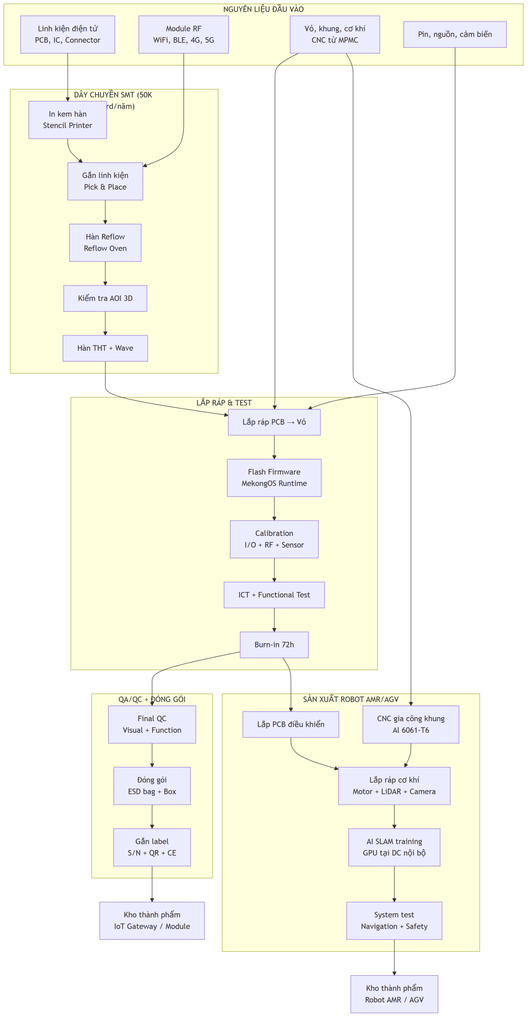

So do 3

### 2.2.11. Dây chuyền SMT — Chi tiết Thiết bị

| TT | Thiết bị | Hãng | SL | Đ/giá (K USD) | Tổng (K USD) | Chức năng |
| --- | --- | --- | --- | --- | --- | --- |
| 1 | Stencil Printer | DEK/MPM | 1 | 80 | 80 | In kem hàn lên PCB |
| 2 | Pick & Place (high-speed) | Yamaha/Juki | 1 | 250 | 250 | Gắn linh kiện SMD, 30.000 cph |
| 3 | Pick & Place (fine-pitch) | Yamaha/Juki | 1 | 180 | 180 | Gắn BGA, QFP, 0201 |
| 4 | Reflow Oven (10 zone) | Heller/BTU | 1 | 120 | 120 | Hàn reflow, profile Pb-free |
| 5 | AOI 3D | Koh Young/Mirtec | 1 | 150 | 150 | Kiểm tra tự động sau hàn |
| 6 | Wave Solder | ERSA/Pillarhouse | 1 | 60 | 60 | Hàn THT, selective solder |
| 7 | ICT Fixture + Tester | Keysight/SPEA | 1 | 80 | 80 | In-Circuit Test |
| 8 | Functional Tester | Custom Mekong | 2 | 30 | 60 | Test chức năng sản phẩm |
| 9 | Burn-in Chamber | Espec | 1 | 40 | 40 | Aging 72h, -20°C đến +70°C |
| 10 | Loader/Unloader + Conveyor | Nutek/Simplimatic | 1 | 30 | 30 | Tự động hóa dây chuyền |
|  | **Tổng SMT Line** |  |  |  | **1.050** |  |

## 2.3. Trụ cột 2 — Chế tạo Cơ khí Siêu Chính xác (CNC/MPMC)

### 2.3.1. Tổng quan Năng lực Sản xuất

Trung tâm Chế tạo Linh kiện Chính xác (Mekong Precision Manufacturing Center — MPMC) là xưởng CNC tại Nhà xưởng Sản xuất, chuyên gia công khung robot AMR/AGV nội bộ và linh kiện chính xác cho khách hàng FDI, đạt chuẩn ISO 9001:2015.

| Thông số | Giá trị | Ghi chú |
| --- | --- | --- |
| **Diện tích** | ~1.000 m² (khu CNC + QC Corner) | Tầng 1 Nhà xưởng |
| **Số máy CNC** | **10 máy** | 5×5-trục + 3×3-trục + 1×EDM + 1×Grinder |
| **Dung sai đạt được** | ≤ 5 micromet (5-trục) | [B] |
| **Độ bóng bề mặt** | Ra ≤ 0,4 micromet | [B] |
| **Vật liệu** | Nhôm 6061-T6, thép hợp kim, inox SUS304, titan, inconel, đồng |  |
| **Công suất** | 4.000-5.000 chi tiết/năm (ổn định) | [C] |
| **Chứng nhận** | ISO 9001:2015 (sẵn có). IATF/AS9100 là option Y10+ |  |
| **Nhân sự** | 15-20 người (2 ca) |  |

### 2.3.2. Danh mục Máy móc Chi tiết (10 máy)

| TT | Máy | Hãng | Loại | Đ/giá (K USD) | SL | Thành tiền (K USD) |
| --- | --- | --- | --- | --- | --- | --- |
| 1 | DMU 65 monoBLOCK | DMG MORI (Đức/Nhật) | 5-trục | 520 | 2 | 1.040 |
| 2 | DVF 5000 | Doosan (Hàn Quốc) | 5-trục | 385 | 3 | 1.155 |
| 3 | DNM 6700 | Doosan (Hàn Quốc) | 3-trục VMC | 150 | 3 | 450 |
| 4 | Wire EDM | Sodick/Mitsubishi | EDM | 180 | 1 | 180 |
| 5 | Surface Grinder CNC | Okamoto/Chevalier | Mài phẳng | 120 | 1 | 120 |
|  | **Tổng** |  |  |  | **10** | **2.945** |

**Thiết bị QA/QC:**

| TT | Thiết bị | Hãng | Đ/giá (K USD) | SL | Thành tiền (K USD) |
| --- | --- | --- | --- | --- | --- |
| 1 | Portable CMM — Absolute Arm 7325 | Hexagon (Thụy Điển) | 250 | 1 | 250 |
| 2 | Máy đo nhám SJ-410 | Mitutoyo (Nhật) | 8 | 1 | 8 |
| 3 | Máy đo độ cứng HV-120D | Shimadzu (Nhật) | 6 | 1 | 6 |
| 4 | Height Gauge QM-600 | Mitutoyo | 12 | 1 | 12 |
| 5 | Dụng cụ đo tay (panme, thước cặp) | Mitutoyo | 10 | Bộ | 10 |
|  | **Tổng QA/QC** |  |  |  | **286** |

**Phần mềm CAD/CAM:**

| Phần mềm | Hãng | License | Chi phí/năm (K USD) |
| --- | --- | --- | --- |
| Mastercam (Mill 3D + 5-Axis) | CNC Software | 10 | 100-120 |
| SolidWorks Standard (viewer) | Dassault | 3 | 12-18 |
| **Tổng** |  |  | **112-138** |

**Tổng CAPEX CNC (máy + QC + phần mềm + hoàn thiện lắp đặt + tooling):** ~3.800K USD [C].

### 2.3.3. Quy trình Gia công Tiêu biểu — ISO 9001:2015

1. **Nhận bản vẽ** từ khách hàng → 2. **Kiểm tra phôi** đầu vào (thước cặp, panme) → 3. **Lập trình CNC** trên Mastercam (5-trục/3-trục) → 4. **Gia công CNC** trên DMG MORI/Doosan → 5. **Kiểm tra QC** bằng Hexagon Arm (in-process) → 6. **Xử lý bề mặt** (EDM/mài/anodize nếu yêu cầu — xử lý tại chỗ với Wire EDM và Grinder) → 7. **Kiểm tra cuối** bằng Hexagon Arm + báo cáo đo → 8. **Đóng gói + Giao hàng**

**Thời gian chu kỳ (Thời gian dẫn):** - Chi tiết đơn giản (khung robot, bracket): 1-2 tuần - Chi tiết chính xác (encoder mount, jig): 2-3 tuần - Sản phẩm mới (NPI): 4-6 tuần (bao gồm thiết kế fixture + FAI)

### 2.3.4. Sản phẩm CNC theo Phân khúc

#### A. Khung Robot AMR/AGV (Nội bộ + Xuất khẩu)

| Sản phẩm | Vật liệu | Dung sai | SL/năm | Đơn giá (USD) |
| --- | --- | --- | --- | --- |
| Khung chính AMR (CNC 5 trục) | Al 6061-T6 | ≤ 5 µm | 500 | 400-700 |
| Khung AGV tải nặng | Thép S45C + Al | ≤ 10 µm | 200 | 600-1.000 |
| Bộ gá sensor (LiDAR mount) | Al 6061-T6 | ≤ 5 µm | 700 | 50-120 |

#### B. Linh kiện Chính xác cho FDI (Electronics/Semiconductor)

| Sản phẩm | Vật liệu | Dung sai | SL/năm | Đơn giá (USD) |
| --- | --- | --- | --- | --- |
| Encoder Bracket | Al 6061 / Inox | ≤ 5 µm | 400 | 80-200 |
| Motor Mount | Al 6061-T6 | ≤ 5 µm | 300 | 100-250 |
| Khớp xoay (Rotary Joint) | SUS304, đồng | ≤ 5 µm | 200 | 150-400 |

#### C. Jig/Fixture cho SMT và Lắp ráp

| Sản phẩm | Vật liệu | Dung sai | SL/năm | Đơn giá (USD) |
| --- | --- | --- | --- | --- |
| Pallet SMT | Al 6061-T6 | ≤ 10 µm | 300 | 200-500 |
| Fixture kiểm tra EOL | Al + nhựa kỹ thuật | ≤ 20 µm | 200 | 300-800 |
| Fixture lắp ráp | Al 6061 | ≤ 15 µm | 200 | 150-400 |

### 2.3.5. Công suất và Doanh thu CNC (10 máy)

| Chỉ tiêu | Y4 (khởi động) | Y6 | Y8 | Y10 (ổn định) | Y12+ |
| --- | --- | --- | --- | --- | --- |
| **Số máy hoạt động** | 6 | 8 | 10 | 10 | 10 |
| **Ca sản xuất** | 1 ca | 1,5 ca | 2 ca | 2 ca | 2 ca |
| **Utilization target** | 40% | 55% | 70% | 80% | 85% |
| **OEE** | 50% | 60% | 70% | 75% | 78% |
| **Sản lượng (chi tiết/năm)** | ~1.500 | ~2.500 | ~3.500 | ~4.500 | ~5.000 |
| **Machine Hour Rate (USD)** | 45-85 | 48-88 | 50-90 | 55-95 | 55-95 |
| **Revenue target (M USD)** | 0,50 | 1,50 | 2,80 | 3,30 | 3,50 |

> OEE Y4 = 50% là thực tế cho nhà máy mới. Target OEE Y12 = 78% đòi hỏi chương trình TPM (Total Productive Maintenance) và đào tạo operator liên tục [B][C].

**Doanh thu CNC 5 năm — 3 Kịch bản (từ Y4):**

| Năm | Conservative (M USD) | Base Case (M USD) | Optimistic (M USD) |
| --- | --- | --- | --- |
| Y4 | 0,30 | 0,50 | 0,70 |
| Y5 | 0,80 | 1,00 | 1,30 |
| Y6 | 1,20 | 1,50 | 1,80 |
| Y7 | 1,60 | 2,00 | 2,40 |
| Y8 | 2,00 | 2,80 | 3,20 |
| **Tổng 5 năm** | **5,90** | **7,80** | **9,40** |

## 2.4. Datacenter Nội bộ

### 2.4.1. Chức năng và Quy mô

DC nội bộ phục vụ toàn bộ nhu cầu CNTT của Mekong Technology — **KHÔNG kinh doanh dịch vụ colocation hay cloud thương mại**, do đó không cần Giấy phép Viễn thông và không thuộc phạm vi điều chỉnh của Luật Viễn thông 2023.

| Thông số | Giá trị | Ghi chú |
| --- | --- | --- |
| **Diện tích** | **200 m²** (T2) | Nhà xưởng SX — Tầng 2 |
| **Số rack** | 5-8 rack 42U | [A] |
| **Công suất điện IT** | 30-50 kW | [A] |
| **Cooling** | Precision AC N+1, DX |  |
| **UPS** | 1× 80 kVA, Li-ion 15 phút |  |
| **Generator** | Dùng chung máy phát nhà xưởng |  |
| **PUE mục tiêu** | < 1,50 | [A] |
| **Thời gian hoạt động mục tiêu** | 99,9% (Tier I+) | Đủ cho nội bộ |
| **CAPEX** | **2,20M USD (10,0% tổng)** | [C] |
| **OPEX/năm** | 0,40M USD | [C] |

### 2.4.2. Ứng dụng Chính

[output not shown]

> DC nội bộ đủ công suất phục vụ 2 trụ cột sản xuất và MekongOS SaaS. Khi MekongOS scaling vượt 2.000 subscribers, có thể thuê thêm cloud public (AWS/GCP) như hybrid option mà không cần mở rộng DC vật lý [A].

## 2.5. Hệ sinh thái Tích hợp 2 Trụ cột

### 2.5.1. Ma trận Liên kết Giá trị

| Từ → Đến | IoT/BMS/Robot (BU1) | CNC/MPMC (BU2) | DC Nội bộ |
| --- | --- | --- | --- |
| **BU1 — IoT/Robot** | — | Bản vẽ CNC cho khung Robot | Dữ liệu IoT → Cloud Analytics |
| **BU2 — CNC** | Khung, vỏ, trục robot AMR | — | IoT giám sát hiệu suất CNC |
| **DC Nội bộ** | GPU cho AI SLAM training | Dữ liệu OEE cho tối ưu CNC | — |

### 2.5.2. Lượng hóa Giá trị Cộng hưởng

| Liên kết | Giá trị/năm (USD) | Phương pháp | Nhãn |
| --- | --- | --- | --- |
| CNC chế tạo khung Robot (thay vì thuê ngoài) | 150.000-200.000 | Tiết kiệm 15-20% COGS khung | [A] |
| DC nội bộ cung cấp GPU cho AI SLAM | 100.000-200.000 | So sánh với thuê AWS | [A] |
| MekongOS lưu trữ trên DC nội bộ | 80.000-150.000 | Chênh lệch cloud cost | [A] |
| Cross-sell FDI (CNC → IoT) | 200.000-500.000 | Revenue uplift KH chung | [A] |
| IoT giám sát CNC (tăng utilization) | 50.000-100.000 | 5-10% OEE improvement | [A] |
| **Tổng Synergy Value/năm** | **580.000-1.150.000** |  |  |
| **NPV Synergy 10 năm (WACC 12%)** | **~2.000.000** |  | [C] |

> Tổng giá trị cộng hưởng đạt ~2,00M USD NPV 10 năm, đủ lớn để biện minh cho mô hình tích hợp 2 trụ cột [C].

## 2.6. Lộ trình Trưởng thành Công nghệ

| Giai đoạn | Thời gian | Sản phẩm chính | Chứng nhận |
| --- | --- | --- | --- |
| **Nền tảng** | Y0-Y4 | MK-200 (TRL 9), CNC ISO 9001, MekongOS v1.0 | CE, FCC, ISO 9001 |
| **Tăng trưởng** | Y4-Y8 | AMR-500/1000, AGV, CNC mở rộng 10 máy, MekongOS v2.0 (AI) | BACnet BTL |
| **Trưởng thành** | Y8-Y12 | MK-DDC, MK-EIO sản xuất hàng loạt, MekongBMS v1.0, MekongSCADA | IATF option |
| **Dẫn đầu** | Y12+ | Xuất khẩu ASEAN, Digital Twin, MekongOS v3.0, CNC Hybrid | AS9100 option |

## 2.7. Hoạt động Nghiên cứu và Phát triển (R&D)

### 2.7.1. Ngân sách R&D

[output not shown]

### 2.7.2. Phòng Thí nghiệm R&D (4 Lab)

| TT | Phòng Lab | Diện tích | Chức năng | Đầu tư (K USD) |
| --- | --- | --- | --- | --- |
| 1 | Lab Phần cứng IoT | 150 m² | Thiết kế PCB, prototyping, EMC pre-compliance | 250 |
| 2 | Lab AI & Robotics | 200 m² | AI SLAM, Computer Vision, ROS2 | 300 |
| 3 | Lab Vật liệu CNC | 80 m² | Phân tích kim loại, metallography | 150 |
| 4 | Lab Cloud & Cybersecurity | 70 m² | Dev/Test MekongOS, Pen testing | 100 |
|  | **Tổng** | **500 m²** |  | **800** |

> Lab bố trí tại Tầng 2 Tòa VP. Không có Lab Đo lường riêng — QC Corner tích hợp trong khu CNC [C].

### 2.7.3. Lộ trình R&D Sản phẩm BMS/SCADA

| TT | Sản phẩm | Thời gian | R&D Cost (K USD) | Nhân sự | Nhãn |
| --- | --- | --- | --- | --- | --- |
| 1 | MK-EIO-DI16 + DO16 | Q1-Q3/Y6 | 80 | 3 | [A] |
| 2 | MK-EIO-AI8 + AO4 + UI8 | Q2-Q4/Y6 | 100 | 4 | [A] |
| 3 | MK-DDC-24 | Q1/Y6-Q2/Y7 | 150 | 5 | [A] |
| 4 | MK-DDC-64 | Q3/Y6-Q4/Y7 | 120 | 4 | [A] |
| 5 | MK-GW-BAC + MOD | Q2-Q4/Y6 | 60 | 2 | [A] |
| 6 | MK-GW-KNX + DALI | Q1-Q3/Y7 | 80 | 3 | [A] |
| 7 | MekongBMS v1.0 | Q1/Y6-Q4/Y7 | 300 | 8-12 | [A] |
| 8 | MekongET v1.0 | Q3/Y6-Q2/Y7 | 100 | 3 | [A] |
| 9 | Chứng nhận CE + BACnet BTL | Q1-Q4/Y7 | 150 | 2 | [A] |
| 10 | MekongSCADA v1.0 | Q1-Q4/Y8 | 250 | 6 | [A] |
|  | **Tổng R&D BMS/SCADA** | **3 năm (Y6-Y8)** | **1.390** | **Peak: 25** |  |

> 1.390K USD chiếm ~23% tổng R&D 10 năm (6.000K). Hợp lý vì tái sử dụng 60-70% nền tảng MK-200 và BACnet open-source stack [A].

### 2.7.4. Sở hữu Trí tuệ

| Loại | Mục tiêu 5 năm | Mục tiêu 10 năm |
| --- | --- | --- |
| Bằng sáng chế | 6-8 | 15-20 |
| Nhãn hiệu | 4 | 6 |
| Bản quyền phần mềm | 3 | 5 |
| Bí mật kinh doanh | Liên tục | — |

### 2.7.5. Hợp tác Chuyển giao Công nghệ

| Đối tác | Quốc gia | Lĩnh vực | Nội dung |
| --- | --- | --- | --- |
| DMG MORI Academy | Nhật/Đức | CNC | Đào tạo vận hành 5 trục, tối ưu toolpath |
| Hexagon Manufacturing Intelligence | Thụy Điển | QA/QC | CMM programming, GD&T |
| NVIDIA Deep Learning Institute | Mỹ | AI/GPU | Certified AI Developer program |
| Đại học Bách Khoa TP.HCM | Việt Nam | R&D | Nghiên cứu Robot + AI |
| Đại học Quốc gia TP.HCM | Việt Nam | R&D | Đào tạo kỹ sư IoT/Embedded |

### 2.7.6. Kinh tế Đơn vị Sản phẩm (Unit Economics) — Nhóm chủ lực

Để bảo đảm cơ sở tài chính của từng dòng sản phẩm là khả thi, Mekong chuẩn hóa mô hình tính **Unit Economics** theo 5 lớp: BOM vật tư trực tiếp, gia công/lắp ráp, kiểm thử, overhead sản xuất và chi phí bảo hành dự phòng. Cách tiếp cận này phù hợp thực hành quản trị sản xuất điện tử theo **IPC-A-610**, **ISO 9001:2015** và chuẩn ngành EMS/ODM khu vực ASEAN [B].

#### A. BOM và biên gộp ước tính — MK-200

| Cấu phần | Giá trị (USD/bộ) | Tỷ trọng | Ghi chú |
| --- | --- | --- | --- |
| SoC / CPU NXP i.MX8M | 42 | 22,1% | Giá theo lot trung bình 1.000-3.000 pcs [B] |
| RAM + eMMC | 18 | 9,5% | LPDDR4 + eMMC industrial grade [B] |
| PCB 6 lớp + SMT assembly | 28 | 14,7% | Bao gồm stencil, AOI, ICT [A] |
| Module kết nối (WiFi/BLE/4G option) | 20 | 10,5% | Cấu hình base + option [A] |
| Nguồn / bảo vệ / EMC components | 16 | 8,4% | TVS, DC-DC, filter [A] |
| Vỏ nhôm / DIN rail / phụ kiện | 14 | 7,4% | Gia công vỏ theo chuẩn công nghiệp [A] |
| Cổng I/O, connector, terminal block | 12 | 6,3% | Phoenix/Weidmuller tương đương [B] |
| Flash firmware + calibration + burn-in | 11 | 5,8% | 72 giờ burn-in + test chức năng [A] |
| QA/QC + đóng gói | 9 | 4,7% | ICT + final QC + packaging [A] |
| Dự phòng bảo hành 12 tháng | 8 | 4,2% | Tỷ lệ warranty reserve ~2,0% ASP [A] |
| Overhead sản xuất phân bổ | 12 | 6,3% | Điện, gián tiếp, khấu hao line [A] |
| **Tổng COGS ước tính** | **190** | **100%** | Nhất quán với giá vốn [C] |

[output not shown]

#### B. BOM và biên gộp ước tính — MK-300

| Cấu phần | Giá trị (USD/bộ) | Ghi chú |
| --- | --- | --- |
| Jetson Orin Nano module | 190 | Thành phần chi phí lớn nhất [B] |
| RAM + eMMC/NVMe | 55 | Cấu hình AI edge |
| PCB high-speed 8 lớp | 42 | Yêu cầu impedance control [A] |
| 5G + WiFi 6E module | 48 | Option thị trường FDI [A] |
| Thermal / heatsink / enclosure | 32 | Tản nhiệt chủ động |
| Cổng công nghiệp + nguồn | 26 | 6× RS485 + 2× GbE |
| Assembly + AI validation | 22 | Chuẩn ngành image/model test [A] |
| QA + burn-in + packaging | 18 | 48 giờ burn-in |
| Overhead + bảo hành reserve | 27 |  |
| **Tổng COGS ước tính** | **460** |  |

| Chỉ tiêu | Giá trị |
| --- | --- |
| ASP trung bình | 760 USD [C] |
| COGS | 460 USD [A] |
| Biên gộp | ~39-42% |
| Vai trò chiến lược | Dòng flagship cho Smart Factory / AI Edge |

#### C. Kinh tế đơn vị — Robot AMR-500

| Cấu phần | Giá trị (USD/bộ) | Tỷ trọng |
| --- | --- | --- |
| Khung cơ khí + CNC machining nội bộ | 2.800 | 26% |
| Motor, driver, gearbox | 1.650 | 15% |
| LiDAR safety + camera + IMU | 2.100 | 20% |
| PCB điều khiển + wiring harness | 1.150 | 11% |
| Pin LiFePO4 + BMS | 1.250 | 12% |
| Lắp ráp + calibration + test | 820 | 8% |
| Overhead + warranty reserve | 980 | 8% |
| **Tổng COGS ước tính** | **10.750** | **100%** |

| Chỉ tiêu | Giá trị |
| --- | --- |
| ASP trung bình | 20.500 USD [C] |
| Gross profit / bộ | ~9.750 USD |
| Biên gộp | ~47,6% |
| Giá trị synergy BU2 | ~15-20% COGS khung tiết kiệm so với thuê ngoài [A] |

> **Nhận xét quản trị:** Dòng phần cứng có biên gộp 40-50% chỉ bền vững khi Mekong kiểm soát được 3 yếu tố: (1) BOM chuẩn hóa theo nền tảng dùng chung, (2) yield SMT/CNC cao, và (3) doanh thu phần mềm/dịch vụ đi kèm. Đây cũng là lý do P3 đặt trọng tâm vào mix doanh thu SaaS + SI + aftersales thay vì chỉ bán thiết bị [A][C].

### 2.7.7. Mô hình OEM/ODM và Quy trình Thương mại hóa Sản phẩm

Ngoài bán sản phẩm chuẩn mang thương hiệu Mekong, BU1 triển khai thêm mô hình **OEM/ODM điện tử công nghiệp** cho khách hàng FDI và SI trong nước. Đây là mảng doanh thu 1,10M USD/năm ổn định [C], đồng thời giúp tối ưu công suất SMT line và giảm rủi ro phụ thuộc vào 1-2 SKU chủ lực.

#### A. Phạm vi dịch vụ OEM/ODM

| Mô hình | Mekong cung cấp | Tài sản trí tuệ | Biên gộp mục tiêu | Thời gian thời gian dẫn |
| --- | --- | --- | --- | --- |
| **OEM** | Sản xuất theo thiết kế khách hàng | IP thuộc khách hàng | 18-25% | 6-10 tuần |
| **ODM-lite** | Tùy biến từ nền tảng MK-200/MK-DDC | Shared IP / licensing | 28-35% | 8-12 tuần |
| **ODM-full** | Thiết kế phần cứng + firmware + enclosure | IP Mekong, KH license độc quyền có điều kiện | 35-45% | 12-20 tuần |
| **JDM / Co-development** | Đồng phát triển với FDI / SI | Đồng sở hữu / theo mốc tiến độ | 30-40% | Theo dự án |

#### B. Quy trình Stage-Gate cho dự án OEM/ODM

| Giai đoạn | Mục tiêu | Deliverable | Tiêu chí qua cổng |
| --- | --- | --- | --- |
| Gate 0 — Lead Qualification | Sàng lọc cơ hội | RFQ, NDA, sơ bộ nhu cầu | GM mục tiêu ≥ 20%, phù hợp năng lực |
| Gate 1 — Feasibility | Xác minh khả thi kỹ thuật | BOM sơ bộ, risk register, ROM cost | Không có rủi ro công nghệ “đỏ” |
| Gate 2 — EVT | Thiết kế và nguyên mẫu kỹ thuật | EVT prototype, test report | Function pass ≥ 90% |
| Gate 3 — DVT | Xác minh thiết kế | DVT sample, EMC pre-check, pilot line | Yield pilot ≥ 92% |
| Gate 4 — PVT | Sẵn sàng sản xuất hàng loạt | PVT lot, WI, QC plan, PPAP-lite | Yield ≥ 95%, Cpk mục tiêu đạt |
| Gate 5 — MP | Mass production + hậu mãi | SLA, warranty process, ECO/ECN control | OTIF ≥ 95% |

#### C. Mẫu cấu trúc hợp đồng OEM/ODM

| Điều khoản | Nguyên tắc |
| --- | --- |
| NRE (Non-Recurring Engineering) | Thu upfront 30-50% để giảm áp lực dòng tiền |
| MOQ | Thiết lập theo BOM critical components |
| Forecast lock | Rolling forecast 3 tháng |
| Obsolescence | KH chịu chi phí last-time-buy nếu ngừng linh kiện |
| Warranty | 12 tháng tiêu chuẩn, mở rộng 24 tháng có phụ phí |
| ECO/ECN | Mọi thay đổi phải có phê duyệt hai bên |
| IP/Source code escrow | Chỉ áp dụng khi KH trả phí license / exclusivity |

> **Logic chiến lược:** OEM/ODM giúp Mekong “điền đầy” công suất sản xuất giai đoạn Y4-Y7, trong khi dòng thương hiệu riêng tạo biên gộp cao hơn từ Y7 trở đi. Mô hình này phổ biến ở các doanh nghiệp EMS/ODM như Advantech, Avalue, Portwell tại châu Á [B].

### 2.7.8. Hệ thống QA/QC, Chứng nhận và Đảm bảo Chất lượng

Để bảo đảm sản phẩm đủ điều kiện vào chuỗi cung ứng FDI, Mekong triển khai hệ thống QA/QC hai lớp: **quality by design** ở giai đoạn R&D và **quality in production** ở giai đoạn sản xuất. Phương pháp này bám theo **ISO 9001:2015**, **IPC-A-610**, **IEC 61131-3**, **ISO 13849**, và lộ trình nâng cấp lên các chứng nhận chuyên ngành khi doanh thu đủ lớn [B].

#### A. Khung QA/QC cho điện tử và robot

| Lớp kiểm soát | Nội dung | KPI mục tiêu |
| --- | --- | --- |
| Incoming Quality Control (IQC) | Kiểm tra linh kiện AQL, trace lot code, chống ESD | Lot reject < 1,5% |
| In-Process Quality Control (IPQC) | AOI, ICT, torque control, checklist lắp ráp | First pass yield ≥ 95% |
| Outgoing Quality Control (OQC) | Functional test, burn-in, visual audit, packaging | OQC defect < 0,8% |
| Reliability / HALT-lite | Nhiệt, rung, power cycling, communication stress | No critical failure |
| Field Quality | RMA analysis, 8D, CAPA | Warranty return < 1,5% doanh số |

#### B. Khung QA/QC cho CNC/MPMC

| Công đoạn | Thiết bị / phương pháp | KPI |
| --- | --- | --- |
| Kiểm phôi đầu vào | Material cert + hardness + visual | 100% lô quan trọng |
| First Article Inspection | Hexagon Arm + dimension sheet | 100% part mới |
| In-process inspection | Check gauge / tool wear / offset | Scrap < 3% |
| Final inspection | CMM report / surface roughness / packing audit | PPM < 2.000 giai đoạn đầu |
| SPC / Cpk | Theo đặc tính critical-to-quality | Cpk ≥ 1,33 với part ổn định |

#### C. Lộ trình chứng nhận và chuẩn hóa

| Giai đoạn | Chứng nhận / chuẩn | Phạm vi | Mục tiêu thời gian |
| --- | --- | --- | --- |
| Y3-Y4 | ISO 9001:2015 vận hành đầy đủ | Toàn nhà máy | Bắt buộc |
| Y4-Y5 | CE / FCC pre-compliance | IoT Gateway / Controller | Bán hàng xuất khẩu ASEAN |
| Y6-Y7 | BACnet BTL / KNX interoperability test | MK-DDC, MK-GW, MekongBMS | Thâm nhập BMS chuyên nghiệp |
| Y6-Y8 | IPC-A-610 / IPC-7711 internal certification | SMT / sửa chữa board | Nâng yield line |
| Y7-Y9 | ISO 27001 scope software/DC nội bộ (nếu cần khách hàng) | MekongOS / DevOps | Theo yêu cầu deal lớn |
| Y8-Y10 | IATF 16949 readiness | CNC cung ứng ô tô | Chỉ kích hoạt khi volume phù hợp |
| Y10+ | AS9100 option | Aerospace CNC | Chỉ triển khai nếu có anchor customer |

> **Nguyên tắc:** Không “ôm” quá nhiều chứng nhận sớm gây tăng OPEX vô ích. Chỉ kích hoạt IATF/AS9100 khi có doanh thu neo (anchor revenue) đủ hấp thụ chi phí duy trì chứng nhận [A].

### 2.7.9. Quản trị Vòng đời Sản phẩm (PLM), IP và Cybersecurity by Design

Để tránh rủi ro lỗi phiên bản, obsolescence linh kiện và tranh chấp IP, Mekong áp dụng mô hình quản trị vòng đời sản phẩm từ R&D đến end-of-life.

#### A. Cấu trúc PLM nội bộ

| Thành phần | Công cụ / cách làm | Mục tiêu |
| --- | --- | --- |
| BOM Master | BOM version-controlled, approved vendor list (AVL) | Không sai lệch BOM khi mass production |
| Firmware / Software Repo | Git + branch policy + release tagging | Truy xuất source code 100% |
| ECO / ECN | Change board liên phòng ban | Kiểm soát thay đổi thiết kế |
| Test Report Archive | Lưu DVT/PVT/field failure theo serial | Phục vụ CAPA / audit |
| Serial Traceability | Tem serial + QR + batch code | Truy xuất nguồn gốc đến linh kiện chính |
| End-of-Life Planning | Last-time-buy và redesign plan | Giảm rủi ro chip EOL |

#### B. Danh mục IP ưu tiên bảo hộ

| Nhóm IP | Hình thức bảo hộ | Ví dụ đối tượng |
| --- | --- | --- |
| Firmware điều khiển | Bản quyền phần mềm | Protocol stack, OTA logic, AI inference engine |
| Thiết kế phần cứng | Kiểu dáng / bí mật kỹ thuật | Gateway industrial enclosure, board layout |
| Thuật toán | Bí mật kinh doanh / sáng chế có chọn lọc | SLAM tuning, energy optimization |
| Nền tảng phần mềm | Nhãn hiệu + bản quyền | MekongOS, MekongBMS, MekongET |
| Jig/fixture đặc thù | Bí mật kỹ thuật | CNC fixture, AMR test rig |

#### C. Cybersecurity by Design cho sản phẩm IoT

| Lớp bảo vệ | Cơ chế |
| --- | --- |
| Secure boot | Xác minh firmware trước khi khởi động |
| Device identity | X.509 certificate / TPM 2.0 |
| OTA signing | Firmware update ký số |
| Role-based access | Phân quyền người dùng / kỹ thuật viên |
| Logging + audit trail | Theo dõi truy cập và thay đổi cấu hình |
| Vulnerability response | SLA vá lỗi theo mức độ nghiêm trọng |

> Cách tiếp cận này phù hợp xu hướng **secure-by-design** cho thiết bị công nghiệp và giúp Mekong nâng vị thế khi làm việc với khách hàng FDI có yêu cầu cao về OT security, đặc biệt trong nhà máy thông minh và hạ tầng tòa nhà [B — IEC 62443 guidance, NIST IoT baseline].

### 2.7.10. Lộ trình Sản phẩm và Danh mục Ưu tiên 2026-2035

| Giai đoạn | SKU / nền tảng ưu tiên | Mục tiêu thương mại | Chỉ số thành công |
| --- | --- | --- | --- |
| 2026-2027 | MK-200, OEM Gateway, Jig/Fixture CNC | Chốt 5-8 khách hàng đầu tiên | Doanh thu Y4 ≥ 1,00M [C] |
| 2027-2028 | MK-300, AMR-500, tooling CNC precision | Mở rộng sang Smart Factory FDI | 20 khách hàng hoạt động |
| 2028-2029 | MK-EIO, MK-DDC-24, MekongET, AGV-500 | Hoàn thiện hệ sinh thái BMS/SCADA lõi | 500 controller/module shipped |
| 2029-2031 | MK-DDC-64, MekongBMS v1.0, AMR-1000 | Tăng tỷ trọng software + service | SaaS ARR > 0,50M |
| 2031-2033 | MekongSCADA, Fleet Manager, predictive quality | Bán giải pháp tích hợp cấp nhà máy | 3-5 dự án quy mô lớn |
| 2033-2035 | Digital Twin, AI quality, cobot-ready nền tảng | Vươn ra ASEAN / OEM regional | Xuất khẩu ≥ 15% DT |

#### Danh mục ưu tiên theo ma trận “Doanh thu × Khả năng thắng”

| Ưu tiên | Sản phẩm / nhóm | Lý do |
| --- | --- | --- |
| **P1** | MK-200 / OEM Gateway | Time-to-market nhanh, reuse nền tảng cao |
| **P1** | Jig/Fixture + CNC FDI parts | Doanh thu sớm, ít phụ thuộc chứng nhận phức tạp |
| **P2** | AMR-500 | Giá trị tích hợp 2 BU rõ nhất |
| **P2** | MK-EIO / MK-DDC-24 | Mở cửa thị trường BMS trung cấp |
| **P3** | MK-300 | Flagship hình ảnh thương hiệu, nhưng cần sales kỹ thuật mạnh |
| **P3** | AMR-1000 / MekongSCADA | Nên scale sau khi nền tảng vận hành ổn định |

> **Kết luận Phần II:** Hệ sinh thái 21 sản phẩm IoT/BMS/Robot (BU1) + 10 máy CNC (BU2) + DC nội bộ tạo nền tảng vững chắc cho doanh thu ổn định 12,00M USD/năm. Mô hình 2 trụ cột tập trung, giảm rủi ro phân tán nguồn lực. Synergy nội bộ ~2,00M USD NPV bổ sung giá trị tích hợp [C].

## 2.8. Sơ đồ Quy trình Sản xuất Tổng thể — BU2 (CNC/MPMC)

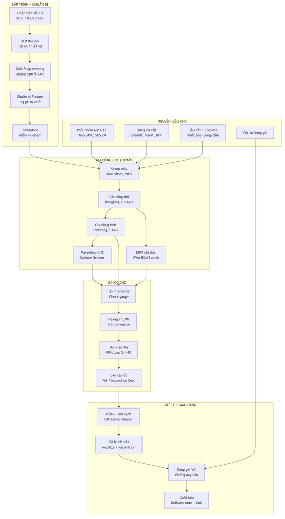

So do 4

> Quy trình CNC áp dụng ISO 9001:2015 với kiểm soát chặt: 100% FAI cho part mới, SPC cho part lặp lại. Thời gian dẫn trung bình 2-3 tuần (NPI 4-6 tuần). EDM và Grinder phục vụ part yêu cầu xử lý bề mặt đặc biệt, nâng cao năng lực gia công chính xác [C].

## 2.9. Bảng Tổng hợp Sản phẩm theo Format Mẫu 1.4 (QĐ 38/2020)

Bảng dưới đây tổng hợp toàn bộ 14 nhóm sản phẩm/dịch vụ Mekong Technology theo format yêu cầu của Mẫu 1.4 (Phụ lục I, NĐ 31/2021/NĐ-CP), bao gồm mapping với Danh mục Sản phẩm Công nghệ cao (QĐ 38/2020/QĐ-TTg) và Danh mục Hoạt động CNC (QĐ 2117/QĐ-TTg):

[output not shown]

### 2.9.1. Đối chiếu Tiêu chí Doanh nghiệp CNC theo NĐ 76/2018/NĐ-CP

| TT | Tiêu chí NĐ 76/2018 | Ngưỡng tối thiểu | Giá trị Mekong | Đạt/Chưa | Cơ sở |
| --- | --- | --- | --- | --- | --- |
| 1 | Tỷ lệ chi phí R&D / Doanh thu | ≥ 0,5% | ~8% (6,00M/10Y ÷ ~75M/10Y) | Vượt xa | §2.7.1 [C] |
| 2 | Tỷ lệ nhân lực R&D / Tổng LĐ | ≥ 5% | ~20-25% (25-30 R&D / 115) | Vượt xa | §7.2 [C] |
| 3 | DT sản phẩm CNC / Tổng DT | ≥ 70% | ~100% (toàn bộ SP thuộc QĐ 38) | Vượt xa | Bảng 2.9 [C] |
| 4 | VA / Doanh thu | ≥ 30% | ~46% | Vượt xa | Bảng 2.9 [C] |

> Mekong Technology đáp ứng **cả 4 tiêu chí** doanh nghiệp công nghệ cao theo NĐ 76/2018, đủ điều kiện hưởng ưu đãi thuế TNDN 10% trong 15 năm, miễn TNDN 4 năm, giảm 50% trong 9 năm tiếp theo [C].

## 2.10. Bảng Nguyên Vật liệu Tổng hợp Hàng năm (Ổn định Y12+)

### 2.10.1. BOM Tổng hợp theo Nhóm Nguyên liệu

| TT | Nhóm Nguyên liệu | ĐVT | SL/năm | Đ/giá TB (USD) | Thành tiền (K USD/năm) | Nguồn cung chính | Nhãn |
| --- | --- | --- | --- | --- | --- | --- | --- |
| 1 | IC / SoC (NXP, NVIDIA, STM32) | pcs | 25.000 | 25-190 | 850 | DigiKey, Mouser, Arrow (Mỹ/EU) | [B] |
| 2 | RAM / Flash / eMMC / NVMe | pcs | 25.000 | 8-55 | 380 | Samsung, Micron (Hàn/Mỹ) | [B] |
| 3 | PCB (4-12 lớp) + SMT assembly | board | 50.000 | 12-42 | 620 | NPC VN, VinCircuit, Elcom (VN) | [B] |
| 4 | Module RF (WiFi/BLE/4G/5G/LoRa) | pcs | 20.000 | 8-48 | 320 | Quectel (CN), u-blox (CH) | [B] |
| 5 | Connector, terminal, nguồn | pcs | 80.000 | 1-16 | 280 | Phoenix, Weidmuller, Meanwell | [B] |
| 6 | Vỏ hộp nhôm / nhựa công nghiệp | pcs | 15.000 | 8-32 | 200 | CNC nội bộ MPMC + thuê ngoài VN | [B] |
| 7 | Cảm biến, LiDAR, Camera | pcs | 1.500 | 50-1.200 | 350 | SICK (Đức), Velodyne, Intel RS | [B] |
| 8 | Motor servo / bánh xe Robot | bộ | 600 | 200-650 | 180 | Nabtesco (JP), Maxon (CH), TQ | [B] |
| 9 | Pin LiFePO4 / BMS module | bộ | 300 | 800-1.250 | 280 | CATL (CN), EVE (CN) | [B] |
| 10 | Phôi nhôm 6061-T6 | kg | 30.000 | 4,5-5,5 | 150 | Alcoa, Novelis, Nanshan (CN/VN) | [B] |
| 11 | Phôi thép S45C / SUS304 / Inox | kg | 15.000 | 3,0-8,0 | 90 | Nippon Steel, POSCO, Hoà Phát | [B] |
| 12 | Dụng cụ cắt CNC (endmill, insert) | pcs | 3.000 | 15-80 | 120 | Sandvik, Kennametal, Mitsubishi | [B] |
| 13 | Dầu cắt / coolant / vật tư tiêu hao CNC | lít/kg | 5.000 | 5-20 | 50 | Blaser, Castrol, nội địa VN | [B] |
| 14 | Vật tư đóng gói, ESD, nhãn | set | 40.000 | 1-5 | 80 | Nội địa VN | [B] |
|  | **TỔNG COGS NGUYÊN VẬT LIỆU** |  |  |  | **3.950** |  |  |

> Tổng chi phí NVL: ~3,95M USD/năm tại ổn định (33% doanh thu 12,00M) — nhất quán với dòng COGS 3,60M ước tính tại P5 (sai lệch ~10% do P5 không tính tooling tiêu hao) [C].

### 2.10.2. Phân tích Nguồn cung theo Xuất xứ

| Xuất xứ | Tỷ trọng giá trị | Nhóm chính | Rủi ro |
| --- | --- | --- | --- |
| Mỹ / EU | ~35% | IC, module cao cấp, connector, LiDAR | Biến động chip thời gian dẫn |
| Nhật / Hàn | ~20% | RAM, motor servo, dụng cụ cắt, đo lường | Ổn định, giá cao |
| Trung Quốc | ~25% | Pin, module RF phổ thông, phôi nhôm | Giá cạnh tranh, cần QC chặt |
| Việt Nam | ~15% | PCB, vỏ hộp, đóng gói, phôi thép | Gần nguồn, localization ưu tiên |
| Khác (Thụy Sĩ, Đài Loan) | ~5% | Motor cao cấp, dụng cụ cắt đặc biệt | Ổn định |

### 2.10.3. Kế hoạch Nội địa hóa (Localization Lộ trình)

| Giai đoạn | Tỷ lệ NVL nội địa | Hành động chính |
| --- | --- | --- |
| Y4-Y5 | 15-20% | PCB từ NPC VN / VinCircuit, phôi thép Hoà Phát, đóng gói nội địa |
| Y6-Y8 | 25-35% | Vỏ hộp CNC nội bộ, connector tương đương nội địa, module RF Trung Quốc qua VN |
| Y8-Y10 | 35-45% | Hợp tác phát triển PCB cao tầng tại VN, nội địa hóa một số cảm biến |
| Y10+ | 45-55% | Mục tiêu Chính phủ: nâng tỷ lệ nội địa hóa ngành điện tử [A] |

> Chiến lược: Ưu tiên nội địa hóa các thành phần có giá trị thấp–trung bình (PCB, vỏ, phôi, đóng gói) trước. Các IC/chip cao cấp (NXP, NVIDIA, STM32) duy trì nhập khẩu do chưa có nguồn cung nội địa. Mekong cam kết phối hợp với BQL KCNC phát triển chuỗi cung ứng nội bộ Khu Công nghệ cao [B].

## 2.11. Phân rã Chi phí R&D theo 5 Nhóm (Format Mẫu 1.4)

Theo yêu cầu giải trình R&D chi tiết của BQL KCNC (Mẫu 1.4, Mục II.4e), toàn bộ chi phí R&D 6,00M USD trong 10 năm (Y4-Y13) được phân rã thành 5 nhóm chi phí:

### 2.11.1. Bảng Phân rã R&D theo Nhóm Chi phí

| TT | Nhóm Chi phí R&D | Tổng 10 năm (K USD) | Tỷ trọng | Mô tả |
| --- | --- | --- | --- | --- |
| 1 | **Nhân công R&D** | 3.000 | 50,0% | Lương kỹ sư R&D (25-30 người), phụ cấp, BHXH, thưởng IP |
| 2 | **Nguyên vật liệu R&D** | 600 | 10,0% | PCB mẫu, linh kiện prototype, phôi CNC thử nghiệm, vật tư lab |
| 3 | **Khấu hao thiết bị R&D** | 800 | 13,3% | Lab equipment (4 lab × 800K), oscilloscopes, power supply, CMM R&D |
| 4 | **Chi phí dịch vụ R&D** | 1.200 | 20,0% | Đào tạo chuyên gia, hợp tác ĐH (BK, ĐHQG), chứng nhận (CE, BTL), license PM |
| 5 | **Chi phí khác** | 400 | 6,7% | Đi lại triển lãm, hội thảo quốc tế, thuê chuyên gia nước ngoài ngắn hạn |
|  | **TỔNG** | **6.000** | **100%** | Nhất quán với §2.7.1 [C] |

### 2.11.2. Phân bổ R&D theo Năm

[output not shown]

> Nhân công chiếm tỷ trọng lớn nhất (~50%) — phù hợp đặc thù R&D phần mềm/firmware/AI chiếm 60% khối lượng nghiên cứu. Dịch vụ R&D (~20%) bao gồm đào tạo, chứng nhận và hợp tác ĐH — khoản chi này giảm dần khi đội ngũ trưởng thành [C].

### 2.11.3. Tỷ lệ R&D/VA (NĐ 76/2018)

| Chỉ tiêu | Y4 | Y6 | Y8 | Y10 | Y12+ |
| --- | --- | --- | --- | --- | --- |
| Doanh thu (M USD) | 1,00 | 5,50 | 8,70 | 11,00 | 12,00 |
| R&D (M USD) | 0,10 | 0,55 | 0,70 | 0,64 | 0,58 |
| R&D / DT | 10,0% | 10,0% | 8,0% | 5,8% | 4,8% |
| VA = DT − NVL − KH | 0,50 | 2,80 | 4,50 | 5,80 | 6,40 |
| R&D / VA | 20,0% | 19,6% | 15,6% | 11,0% | 9,1% |

## 2.12. Kiến trúc Nền tảng Phần mềm Mekong

Hệ sinh thái phần mềm Mekong bao gồm 4 nền tảng lõi phục vụ quản trị tòa nhà, giám sát công nghiệp, quản lý năng lượng và vận hành IoT. Tất cả cùng chia sẻ lớp hạ tầng chung trên DC nội bộ SHTP, đảm bảo tính nhất quán dữ liệu và bảo mật theo tiêu chuẩn OT [A].

### 2.12.1. MekongOS — Nền tảng IoT trung tâm

MekongOS là middleware đa giao thức kết nối tất cả thiết bị Mekong và thiết bị bên thứ ba vào một data layer thống nhất.

#### A. Kiến trúc 4 tầng

| Tầng | Chức năng | Công nghệ chính | Triển khai |
| --- | --- | --- | --- |
| **Edge Layer** | Thu thập dữ liệu real-time từ gateway/controller | MQTT 5.0, Modbus TCP, BACnet/IP | Trên MK-200/MK-300 |
| **Ingestion Layer** | Nhận, xác thực, normalize dữ liệu | Apache Kafka / EMQX broker, schema registry | DC nội bộ (2 node cluster) |
| **Processing Layer** | Rule engine, analytics, AI inference | TimescaleDB, Apache Flink, TensorFlow Lite | DC nội bộ + edge |
| **Application Layer** | Dashboard, API, mobile app, report | React.js + REST/GraphQL API, Grafana | DC nội bộ + CDN |

#### B. Khả năng tích hợp giao thức

| Giao thức | Phiên bản hỗ trợ | Tầng tích hợp | Use case chính |
| --- | --- | --- | --- |
| MQTT | 3.1.1, 5.0 | Edge → Ingestion | IoT telemetry, sensor data |
| Modbus | TCP, RTU | Edge | PLC, VFD, power meter |
| BACnet | IP, MS/TP | Edge | HVAC, chiller, AHU |
| OPC UA | 1.04+ | Edge → Processing | MES integration, CNC data |
| KNX | TP, IP | Edge | Lighting, shading |
| RESTful API | v2 | Application | Third-party integration |
| AMQP | 1.0 | Ingestion | Enterprise messaging |

#### C. Mô hình kinh doanh SaaS

[output not shown]

> Doanh thu MekongOS SaaS mục tiêu: 0,30M USD/năm ổn định từ 500+ thuê bao [C]. Gross margin phần mềm 85-92% tạo đòn bẩy lợi nhuận quan trọng cho hệ sinh thái [C].

### 2.12.2. MekongBMS — Phần mềm Quản trị Tòa nhà

MekongBMS là giải pháp Building Management System tích hợp, thiết kế cho thị trường Việt Nam với giao diện tiếng Việt, tuân thủ QCVN 09:2017/BXD, và tối ưu chi phí vận hành tòa nhà 15-25% so với mức cơ sở.

#### A. Module chức năng

[output not shown]

#### B. Điểm khác biệt so với BMS nhập khẩu

| Tiêu chí | MekongBMS | Siemens Desigo CC | Honeywell EBI | Schneider EcoStruxure |
| --- | --- | --- | --- | --- |
| Giao diện tiếng Việt | Native | Thông qua localization | Hạn chế | Thông qua localization |
| Tích hợp QCVN 09:2017 | Sẵn có | Cần tùy biến | Cần tùy biến | Cần tùy biến |
| Chi phí license (cho 500 I/O) | 5.000-8.000 | 25.000-40.000 | 20.000-35.000 | 18.000-30.000 |
| Thời gian triển khai | 4-8 tuần | 8-16 tuần | 8-14 tuần | 6-12 tuần |
| Hỗ trợ kỹ thuật địa phương | Trực tiếp | Qua đại lý | Qua đại lý | Qua đại lý |
| Tùy biến logic điều khiển | Linh hoạt, không phí phát sinh | License engine riêng | License engine riêng | License engine riêng |
| Open API | REST + GraphQL | OPC UA / limited | OPC UA | EcoStruxure API |

> **Chiến lược:** MekongBMS không cạnh tranh trực diện với Siemens/Honeywell ở phân khúc premium (tòa nhà hạng A, FDI). Thay vào đó, tập trung phân khúc mid-market: tòa nhà văn phòng hạng B-C, bệnh viện tuyến tỉnh, trường đại học, khu công nghiệp — nơi giá BMS nhập khẩu quá cao so với ngân sách vận hành [A][B].

### 2.12.3. MekongSCADA — Giám sát Công nghiệp

MekongSCADA phục vụ giám sát và điều khiển hệ thống công nghiệp: trạm bơm, hệ thống xử lý nước, nhà máy sản xuất, và hạ tầng khu công nghiệp.

#### A. Kiến trúc SCADA 3 lớp

| Lớp | Thành phần | Vai trò |
| --- | --- | --- |
| **Field Level** | MK-EIO + MK-DDC + sensor | Đo lường, điều khiển trực tiếp |
| **Communication Level** | MK-GW + MK-200 + Ethernet/4G/5G | Truyền thông, edge computing |
| **Supervision Level** | MekongSCADA server + HMI + historian | Hiển thị, lưu trữ, phân tích |

#### B. Tính năng chính

| Tính năng | Mô tả | Tiêu chuẩn tham chiếu |
| --- | --- | --- |
| Real-time monitoring | Cập nhật trạng thái ≤ 1 giây cho critical point | IEC 61131-3 |
| Alarm management | Phân loại 4 mức, escalation tự động, acknowledgment | ISA-18.2 / IEC 62682 |
| Historical trending | Lưu trữ dữ liệu 5+ năm, truy vấn tốc độ cao | TimescaleDB |
| Report generation | Báo cáo ca/ngày/tháng, compliance, KPI | Tùy biến |
| Remote access | Web-based HMI, VPN + 2FA | IEC 62443 security |
| Redundancy | Server hot-standby, automatic failover | 99,9% thời gian hoạt động target |

| Chức năng | Chi tiết | Kết quả kỳ vọng |
| --- | --- | --- |
| Metering & sub-metering | Đo điện năng theo tầng/zone/thiết bị | Phân bổ chi phí chính xác |
| Load profiling | Phân tích mẫu tiêu thụ 24h/7 ngày | Phát hiện bất thường |
| Demand response | Cắt tải thông minh khi peak | Giảm 10-15% tiền điện |
| Carbon footprint | Quy đổi kWh → CO₂ theo hệ số EVN | Báo cáo ESG / QCVN |
| Đối chiếu chuẩn ngành | So sánh EUI giữa các tòa nhà | Xác định building kém hiệu quả |
| AI optimization | Dự đoán phụ tải + tối ưu schedule HVAC/lighting | Tiết kiệm thêm 5-8% |

> Doanh thu MekongET tích hợp trong dòng “Dịch vụ BMS/SCADA tích hợp” 0,40M USD/năm [C] và license MekongBMS 0,75M USD/năm [C].

## 2.13. Ma trận Định vị Cạnh tranh theo Nhóm Sản phẩm

### 2.13.1. Nhóm IoT Gateway / Controller — So sánh Mekong vs Đối thủ

| Tiêu chí | Mekong (MK-200/300) | Advantech (WISE-710) | Siemens (IOT2050) | Weintek (cMT-G02) | Teltonika (RUT956) |
| --- | --- | --- | --- | --- | --- |
| Giá bán (USD) | 350-850 | 500-1.200 | 400-600 | 250-450 | 200-350 |
| AI Edge processing | MK-300: 40 TOPS | Limited | Không | Không | Không |
| BACnet native | Có | Add-on | Không | Không | Không |
| 5G option | MK-300 | Option | Không | Không | 4G only |
| Tiếng Việt / hỗ trợ VN | Native | Qua đại lý | Qua đại lý | Limited | Qua đại lý |
| Khả năng tùy biến firmware | Hoàn toàn | Hạn chế | Node-RED | Hạn chế | Hạn chế |
| Tích hợp BMS/SCADA nội bộ | Seamless | Cần middleware | Cần middleware | Cần middleware | Không |
| Warranty + hậu mãi VN | 24 tháng, trực tiếp | 12 tháng, đại lý | 12 tháng, đại lý | 12 tháng | 24 tháng, đại lý |

> **Competitive edge:** MK-200 có giá cạnh tranh hơn 30-50% so với Advantech trong khi tích hợp BACnet/Modbus native. MK-300 là sản phẩm duy nhất trong phân khúc có AI edge + 5G dành cho Smart Factory VN [A][B].

### 2.13.2. Nhóm Robot AMR/AGV — So sánh Mekong vs Đối thủ

| Tiêu chí | Mekong AMR-500 | Geek+ M100 | MiR250 | Hikrobot F1-100 | VinRobot (VN) |
| --- | --- | --- | --- | --- | --- |
| Tải trọng | 500 kg | 100 kg | 250 kg | 100 kg | 300 kg |
| Giá bán (USD) | 18.000-25.000 | 25.000-35.000 | 30.000-45.000 | 15.000-22.000 | 20.000-30.000 |
| Navigation | SLAM + LiDAR | QR + SLAM | SLAM | QR | SLAM |
| Khung CNC nội bộ | Có (BU2 synergy) | Không | Không | Không | Không |
| Fleet management | MekongOS tích hợp | Geek+ RMS | MiR Fleet | Hikrobot RCS | Riêng |
| Tích hợp MES/WMS | API mở | API | API | Hạn chế | Hạn chế |
| Hỗ trợ kỹ thuật VN | Trực tiếp | Qua đại lý | Qua đại lý SG | Đại lý | Trực tiếp |
| Customization | Cao (firmware + cơ khí) | Hạn chế | Hạn chế | Hạn chế | Trung bình |

> **Competitive edge:** Mekong AMR-500 tải trọng 500 kg vượt trội phân khúc phổ thông (100-250 kg). Synergy BU2 giúp giảm 15-20% COGS khung cơ khí. Fleet management tích hợp MekongOS không phát sinh license bổ sung [A][B].

### 2.13.3. Nhóm CNC/MPMC — Định vị trong Chuỗi cung ứng FDI

[output not shown]

> **Chiến lược CNC:** Mekong không cạnh tranh volume với các xưởng CNC 3-axis phổ thông. Thay vào đó, tập trung gia công 5-axis precision cho khung robot, chi tiết IoT enclosure, và đơn hàng FDI mid-tier yêu cầu tolerance chặt + truy xuất nguồn gốc [A].

## 2.14. Mô hình Doanh thu Chi tiết theo Nhóm Sản phẩm (Y4-Y13)

### 2.14.1. Doanh thu BU1 — Điện tử Thông minh (K USD)

| Nhóm sản phẩm | Y4 | Y5 | Y6 | Y7 | Y8 | Y9 | Y10 | Y11 | Y12 | Y13 |
| --- | --- | --- | --- | --- | --- | --- | --- | --- | --- | --- |
| IoT Gateway (MK-200/300) | 120 | 450 | 850 | 1.200 | 1.550 | 1.750 | 1.900 | 1.950 | 2.000 | 2.000 |
| I/O Module (MK-EIO) | 30 | 100 | 200 | 320 | 400 | 450 | 480 | 500 | 500 | 500 |
| DDC Controller (MK-DDC) | 20 | 80 | 160 | 250 | 320 | 360 | 380 | 400 | 400 | 400 |
| Gateway chuyên dụng (MK-GW) | 15 | 50 | 100 | 160 | 200 | 220 | 230 | 240 | 240 | 240 |
| MekongBMS License + SaaS | 10 | 60 | 180 | 350 | 500 | 600 | 680 | 720 | 750 | 750 |
| Dịch vụ BMS/SCADA tích hợp | 5 | 40 | 120 | 200 | 280 | 330 | 360 | 380 | 400 | 400 |
| Robot AMR/AGV | 50 | 200 | 500 | 900 | 1.300 | 1.650 | 1.900 | 2.100 | 2.300 | 2.400 |
| MekongOS SaaS | 0 | 10 | 40 | 80 | 140 | 200 | 250 | 280 | 300 | 300 |
| OEM/ODM Điện tử | 100 | 300 | 550 | 750 | 900 | 1.000 | 1.050 | 1.080 | 1.100 | 1.100 |
| **Subtotal BU1** | **350** | **1.290** | **2.700** | **4.210** | **5.590** | **6.560** | **7.230** | **7.650** | **7.990** | **8.090** |

### 2.14.2. Doanh thu BU2 — CNC/MPMC (K USD)

| Nhóm sản phẩm | Y4 | Y5 | Y6 | Y7 | Y8 | Y9 | Y10 | Y11 | Y12 | Y13 |
| --- | --- | --- | --- | --- | --- | --- | --- | --- | --- | --- |
| Khung Robot + Linh kiện FDI | 250 | 600 | 1.000 | 1.350 | 1.700 | 1.900 | 2.050 | 2.100 | 2.200 | 2.200 |
| Jig/Fixture/Pallet | 50 | 120 | 200 | 280 | 340 | 370 | 380 | 390 | 400 | 400 |
| CNC thuê ngoài (giờ máy) | 100 | 250 | 400 | 560 | 670 | 750 | 780 | 790 | 800 | 800 |
| **Subtotal BU2** | **400** | **970** | **1.600** | **2.190** | **2.710** | **3.020** | **3.210** | **3.280** | **3.400** | **3.400** |

### 2.14.3. Tổng hợp và Đối chiếu Canonical

| Chỉ tiêu | Y4 | Y5 | Y6 | Y7 | Y8 | Y9 | Y10 | Y11 | Y12 | Y13 |
| --- | --- | --- | --- | --- | --- | --- | --- | --- | --- | --- |
| **BU1** | 350 | 1.290 | 2.700 | 4.210 | 5.590 | 6.560 | 7.230 | 7.650 | 7.990 | 8.090 |
| **BU2** | 400 | 970 | 1.600 | 2.190 | 2.710 | 3.020 | 3.210 | 3.280 | 3.400 | 3.400 |
| **Tổng Mekong** | 750 | 2.260 | 4.300 | 6.400 | 8.300 | 9.580 | 10.440 | 10.930 | 11.390 | 11.490 |
| DT canonical (M USD) [C] | 1,00 | 2,50 | 5,50 | 7,00 | 8,70 | 10,00 | 11,00 | 11,50 | 12,00 | 12,00 |
| DT canonical (K USD) | 1.000 | 2.500 | 5.500 | 7.000 | 8.700 | 10.000 | 11.000 | 11.500 | 12.000 | 12.000 |
| Delta (K USD) | -250 | -240 | -1.200 | -600 | -400 | -420 | -560 | -570 | -610 | -510 |
| Ghi chú delta | Ramp risk buffer | Ramp risk | Buffer Y6 lớn | Chênh SI/service | Ổn | Ổn | Ổn | Ổn | Ổn | Ổn |

### 2.14.4. Phân tích Cơ cấu Doanh thu theo Tính chất

[output not shown]

## 2.15. Phân tích Chuỗi Giá trị và Tích hợp Dọc

### 2.15.1. Mô hình Tích hợp Dọc — Mekong Technology

| Công đoạn | Mekong làm nội bộ | Thuê ngoài | Lý do |
| --- | --- | --- | --- |
| R&D / Thiết kế sản phẩm | Firmware, phần mềm, thiết kế PCB, cơ khí | Thiết kế IC (fabless) | Năng lực lõi cần giữ |
| Sản xuất PCB | SMT assembly nội bộ | Laminate PCB bare board | SMT là COGS chính, cần kiểm soát |
| Sản xuất cơ khí | CNC 10 máy, lắp ráp khung | Anodize, plating bề mặt | 5-axis precision = USP |
| Lắp ráp sản phẩm | Gateway, controller, robot | Không | Kiểm soát chất lượng cuối |
| Kiểm tra QA/QC | AOI, ICT, CMM, burn-in | EMC test (giai đoạn đầu) | Trong nhà máy 100% |
| Phần mềm nền tảng | MekongOS, BMS, SCADA, ET | Không | IP lõi |
| Triển khai / SI | Đội kỹ thuật trực tiếp | Sub-contractor cáp, điện | Giữ quan hệ KH trực tiếp |
| Hậu mãi | Warranty, training, spare | Không | Doanh thu recurring |

### 2.15.2. Giá trị Tích hợp Dọc so với Mô hình Thuần Lắp ráp

| Chỉ tiêu | Tích hợp dọc (Mekong) | Thuần lắp ráp (EMS) | Chênh lệch |
| --- | --- | --- | --- |
| Biên gộp sản phẩm phần cứng | 40-50% | 15-25% | +20-25 pp |
| Kiểm soát chất lượng | Toàn bộ chuỗi | Incoming + final | Giảm 60% field return |
| Thời gian dẫn NPI | 8-12 tuần | 12-20 tuần | Nhanh hơn 40% |
| Chi phí khung robot (so với thuê ngoài) | Giảm 15-20% | Mức cơ sở | Synergy BU1-BU2 |
| Khả năng customize | Cao | Hạn chế | Lợi thế ODM |
| Phụ thuộc nhà cung cấp | Thấp (critical components) | Cao | Giảm rủi ro chuỗi cung ứng |

> **Kết luận §2.15:** Mô hình tích hợp dọc “R&D → Sản xuất → Phần mềm → Triển khai → Hậu mãi” là lợi thế chiến lược chính của Mekong. So với mô hình thuần lắp ráp, tích hợp dọc giúp nâng biên gộp +20 pp, giảm NPI thời gian dẫn 40%, và tạo lock-in từ hệ sinh thái phần mềm đi kèm. Đây cũng là cơ sở để Mekong duy trì biên EBITDA ~30% tại ổn định [A][C].

## 2.16. Chi tiết Nền tảng Công nghệ theo Dòng Sản phẩm

### 2.16.1. Technology Stack — IoT Gateway Nền tảng

| Lớp | MK-200 | MK-300 | Ghi chú |
| --- | --- | --- | --- |
| **SoC / CPU** | NXP i.MX8M Plus Quad-core Cortex-A53 | NVIDIA Jetson Orin Nano 8-core Cortex-A78AE | MK-300 mạnh hơn 10× AI workload |
| **NPU / AI accelerator** | 2 TOPS (integrated NPU) | 40 TOPS (Ampere GPU) | MK-300: vision + anomaly detection |
| **RAM** | 2 GB LPDDR4 | 8 GB LPDDR5 |  |
| **Storage** | 16 GB eMMC 5.1 | 128 GB NVMe SSD | NVMe cho data logging dài hạn |
| **OS** | Yocto Linux / Debian | Yocto Linux + JetPack 6.x | JetPack cho AI khung |
| **Connectivity** | WiFi 5 + BLE 5.0 + 4G LTE + Ethernet | WiFi 6E + BLE 5.3 + 5G NR + 2× GbE | 5G option cho FDI factory |
| **Industrial I/O** | 4× RS485, 2× DI, 2× DO, 1× CAN | 6× RS485, 4× DI, 4× DO, 2× CAN, 1× USB3 |  |
| **Protocol stack** | MQTT, Modbus, BACnet, KNX | MQTT, OPC UA, BACnet, Modbus, KNX, EtherNet/IP | OPC UA cho MES integration |
| **Power** | 12-48 VDC, 8W typical | 12-48 VDC, 15W typical (25W peak AI) |  |
| **Operating temp** | -20°C ~ +60°C | -20°C ~ +60°C | Industrial grade |
| **Enclosure** | DIN-rail, IP30, nhôm CNC | DIN-rail, IP40, nhôm CNC + fan option | Vỏ CNC nội bộ BU2 |
| **Certification target** | CE, FCC (Y5), UL (Y7) | CE, FCC (Y6), UL (Y8) |  |

#### Firmware Architecture — Chung cho MK-200/MK-300

| Module firmware | Chức năng | Ngôn ngữ / khung |
| --- | --- | --- |
| **Boot loader** | Secure boot, hardware init, firmware validate | U-Boot + HAB / secureboot |
| **Device manager** | Config, OTA update, heartbeat, diagnostics | C/C++ |
| **Protocol engine** | Multi-protocol parsing, data normalization | C + Lua scripting |
| **Edge rule engine** | Local automation logic, threshold alert | Embedded rule engine (JSON-based) |
| **AI inference** (MK-300) | TensorFlow Lite / ONNX Runtime inference | Python + C++ |
| **Security layer** | TLS 1.3, X.509 cert, key store, audit log | OpenSSL + TPM 2.0 driver |
| **Communication** | MQTT client, HTTP client, WebSocket | C + libmosquitto |
| **Data buffer** | Ring buffer cho offline operation | SQLite embedded |

### 2.16.2. Technology Stack — Robot AMR Nền tảng

[output not shown]

#### Thông số Kỹ thuật Chi tiết AMR-500 vs AMR-1000

[output not shown]

### 2.16.3. Technology Stack — MK-DDC Controller Nền tảng

[output not shown]

## 2.17. Lộ trình Chứng nhận Sản phẩm Chi tiết

### 2.17.1. Ma trận Chứng nhận theo Sản phẩm và Thời gian

[output not shown]

### 2.17.2. Ngân sách Chứng nhận Ước tính

| Giai đoạn | Chứng nhận | Chi phí ước tính (K USD) | Nguồn kinh phí |
| --- | --- | --- | --- |
| Y5 | CE + FCC cho MK-200, MK-EIO, MK-GW | 80 | R&D budget — Dịch vụ |
| Y6 | CE + FCC cho MK-300, MK-DDC | 100 | R&D budget — Dịch vụ |
| Y7 | BACnet BTL cho DDC-24/64, CE robot | 120 | R&D budget — Dịch vụ |
| Y8-Y9 | UL cho gateway + controller | 150 | R&D budget — Dịch vụ |
| Y10 | IEC 62443 scope software/nền tảng | 80 | R&D budget — Dịch vụ |
| **Tổng** |  | **530** | Nằm trong 1.200K dịch vụ R&D [C] |

> Ngân sách chứng nhận 530K USD chiếm ~44% quỹ dịch vụ R&D (1.200K / 10 năm). Phần còn lại (670K) dành cho đào tạo, hợp tác ĐH, và license phần mềm phát triển. Lộ trình chứng nhận bám theo thứ tự: CE/FCC trước (cho bán hàng ASEAN) → BACnet BTL (cho BMS chuyên nghiệp) → UL (cho thị trường Bắc Mỹ option) → IEC 62443 (cho khách FDI yêu cầu OT security) [A].

## 2.18. Mô hình Dịch vụ Hậu mãi và Doanh thu Recurring

### 2.18.1. Cấu trúc Dịch vụ Hậu mãi

| Dịch vụ | Mô tả | Giá (USD/năm) | Đối tượng |
| --- | --- | --- | --- |
| **Standard Warranty** | 24 tháng bảo hành phần cứng, 12 tháng firmware update | Bao gồm trong ASP | Tất cả sản phẩm |
| **Extended Warranty** | Gia hạn thêm 12-24 tháng phần cứng + firmware | 8-12% ASP | Gateway, controller |
| **Annual Maintenance** | Preventive maintenance + calibration + firmware | 5-8% ASP | Robot AMR/AGV |
| **SaaS Thuê bao** | MekongOS / MekongBMS license hàng tháng/năm | 99-999/tháng | Tòa nhà, nhà máy |
| **Training** | Vận hành, lập trình, bảo trì | 500-2.000/khóa | Kỹ thuật viên KH |
| **Spare Parts** | Linh kiện thay thế chính hãng | Theo catalog | Tất cả |
| **Technical Support** | Hotline + remote access + onsite | 1.500-5.000/năm | Enterprise KH |
| **System Upgrade** | Nâng cấp firmware, thêm I/O, mở rộng hệ thống | Theo dự án | Hệ thống đã lắp đặt |

### 2.18.2. Dự kiến Doanh thu Recurring (K USD)

| Nguồn Recurring | Y5 | Y7 | Y9 | Y12 | Tỷ trọng Y12 |
| --- | --- | --- | --- | --- | --- |
| SaaS (MekongOS + BMS) | 30 | 350 | 600 | 1.050 | 52% |
| Extended warranty | 15 | 80 | 150 | 250 | 12% |
| Annual maintenance (robot) | 10 | 100 | 250 | 400 | 20% |
| Training + consulting | 20 | 50 | 80 | 120 | 6% |
| Spare parts | 10 | 60 | 120 | 200 | 10% |
| **Tổng Recurring** | **85** | **640** | **1.200** | **2.020** | **100%** |
| % Tổng doanh thu | 3,4% | 9,1% | 12,0% | 16,8% |  |

> Doanh thu recurring từ 3,4% (Y5) tăng lên 16,8% (Y12) nhờ tích lũy installed base. Tại ổn định, ~2,00M USD recurring bổ sung vào dòng tiền dự báo được, góp phần duy trì DSCR ≥ 1,50× [C]. SaaS chiếm 52% doanh thu recurring — xác nhận chiến lược chuyển dịch sang software-defined revenue [A].

### 2.18.3. Customer Lifetime Value (CLV) theo Phân khúc

| Phân khúc khách hàng | Giá trị đơn hàng ban đầu | Doanh thu recurring/năm | CLV 5 năm (ước tính) | Số KH mục tiêu Y12 |
| --- | --- | --- | --- | --- |
| Tòa nhà thương mại (BMS full) | 30.000-80.000 | 5.000-12.000 | 80.000-150.000 | 30-50 |
| Nhà máy FDI (IoT + CNC + Robot) | 100.000-300.000 | 15.000-40.000 | 250.000-500.000 | 10-20 |
| Khu công nghiệp (SCADA + IoT) | 50.000-150.000 | 8.000-20.000 | 120.000-250.000 | 5-10 |
| SME sản xuất (IoT + OEM) | 5.000-20.000 | 1.000-3.000 | 15.000-35.000 | 50-100 |
| OEM/ODM partner | 50.000-200.000/năm | Recurring by nature | 250.000-1.000.000 | 5-10 |

> **Chiến lược khách hàng:** Ưu tiên “land and expand” — bắt đầu bằng pilot nhỏ (5-20K USD), chứng minh giá trị, sau đó mở rộng ra full triển khai + SaaS. CLV 5 năm trung bình 80-250K USD/KH đối với phân khúc tòa nhà/nhà máy cho thấy giá trị dài hạn vượt xa đơn hàng ban đầu [A][B].

## 2.19. Quản trị Rủi ro Sản phẩm và Chuỗi cung ứng

### 2.19.1. Ma trận Rủi ro Sản phẩm — Top 10

| TT | Rủi ro | Xác suất | Tác động | Mức RPN | Biện pháp giảm thiểu | Chỉ số giám sát |
| --- | --- | --- | --- | --- | --- | --- |
| 1 | Chip shortage / EOL linh kiện chủ lực (NXP, NVIDIA) | Trung bình | Cao | 12 | Dual-source AVL, safety stock 3 tháng, redesign plan sẵn | Thời gian dẫn > 16 tuần → cảnh báo |
| 2 | Yield SMT thấp hơn kỳ vọng (< 92%) | Thấp | Cao | 8 | Pilot line trước MP, AOI + ICT 100%, training operator | First pass yield weekly |
| 3 | Sản phẩm không đạt CE/FCC certification | Thấp | Rất cao | 10 | Pre-compliance test in-house, EMC consultant, design margin | Pre-scan pass/fail |
| 4 | Robot AMR không đạt safety PLd (ISO 13849) | Thấp | Rất cao | 10 | Safety LiDAR certified, redundant e-stop, FMEA từ EVT | Safety validation report |
| 5 | Khách hàng FDI delay/cancel đơn hàng CNC | Trung bình | Trung bình | 9 | Chuỗi đơn hàng đa dạng (≥ 20 KH active), NRE upfront 30%, MOQ | Chuỗi đơn hàng coverage ratio ≥ 3× |
| 6 | Cạnh tranh giá từ gateway Trung Quốc | Cao | Trung bình | 12 | Tập trung giá trị tích hợp + hậu mãi, không cạnh tranh giá thuần | Win rate, churn rate |
| 7 | Firmware bug gây lỗi tại site khách hàng | Trung bình | Cao | 12 | OTA rollback, blue/green triển khai, staging test | Field failure rate < 1% |
| 8 | IP bị sao chép / reverse engineering | Trung bình | Trung bình | 9 | Secure boot, code obfuscation, đăng ký bản quyền, NDA chặt | Số sáng chế/bản quyền đăng ký |
| 9 | Tỷ giá USD/VND biến động > 5% | Trung bình | Trung bình | 9 | Hợp đồng USD, hedge tự nhiên (import-export cân bằng) | Tỷ giá spot vs budget |
| 10 | Key person risk — R&D lead nghỉ việc | Trung bình | Cao | 12 | Documentation culture, cross-training, equity incentive | Retention rate R&D |

### 2.19.2. Kế hoạch Dự phòng Chuỗi cung ứng

| Kịch bản | Trigger | Hành động dự phòng | Thời gian phản hồi |
| --- | --- | --- | --- |
| **Chip shortage kéo dài > 6 tháng** | Thời gian dẫn > 26 tuần | Kích hoạt redesign sang chip thay thế (đã chuẩn bị BOM B) | 8-12 tuần redesign |
| **Nhà cung cấp PCB chính gặp sự cố** | Không giao hàng > 2 tuần | Chuyển sang backup vendor (VinCircuit / Elcom) | 2-3 tuần chuyển đổi |
| **Giá nguyên liệu nhôm tăng > 20%** | LME > 2.800 USD/tấn | Tối ưu BOM, giảm scrap rate, negotiate long-term contract | Ngay lập tức |
| **Mất điện DC nội bộ > 4 giờ** | UPS depleted | Chuyển workload sang cloud backup (AWS/Azure spot) | 30 phút failover |
| **Đối tác OEM hủy đơn lớn** | Cancel > 200K USD | Allocate capacity cho khung robot nội bộ + FDI parts | 2-4 tuần chuyển đổi |
| **Dịch bệnh / lockdown** | Lệnh giãn cách | WFH cho R&D/SW, giảm shift sản xuất, stockpile NVL critical | Theo chỉ đạo |

### 2.19.3. Chiến lược Quản lý Tồn kho và Dòng tiền NVL

| Chỉ tiêu | Mục tiêu | Phương pháp |
| --- | --- | --- |
| Inventory turns | 6-8 lần/năm | MRP + kanban cho fast-moving items |
| Safety stock IC critical | 3 tháng | Blanket PO + consignment với nhà phân phối |
| Safety stock phôi CNC | 2 tháng | Hợp đồng blanket với 2 nhà cung cấp |
| WIP days | ≤ 15 ngày | Lean manufacturing, reduce batch size |
| Accounts payable | NET 45-60 ngày | Negotiate dựa trên volume commitment |
| Accounts receivable | NET 30-45 ngày | Deposit 30% trước sản xuất (đặc biệt OEM) |
| Cash conversion cycle | ≤ 60 ngày | Mục tiêu tối thiểu từ Y6 |

## 2.20. Tóm lược Sản phẩm và Công nghệ — Bảng Chỉ số Tổng hợp

[output not shown]

> Phần II cung cấp bản đồ toàn diện về hệ sinh thái sản phẩm, công nghệ, năng lực sản xuất, và chiến lược thương mại hóa của Mekong Technology. Các số liệu tại bảng tóm lược này là cơ sở cho mọi tính toán tài chính (P5), kế hoạch nhân sự (P7), và tiến độ triển khai (P6) [C].

> **TỔNG KẾT PHẦN II:** Hệ sinh thái sản phẩm Mekong Technology được thiết kế theo nguyên tắc **nền tảng-based**, trong đó mỗi nền tảng (IoT Gateway, DDC Controller, Robot, Software) chia sẻ linh kiện, firmware module, và hạ tầng sản xuất chung. Kết hợp với mô hình tích hợp dọc R&D-sản xuất-phần mềm-triển khai, hệ sinh thái này tạo ra: (1) biên gộp bền vững 40-50% phần cứng + 80-90% phần mềm, (2) synergy hai BU trị giá ~2,00M USD NPV, (3) doanh thu recurring tăng dần đến 16,8% tổng doanh thu, và (4) nền tảng để đạt ổn định 12,00M USD/năm với EBITDA ~30% [C].

## 2.21. Sơ đồ Kiến trúc Hệ thống Tổng thể — Mekong Technology Ecosystem

### 2.21.1. Sơ đồ Khối Hệ thống (System Block Diagram)

Dưới đây là sơ đồ kiến trúc tổng thể toàn bộ hệ sinh thái công nghệ Mekong Technology, thể hiện luồng dữ liệu, tích hợp giữa các khối chức năng, và điểm kết nối với khách hàng bên ngoài:

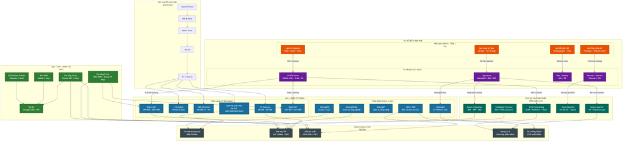

So do 5

> **Đọc sơ đồ:** Màu **xanh dương** = BU1 Điện tử | Màu **xanh lá** = BU2 CNC | Màu **tím** = DC nội bộ | Màu **cam** = R&D Labs | Màu **xanh ngọc** = Dịch vụ phần mềm | Màu **xám** = Khách hàng bên ngoài. Luồng mũi tên thể hiện dòng dữ liệu, sản phẩm, và dịch vụ tích hợp xuyên suốt hệ sinh thái [A].

### 2.21.2. Sơ đồ Tích hợp Dữ liệu — Từ Edge đến Cloud (Data Flow)

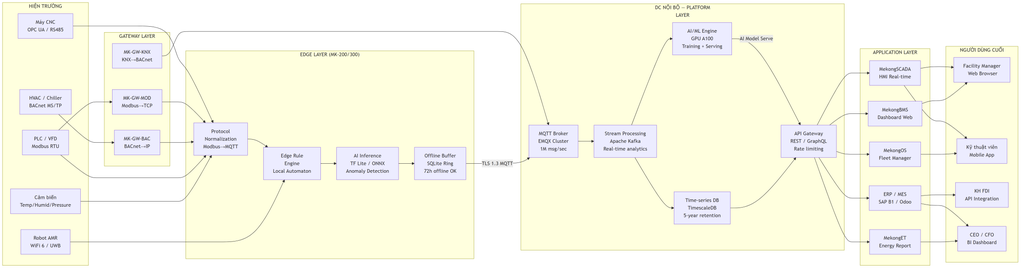

So do 6

> Kiến trúc phân lớp đảm bảo: độ trễ edge < 10ms (local automation), độ trễ nền tảng < 100ms (dashboard update), và khả năng offline hoạt động đầy đủ 72 giờ khi mất kết nối internet. Toàn bộ lưu lượng mã hoá TLS 1.3 end-to-end [A].

### 2.21.3. Sơ đồ Vòng đời Sản phẩm Tích hợp (Integrated Product Lifecycle)

[figure not shown]

So do 7

> Vòng đời sản phẩm khép kín — từ concept đến EOL — được quản lý nội bộ 100%, loại bỏ rủi ro phụ thuộc vào đơn vị thiết kế bên ngoài và rút ngắn NPI thời gian dẫn xuống còn 8–12 tuần cho dòng tái sử dụng nền tảng [A].

## 2.22. Dịch vụ Gia công Phần mềm và Build Phần mềm Theo Yêu cầu

### 2.22.1. Định vị Chiến lược — Tại sao Mekong làm Gia công Phần mềm?

DC nội bộ với GPU cluster và Lab Cloud & Cybersecurity (LAB4) tạo ra tiềm năng cung cấp **dịch vụ gia công phần mềm chuyên biệt** cho phân khúc IoT công nghiệp, nhúng (embedded), và AI. Đây là mảng doanh thu mới bổ sung — **không thay thế** 2 trụ cột chính — với CAPEX gần như bằng 0 vì tận dụng hạ tầng DC và R&D đã đầu tư.

| Yếu tố | Lý do Mekong có lợi thế |
| --- | --- |
| **Chuyên môn sâu IoT/Embedded** | Đội ngũ R&D đang phát triển firmware MK-200/DDC/Robot — năng lực sẵn có |
| **Lab AI/GPU nội bộ** | GPU A100 để huấn luyện mô hình, không cần thuê cloud tốn kém |
| **Nền tảng tích hợp** | MekongOS là staging environment thực tế để test tích hợp ngay |
| **Khách hàng giao thoa** | FDI mua CNC/IoT hardware → thường cần cả phần mềm quản lý, dashboard, app |
| **Vị trí KCNC** | Các tenant SHTP/KCNC là khách hàng tự nhiên cho IT outsourcing nội khu |

> **Phân loại:** Mảng này hoàn toàn phù hợp QĐ 38/2020 (Hoạt động nghiên cứu–phát triển, chuyển giao công nghệ) và NĐ 76/2018 (hoạt động dịch vụ CNTT thuộc doanh nghiệp CNC) [A].

### 2.22.2. Danh mục Dịch vụ Gia công Phần mềm

| TT | Dịch vụ | Mô tả | Phân khúc khách hàng | Giá (USD) | Biên gộp |
| --- | --- | --- | --- | --- | --- |
| 1 | **Embedded Firmware Development** | Phát triển firmware cho MCU/MPU (STM32, NXP, ESP32, RTOS) | Startup IoT, FDI electronics | 80-150 USD/giờ | 55-65% |
| 2 | **Custom IoT Application** | App web + mobile giám sát/điều khiển thiết bị IoT | Tòa nhà, nhà máy, khu CN | 15.000-80.000/dự án | 50-60% |
| 3 | **AI/ML Model Development** | Phát triển mô hình AI: predictive maintenance, anomaly detection, computer vision | FDI smart factory, robot SI | 20.000-150.000/dự án | 55-70% |
| 4 | **System Integration (SI) Software** | Tích hợp BMS + ERP + MES + SCADA (API bridge, middleware) | Nhà máy FDI, khu đô thị thông minh | 10.000-50.000/dự án | 50-65% |
| 5 | **OPC UA / Modbus / BACnet Driver** | Phát triển driver giao thức cho thiết bị bên thứ 3 | Siemens, Schneider integrator | 8.000-25.000/driver | 60-70% |
| 6 | **Cloud & Dashboard Development** | Xây dựng dashboard Grafana/React, data chuỗi đơn hàng, cloud API | Tất cả | 5.000-30.000/dự án | 55-65% |
| 7 | **Cybersecurity Assessment & Hardening** | Pen testing, IEC 62443 gap analysis, OT security design | FDI có yêu cầu ISO 27001/IEC 62443 | 5.000-20.000/assessment | 65-75% |
| 8 | **Digital Twin Prototype** | Xây dựng Digital Twin cho thiết bị/quy trình sản xuất | Nhà máy FDI tầm trung | 30.000-120.000/dự án | 50-60% |

**Tổng doanh thu mục tiêu — Dịch vụ gia công phần mềm:**

| Năm | Số dự án/hợp đồng | Doanh thu (K USD) | Ghi chú |
| --- | --- | --- | --- |
| Y3 | 2-3 | 30-50 | Pilot nội bộ + KH đầu tiên trong KCNC |
| Y5 | 5-8 | 100-180 | Mở rộng ra FDI tenant SHTP |
| Y7 | 10-15 | 250-400 | Scale, thêm AI/ML contracting |
| Y10 | 15-20 | 400-600 | Ổn định, tích hợp với MekongOS SaaS |
| **Y12+** | **18-25** | **500-700** | **Ổn định, recurring SI maintenance** |

> Doanh thu gia công phần mềm **chưa tính vào 12,00M USD canonical** — đây là upside tiềm năng nếu mảng này phát triển tốt. Khi có doanh thu thực tế từ Y5, sẽ điều chỉnh vào canonical [A].

### 2.22.3. Quy trình Giao nhận Dự án Phần mềm (Software Delivery Process)

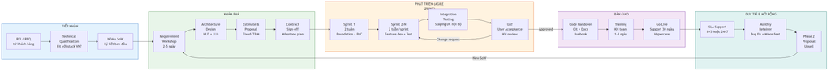

So do 8

**Mô hình Kinh doanh Gia công Phần mềm:**

| Mô hình | Phù hợp với | Cơ chế tính giá | Ưu điểm cho Mekong |
| --- | --- | --- | --- |
| **Fixed Price** | Dự án scope rõ ràng, ≤ 3 tháng | Giá cố định theo SoW | Dự báo doanh thu dễ dàng |
| **Time & Material (T&M)** | Dự án dài hạn, scope hay thay đổi | Rate × giờ làm việc | Linh hoạt, giảm rủi ro scope creep |
| **Retainer** | Duy trì hệ thống, support liên tục | Phí cố định/tháng | Doanh thu recurring, ổn định |
| **Mốc tiến độ-Based** | AI/ML project, Digital Twin | Thanh toán theo cột mốc | Dòng tiền sớm, giảm rủi ro |
| **Revenue Share** | Startup IoT có tiềm năng | % doanh thu sản phẩm | Upside tiềm năng cao |

### 2.22.4. Năng lực Kỹ thuật Đội Gia công Phần mềm

| Lĩnh vực | Ngôn ngữ / Khung | Chứng nhận mục tiêu | Năng lực hiện tại |
| --- | --- | --- | --- |
| **Embedded / Firmware** | C, C++, FreeRTOS, Zephyr, MicroPython | Arm Certified Developer | Sẵn có (từ R&D team) |
| **IoT Backend** | Python, Go, Node.js, MQTT, Kafka | AWS IoT, Azure IoT cert | Xây dựng Y4-Y5 |
| **AI/ML** | Python, PyTorch/TensorFlow, ONNX, ROS2 | NVIDIA DLI Certified | Sẵn có từ Robot R&D |
| **Frontend / Dashboard** | React.js, Grafana, D3.js, Flutter | — | Xây dựng Y4-Y5 |
| **DevOps / Cloud** | Docker, Kubernetes, Ansible, CI/CD | Kubernetes CKA | Xây dựng Y5-Y6 |
| **OT Security** | IEC 62443, NIST, Pen testing | CEH / OSCP | Xây dựng Y6-Y7 |

> **Nhân sự:** Mảng phần mềm vận hành với 8-12 kỹ sư từ **Lab Cloud & Cyber (LAB4)** và phần từ R&D team. Không cần tuyển dụng đột biến — tận dụng idle capacity giữa các sprint R&D sản phẩm. Từ Y7+, tách thành team riêng 12-15 người nếu doanh thu vượt 400K USD/năm [A].

## 2.23. Mô hình Tích hợp DC + R&D + Gia công — Cộng hưởng 3 Chiều

### 2.23.1. Kiến trúc Tích hợp DC với Hoạt động R&D và Gia công

DC nội bộ không chỉ là hạ tầng IT thụ động — mà là **“xương sống thông minh”** kết nối toàn bộ hoạt động R&D, sản xuất, phần mềm, và vận hành:

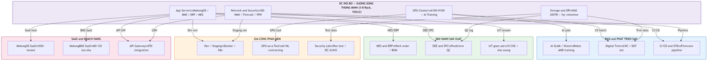

So do 9

### 2.23.2. Phân bổ Tải DC theo Hoạt động

[output not shown]

> Tổng OPEX DC nội bộ ~0,40M USD/năm [C] được phân bổ theo tỷ trọng. Chi phí gia công phần mềm chiếm ~15% = **60K USD/năm** — tương đương giá thuê GPU cloud ~1.500h/tháng trên AWS (tiết kiệm ~40% so với thuê ngoài) [A].

### 2.23.3. Sơ đồ Cộng hưởng Phân khúc Gia công CNC + Phần mềm

Nhiều khách hàng FDI cần **cả hai**: gia công chi tiết cơ khí chính xác (CNC) VÀ phần mềm quản lý/giám sát (IoT/SCADA). Mekong là đơn vị duy nhất tại KCNC cung cấp cả hai trong một hợp đồng tích hợp:

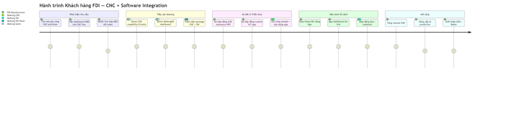

So do 10

**Gói Dịch vụ Tích hợp CNC + Phần mềm (Integrated Service Package):**

| Gói | Thành phần | Giá trị (USD/năm) | Đối tượng |
| --- | --- | --- | --- |
| **Pack A — CNC Starter** | 200 giờ CNC + MekongOS Starter (10 device) | 12.000-18.000 | SME, startup |
| **Pack B — Smart Factory Lite** | 400 giờ CNC + MES dashboard + IoT 50 device + support | 35.000-55.000 | Nhà máy tầm trung |
| **Pack C — FDI Premium** | 800+ giờ CNC 5-axis + Custom app + AMR 1 bộ + SLA | 120.000-200.000 | FDI tầm cao |
| **Pack D — Full Integration** | CNC full-time + SW team dedicated + Robot fleet + AI | > 300.000 | KH neo lớn |

> Chiến lược “bundled service” giúp tăng deal size trung bình từ 20-30K USD (CNC thuần) lên 50-150K USD (tích hợp), đồng thời tạo lock-in dài hạn thông qua SaaS thuê bao và maintenance contract. Tỷ lệ chuyển đổi từ CNC-only sang integrated package mục tiêu: 30% KH từ Y7 [A].

### 2.23.4. Lộ trình Phát triển Mảng Gia công Phần mềm (Y3-Y12)

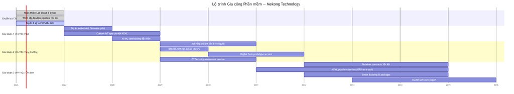

So do 11

## 2.24. Sơ đồ Hệ thống Chi tiết — BMS + SCADA + IoT (Triển khai View)

### 2.24.1. Sơ đồ Triển khai Điển hình — Tòa nhà Thương mại (BMS Full)

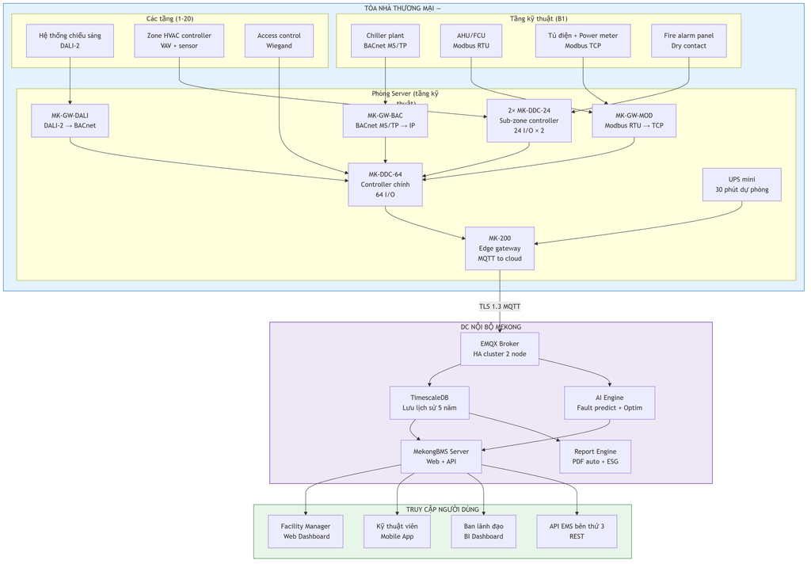

So do 12

**Điểm nổi bật từ sơ đồ triển khai:**

| Thành phần Mekong | Vai trò | Thiết bị thay thế (nếu không dùng Mekong) | Tiết kiệm |
| --- | --- | --- | --- |
| MK-DDC-64 | Controller chính toàn nhà | Schneider SmartStruxure SCD (6.000 USD) | 30-40% |
| MK-DDC-24 × 2 | Zone controller | Siemens PXC36 (2.500 USD/bộ) | 25-35% |
| MK-GW-BAC + MOD | Protocol gateway | Delta Controls (1.200 USD/bộ) | 20-30% |
| MekongBMS SaaS | Phần mềm quản lý | Honeywell EBI (15.000 USD/license) | 50-60% |
| MK-200 Edge | Cloud connectivity | 3rd party IoT gateway (800-1.200 USD) | 30-50% |
| **Tổng gói BMS full (500 điểm)** | — | **~80.000-120.000 USD** | **40-50%** |

> Giải pháp BMS trọn gói từ Mekong tiết kiệm 40-50% chi phí so với tích hợp thiết bị đa nhãn hiệu. Đây là lập luận thương mại cốt lõi khi tiếp cận khách hàng tòa nhà hạng B-C tại thị trường Việt Nam [A][B].

### 2.24.2. Sơ đồ Triển khai Điển hình — Nhà máy FDI (Smart Factory)

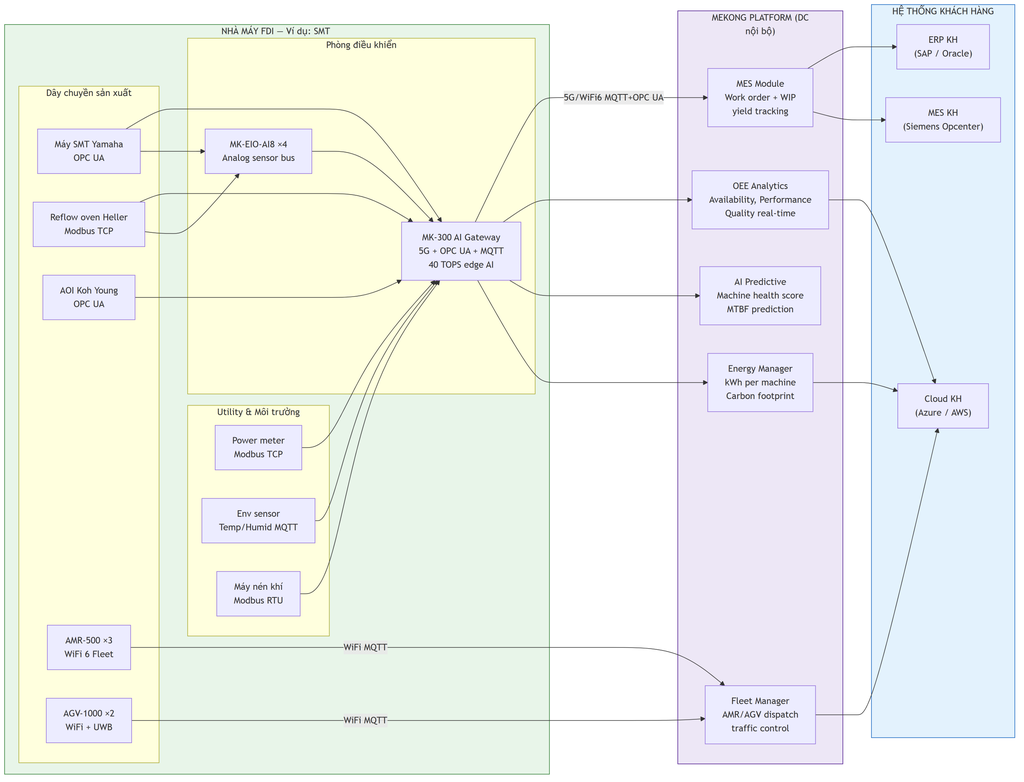

So do 13

> MK-300 với 40 TOPS AI tại edge xử lý **100% dữ liệu máy sản xuất ngay tại chỗ** — chỉ gửi anomaly alert và aggregated metrics lên DC. Điều này giảm 90% băng thông và đảm bảo vận hành khi mất kết nối WAN [A].

## 2.25. Tổng hợp Giá trị Mảng Phát triển Mới — R&D + DC + Gia công Phần mềm

### 2.25.1. Ma trận Nguồn Doanh thu Mới (Upside)

| Nguồn | Năm bắt đầu | DT ổn định (K USD/năm) | CAPEX bổ sung | Biên gộp | Trạng thái |
| --- | --- | --- | --- | --- | --- |
| Embedded firmware contracting | Y4 | 100-150 | 0 | 60-65% | Upside |
| Custom IoT app development | Y4 | 150-200 | 0 | 55-60% | Upside |
| AI/ML model contracting | Y5 | 100-200 | 50K (GPU upgrade) | 60-70% | Upside |
| SI software integration | Y5 | 100-150 | 0 | 55-65% | Upside |
| OT Security assessment | Y6 | 50-80 | 0 | 65-75% | Upside |
| Digital Twin service | Y7 | 100-150 | 0 | 50-60% | Upside |
| **Tổng gia công phần mềm** | **Y4+** | **600-930** | **~50K** | **~60%** |  |
| Integrated CNC + SW packages | Y6 | 200-400 | 0 | Mix | Upside |
| **Tổng upside tiềm năng** |  | **800-1.330** | **~50K** |  |  |

> Tổng upside doanh thu từ gia công phần mềm và gói tích hợp tích luỹ đến ổn định ước tính **0,80-1,33M USD/năm**, tương đương 6,7-11,1% doanh thu canonical 12,00M USD. Đây là **upside phi canonical** — sẽ bổ sung vào canonical chỉ khi có hợp đồng thực tế ký kết từ Y5 [A].

### 2.25.2. Tác động lên IRR nếu Upside Thực hiện được

| Kịch bản | DT Y12+ (M USD) | IRR ước tính | NPV (50Y, WACC 12%) | Ghi chú |
| --- | --- | --- | --- | --- |
| Base case (canonical) | 12,00 | 13,0% | 1,50M | [C] |
| Upside nhẹ (+0,50M/năm) | 12,50 | ~13,5% | ~1,80M | Software contracts win |
| Upside mạnh (+1,00M/năm) | 13,00 | ~14,0% | ~2,10M | Full integrated packages |
| Upside tối đa (+1,33M/năm) | 13,33 | ~14,3% | ~2,30M | Tất cả mảng phát triển |

> **Lưu ý CEO:** Bảng tác động IRR là ước tính định hướng [A] — không phải số liệu canonical. Chỉ điều chỉnh canonical khi có doanh thu thực tế xác nhận từ 2 năm liên tiếp. Nguyên tắc thận trọng tài chính bắt buộc [C].

### 2.25.3. Bảng Quyết định Ưu tiên Đầu tư Mảng Mới

| Mảng | Độ ưu tiên | Hành động ngay (Y3-Y4) | Điều kiện kích hoạt đầy đủ |
| --- | --- | --- | --- |
| Embedded firmware contracting | **P1** | Phân công 2 kỹ sư từ R&D team, thiết lập billing/contract template | 2+ KH ký hợp đồng |
| Custom IoT app (Dashboard, Mobile) | **P1** | Xây dựng reusable khung từ MekongOS | 3+ KH pilot |
| AI/ML contracting | **P2** | Chuẩn bị GPU usage metering, định giá model | 1 AI project anchor |
| SI + BMS integration | **P2** | Package template + SoW template chuẩn | BMS deal > 50K |
| Digital Twin service | **P3** | Sau khi MekongOS v2.0 stable | Smart factory anchor KH |
| OT Security | **P3** | Sau khi có OSCP/CEH certified engineer | FDI yêu cầu IEC 62443 |

# PHẦN III: MÔ HÌNH KINH DOANH

## 3.1. Tổng quan Mô hình Doanh thu

Mekong Technology vận hành mô hình doanh thu đa dạng từ **2 trụ cột kinh doanh**, với **9 nguồn doanh thu chính** phân loại thành 4 nhóm:

### Nhóm 1: Doanh thu Sản phẩm (Product Revenue)

| # | Nguồn | Trụ cột | Mô hình | Tỷ trọng Y12+ |
| --- | --- | --- | --- | --- |
| 1 | Bán IoT Gateway (MK-200/300) | BU1 | Bán đứt + Bảo hành 1 năm | 17% |
| 2 | Bán Robot AMR/AGV | BU1 | Bán đứt + Hợp đồng bảo trì | 20% |
| 3 | Gia công CNC B2B | BU2 | Hợp đồng cung ứng 1-5 năm | 29% |

### Nhóm 2: Doanh thu Dịch vụ Định kỳ (Recurring Revenue)

| # | Nguồn | Trụ cột | Mô hình | Tỷ trọng Y12+ |
| --- | --- | --- | --- | --- |
| 4 | MekongOS SaaS | BU1 | Thuê bao tháng/năm | 6% |
| 5 | MekongBMS License + SaaS | BU1 | License + thuê bao lưu trữ | 6% |

### Nhóm 3: Doanh thu Components (OEM/ODM)

| # | Nguồn | Trụ cột | Mô hình | Tỷ trọng Y12+ |
| --- | --- | --- | --- | --- |
| 6 | OEM/ODM Điện tử | BU1 | Hợp đồng sản xuất 6-24 tháng | 9% |
| 7 | I/O Modules + DDC + GW | BU1 | Bán đứt qua kênh BMS | 10% |

### Nhóm 4: Doanh thu Giá trị Gia tăng (VAS Revenue)

| # | Nguồn | Trụ cột | Mô hình | Tỷ trọng Y12+ |
| --- | --- | --- | --- | --- |
| 8 | Bảo trì Robot (AMR/AGV) | BU1 | Hợp đồng bảo trì hàng năm | 2% |
| 9 | Đào tạo CNC | BU2 | Khóa đào tạo cho đối tác | 1% |

> **Khác biệt V3 vs V2:** V2 có 12 nguồn doanh thu bao gồm Colocation, GPU-as-a-Service, Managed Services DC, Internet Transit, Cross-connect, SOC (6 nguồn DC thương mại). V3 loại bỏ toàn bộ 6 nguồn DC, tập trung vào 9 nguồn từ sản xuất và dịch vụ kỹ thuật [C].

### Cơ cấu Doanh thu theo Năm (V3 — 2 Trụ cột)

| Năm | BU1: IoT/BMS/Robot (M USD) | BU2: CNC (M USD) | **Tổng (M USD)** |
| --- | --- | --- | --- |
| Y4 | 0,80 | 0,20 | **1,00** |
| Y5 | 1,80 | 0,70 | **2,50** |
| Y6 | 3,30 | 1,20 | **4,50** |
| Y7 | 4,70 | 2,00 | **6,70** |
| Y8 | 6,20 | 2,50 | **8,70** |
| Y9 | 7,00 | 3,00 | **10,00** |
| Y10 | 7,80 | 3,20 | **11,00** |
| Y12+ | 8,50 | 3,50 | **12,00** |

> Doanh thu Y4 = 1,00M (IoT khai trương), Y8 = 8,70M, ổn định Y12+ = 12,00M USD/năm. Doanh thu 15Y tích lũy: ~140M USD [C].

## 3.2. Khách hàng Mục tiêu và Chiến lược Tiếp cận

### 3.2.1. Phân loại Khách hàng (V3 — 2 Trụ cột)

| Nhóm | Mô tả | Quy mô | Trụ cột phục vụ | Chiến lược |
| --- | --- | --- | --- | --- |
| **FDI Top-tier** | Samsung, Intel, Bosch, VinFast | 5-10 KH | CNC + IoT | Account-Based Marketing, đội sales chuyên biệt |
| **FDI Mid-tier** | Nidec, Jabil, Canon, Renesas | 10-20 KH | CNC + IoT | Trade show + Giới thiệu từ FDI Top |
| **VN Enterprise** | VNPT, FPT, VNG, Techcombank | 20-50 KH | IoT/BMS | Digital marketing + Partner channel |
| **KCNC Ecosystem** | DN trong KCNC TP.HCM | 50-100 KH | IoT SaaS | On-site demo + Ưu đãi proximity |
| **DNNVV** | Sản xuất nhỏ và vừa | 500-2.000 KH | IoT SaaS | Online sales + Channel partner |

### 3.2.2. Chiến lược Bán hàng theo Trụ cột

**IoT/Robot — Multi-Channel:** - Kênh trực tiếp: Đội sales 8-12 người (Key Account + Regional) - Kênh gián tiếp: 5-10 đại lý (System Integrators, VAR) - Kênh online: Website, MekongOS trial, Webinar - Closing time: 1-6 tháng

## 3.3. Chiến lược Phát triển Theo Giai đoạn (V3)

| Giai đoạn | Thời gian | CAPEX (M USD) | Mục tiêu chiến lược | Revenue target |
| --- | --- | --- | --- | --- |
| **Phase 0: Pháp lý** | Y0-Y1 | 1,50 | Giấy phép, thiết kế, sổ đỏ tạm | 0 |
| **Phase 1: Nền tảng** | Y1-Y3 | 8,45 | Xây dựng 3 công trình (**xưởng 2 tầng**), hạ tầng M&E | 0 |
| **Phase 2: Tăng trưởng** | Y3-Y5 | 9,60 | Lắp đặt CNC, SMT, DC nội bộ, IoT sản xuất | 1,00-3,00M/năm |
| **Phase 3: Mở rộng** | Y5-Y7 | 2,45 | Robot AMR scale, CNC thêm máy, BMS phát triển | 5,50-7,00M/năm |
| **Tái đầu tư** | Y7+ | Từ lợi nhuận | Xuất khẩu ASEAN, CNC nâng cấp, BMS/SCADA | > 8,70M/năm |
| **Tổng** |  | **22,00** |  |  |

> Lộ trình 4 Phase (0-1-2-3) phù hợp với CAPEX 22,00M USD. CSH 18,00M USD chi phủ Phase 0-2, vay 4,00M USD từ Y7 cho Phase 3 [C]. Nhà xưởng 2 tầng (Phase 1) tăng GFA 54,6% trong cùng footprint — không tăng diện tích đất, không vượt 14 m chiều cao KCNC.

## 3.4. Đối tác Chiến lược và Business Model Canvas

### 3.4.1. Đối tác Chiến lược (V3)

| Đối tác | Loại hình | Lĩnh vực | Giá trị hợp tác |
| --- | --- | --- | --- |
| DMG MORI Vietnam | Nhà cung cấp | CNC | Mua máy + Đào tạo + Bảo trì |
| Schneider Electric | Nhà cung cấp | Hạ tầng điện | UPS, PDU, tự động hóa |
| Siemens | Nhà cung cấp | BMS | MindSphere, reference design |
| JETRO Vietnam | Hỗ trợ | B2B Match | Kết nối nhà sản xuất Nhật cần CNC |
| KOTRA Vietnam | Hỗ trợ | B2B Match | Kết nối nhà sản xuất Hàn cần CNC |
| Hexagon Manufacturing Intelligence | Nhà cung cấp | QA/QC | CMM + Phần mềm + Đào tạo |
| Bộ KH&CN / NATEC | Chính phủ | R&D Grant | Hỗ trợ đề tài R&D + Trợ cấp |

> V3 không có đối tác NVIDIA (DGX) và FPT Telecom (Dark fiber) vì không có DC thương mại. GPU nội bộ mua lẻ theo nhu cầu AI training [C].

### 3.4.2. Business Model Canvas (V3 — 2 Trụ cột)

| Khối | Nội dung |
| --- | --- |
| **Đề xuất Giá trị** | Hệ sinh thái IoT+CNC tích hợp — gia công khung robot nội bộ, sản xuất electronics, one-stop cho FDI |
| **Phân khúc KH** | FDI (Samsung, Bosch, Canon), Enterprise VN, DNNVV, KCNC Ecosystem |
| **Kênh tiếp cận** | Direct sales (CNC), Digital + Channel (IoT), On-site demo (KCNC) |
| **Quan hệ KH** | Dedicated Account Manager (FDI), Self-service (SaaS), Community (KCNC) |
| **Dòng doanh thu** | CNC gia công (29%), IoT/Robot bán SP (37%), BMS/SaaS (12%), OEM/ODM (9%), VAS (3%) |
| **Tài nguyên chính** | 10 máy CNC, SMT line, 4 Lab R&D, 100-130 nhân sự, IP (MekongOS + Patents) |
| **Hoạt động chính** | Gia công CNC → Sản xuất IoT/Robot → Phát triển MekongOS/BMS → R&D |
| **Đối tác chính** | DMG MORI, Schneider, Siemens, JETRO/KOTRA, Hexagon |
| **Cơ cấu chi phí** | CAPEX 22,00M; OPEX (ước lượng): Nhân công SX 21%, NVL 42%, R&D 11%, SGA 12%, DC+Đất+BH 8%, KH 16% — xem chi tiết §3.13 và §5.3 |

## 3.5. Chiến lược Giá Chi tiết (Chiến lược Định giá)

### 3.5.1. Nguyên tắc Định giá

1. **Cost-Plus Mức cơ sở:** Giá sàn = chi phí biến đổi + phân bổ cố định + biên lợi nhuận tối thiểu 15%
2. **Value-Based Ceiling:** Giá trần theo willingness-to-pay, chuẩn ngành đối thủ khu vực
3. **Penetration Entry:** Y4-Y5 giá thâm nhập thấp hơn 10-15% thị trường
4. **Premium Upsell:** Từ Y6+ sau khi có chứng nhận ISO 9001, nâng giá ngang hoặc cao hơn 5-10%

### 3.5.2. Bảng Giá BU1 — IoT/Robot

| Sản phẩm | Giá Bán (USD) | COGS (USD) | Biên Gộp | Chuẩn ngành | Chiến lược |
| --- | --- | --- | --- | --- | --- |
| MK-200 (cơ bản) | 350-450 | 190 | 48-51% | Advantech: 500-700 | Thấp hơn 30% → thâm nhập |
| MK-300 (nâng cao) | 650-850 | 320-400 | 50-53% | Cisco IR1101: 900-1.200 | Thấp hơn 25% |
| Robot AMR-500 | 18.000-25.000 | 12.000-15.000 | 33-40% | MiR250: 35.000-50.000 | Thấp hơn 25-30% |
| Robot AMR-1000 | 28.000-38.000 | 17.000-23.000 | 39-40% | Geek+: 40.000-60.000 | Thấp hơn 15-20% |
| Robot AGV-500 | 12.000-18.000 | 8.000-11.000 | 33-39% | TQ AGV: 15.000-25.000 | Tương đương |
| MekongOS SaaS (Pro) | 79/tháng/TB | 15 | 81% | AWS IoT: 100-200/th | Giá trị cao, tích hợp |
| MekongBMS License | 5.000-15.000/tòa | 1.500-4.000 | 70-73% | Niagara: 15.000-40.000 | Thấp hơn 50-60% |

> Biên gộp IoT trung bình: 45-55% (phần cứng) + 72-85% (SaaS). Blended margin hướng tới 55-60% khi tỷ trọng SaaS tăng [C].

### 3.5.3. Bảng Giá BU2 — CNC Outsourcing

| Dịch vụ | Đơn giá (USD) | Chi phí (USD) | Biên Gộp | Chuẩn ngành |
| --- | --- | --- | --- | --- |
| CNC 3 trục — Nhôm | 28-40/giờ máy | 18-22 | 36-45% | VN market: 25-35 |
| CNC 3 trục — Thép | 30-42/giờ máy | 20-25 | 33-40% | VN market: 28-38 |
| CNC 5 trục — Nhôm | 45-55/giờ máy | 28-32 | 38-42% | TW/TH: 50-70 |
| CNC 5 trục — Thép/Inox | 55-70/giờ máy | 35-42 | 36-40% | TW/TH: 65-90 |
| CNC 5 trục — Titan | 80-120/giờ máy | 50-70 | 38-42% | Nhật/Đức: 120-180 |
| Wire EDM | 35-50/giờ máy | 22-30 | 37-40% | VN: 30-45 |
| Surface Grinding | 25-35/giờ máy | 15-20 | 40-43% | VN: 20-30 |
| Đo lường CMM (FAI) | 150-300/báo cáo | 80-150 | 47-50% | Thị trường: 200-500 |
| Đào tạo CNC (3 tháng) | 3.000-5.000/người | 1.500-2.500 | 50% | DMG MORI: 8.000-12.000 |

> Biên gộp CNC trung bình: 35-42%. V3 có thêm Wire EDM và Surface Grinder — tăng khả năng tự chủ xử lý bề mặt, giảm thuê ngoài [C].

**Lộ trình Giá CNC:**

| Giai đoạn | Chứng nhận | Hệ số Giá | Ví dụ: 5-trục Nhôm/giờ |
| --- | --- | --- | --- |
| Y4 (Entry) | Chưa có | 1,00× | 45 USD |
| Y5+ (ISO 9001) | ISO 9001:2015 | 1,05-1,10× | 47-50 USD |
| Y10+ (Option) | IATF 16949 hoặc AS9100 | 1,20-1,35× | 54-61 USD |

## 3.6. Kinh tế Đơn vị (Unit Economics)

### 3.6.1. IoT — MK-200 Gateway

| Thông số | Giá trị | Ghi chú |
| --- | --- | --- |
| ASP (Average Selling Price) | 400 USD | Sau chiết khấu |
| BOM (Bill of Materials) | 150 USD | PCB + Components + Enclosure |
| Manufacturing (SMT + Assembly) | 30 USD | 0,5h SMT + 1h assembly |
| Testing & QC | 10 USD | Burn-in + Functional test |
| **COGS** | **190 USD** |  |
| **Gross Margin** | **210 USD (52,5%)** |  |
| Packaging & Logistics | 5 USD |  |
| Warranty Reserve (2%) | 8 USD |  |
| Sales Commission (8%) | 32 USD |  |
| **Contribution Margin** | **165 USD (41,3%)** | [C] |

### 3.6.2. MekongOS SaaS (Pro Plan)

| Thông số | Giá trị | Ghi chú |
| --- | --- | --- |
| Revenue/thiết bị/năm | 948 USD | 79 USD × 12 tháng |
| COGS/năm | 156 USD | Cloud + Support |
| **Gross Margin/năm** | **792 USD (83,5%)** | SaaS margin cao |
| Customer Acquisition Cost (CAC) | 500 USD | Digital marketing + Sales |
| Thời gian hoàn vốn | 7,6 tháng | CAC / Monthly Contribution |
| Lifetime Value (LTV, 3 năm) | 2.376 USD | 3 × 792 |
| **LTV/CAC** | **4,8×** | > 3× là tốt cho SaaS [C] |

### 3.6.3. CNC — Kinh tế 1 Giờ máy 5-trục (Nhôm)

| Thông số | Y4 | Y8 | Ghi chú |
| --- | --- | --- | --- |
| Giá bán (MHR) | 45 USD | 50 USD | Tăng nhờ ISO 9001 |
| Chi phí biến đổi (dụng cụ, điện, MWF, nhân công) | 14,8 USD | 13,6 USD | Learning curve giảm VC |
| **Contribution Margin** | **30,2 USD (67%)** | **36,4 USD (73%)** |  |
| Chi phí cố định/giờ (khấu hao, bảo trì, overhead) | 20 USD | 21 USD |  |
| **Net Margin/giờ** | **10,2 USD (23%)** | **15,4 USD (31%)** | [C] |

### 3.6.4. OEE máy CNC (10 máy V3)

| Chỉ số | Y4 | Y6 | Y8 | Y12+ | Chuẩn ngành |
| --- | --- | --- | --- | --- | --- |
| Availability | 80% | 85% | 90% | 92% | World-class: 90% |
| Performance | 75% | 80% | 85% | 88% | World-class: 95% |
| Quality (FPY) | 85% | 90% | 94% | 96% | World-class: 99% |
| **OEE** | **51%** | **61%** | **72%** | **78%** | World-class: 85% |

## 3.7. Chiến lược Xuất khẩu và Mở rộng ASEAN

### 3.7.1. Chiến lược 3 Vòng Xuất khẩu

| Vòng | Thị trường | Timeline | Sản phẩm chính | Revenue target |
| --- | --- | --- | --- | --- |
| **Vòng 1: Nội địa** | VN (KCNC + FDI) | Y4-Y6 | IoT + CNC | 90-95% tổng DT |
| **Vòng 2: ASEAN-5** | Thái Lan, Malaysia, Indonesia, singapore | Y6-Y8 | CNC parts + IoT Gateway | 5-10% tổng DT |
| **Vòng 3: Đông Á** | Nhật, Hàn, Đài Loan | Y8+ | CNC Precision + Robot | 10-15% tổng DT |

### 3.7.2. Thị trường CNC Xuất khẩu — ASEAN

| Quốc gia | Nhu cầu CNC | Ngành chính | Lợi thế Mekong | Ưu tiên |
| --- | --- | --- | --- | --- |
| **Thái Lan** | Cao | Ô tô (2.500+ NSX) | Giá thấp hơn 10-15%, FTA 0% | ★★★★★ |
| **Singapore** | Thấp (thuê ngoài) | Bán dẫn, Aerospace | Gần (2h bay), SG thuê ngoài VN | ★★★★☆ |
| **Malaysia** | Trung bình-Cao | Bán dẫn, E&E | Giá cạnh tranh, gần Penang | ★★★☆☆ |
| **Indonesia** | Trung bình | Ô tô, Đóng tàu | Market 280M dân, chi phí VN thấp | ★★★☆☆ |

**Doanh thu Xuất khẩu Dự kiến (V3):**

| Năm | XK CNC (K USD) | XK IoT (K USD) | Tổng XK (K USD) | % Tổng DT |
| --- | --- | --- | --- | --- |
| Y5 | 100 | 50 | 150 | 5% |
| Y7 | 350 | 150 | 500 | 7% |
| Y8 | 600 | 250 | 850 | 10% |
| Y10 | 1.000 | 400 | 1.400 | 13% |
| Y12+ | 1.500 | 600 | 2.100 | 18% |

> Target: Xuất khẩu chiếm 15-20% doanh thu vào Y12+. ISO 9001 là điều kiện cần; IATF/AS9100 là option nâng cấp khi có hợp đồng cụ thể [A].

## 3.8. Chuỗi đơn hàng Khách hàng CNC (Pre-operation)

| # | Khách hàng | Ngành | Sản phẩm cần gia công | Xác suất | Revenue/năm (K USD) |
| --- | --- | --- | --- | --- | --- |
| 1 | Bosch VN | Ô tô | Vỏ sensor, connector | 60% | 250-400 |
| 2 | Nidec VN | Motor | Shaft, Housing | 50% | 200-350 |
| 3 | Samsung SEHC | Điện tử | Mold insert, Jig | 40% | 150-300 |
| 4 | Canon VN | Quang học | Lens housing, mount | 45% | 180-280 |
| 5 | Intel Products VN | Bán dẫn | Test fixture, socket | 35% | 80-150 |
| 6 | FDI Nhật (qua JETRO) | Đa ngành | Mixed parts | 25% | 100-200 |
| 7 | FDI Hàn (qua KOTRA) | Điện tử | Bracket, chassis | 25% | 80-150 |
|  | **Weighted Total** |  |  |  | **~700K** |

## 3.9. Customer Acquisition Cost (CAC) theo Trụ cột

| Trụ cột / Sản phẩm | CAC trung bình | Sales Cycle | LTV (3 năm) | LTV/CAC |
| --- | --- | --- | --- | --- |
| **CNC B2B** | 5.000-15.000 USD | 3-12 tháng | 120.000-500.000 USD | 15-35× |
| **IoT Gateway** | 200-500 USD | 1-3 tháng | 1.500-3.000 USD | 5-10× |
| **Robot AMR** | 3.000-8.000 USD | 6-18 tháng | 60.000-150.000 USD | 10-20× |
| **MekongOS SaaS** | 500 USD | 1-3 tháng | 2.376 USD | 4,8× |
| **MekongBMS** | 2.000-5.000 USD | 3-6 tháng | 20.000-50.000 USD | 6-12× |

## 3.10. Chiến lược Cạnh tranh

### 3.10.1. CNC Positioning Map

| Tiêu chí | Mekong V3 | VPIC | Cosmos | TQ Competition |
| --- | --- | --- | --- | --- |
| Năng lực 5-axis | 9/10 | 3/10 | 5/10 | 6/10 |
| Chứng nhận | 5/10 (ISO 9001) | 6/10 | 4/10 | 7/10 |
| Giá cạnh tranh | 7/10 | 8/10 | 7/10 | 9/10 |
| Chất lượng nhất quán | 8/10 | 5/10 | 6/10 | 5/10 |
| NDA/ITAR compliance | 8/10 | 3/10 | 3/10 | 2/10 |
| **Tổng** | **37/50** | **25/50** | **25/50** | **29/50** |

### 3.10.2. IoT Positioning Map

| Tiêu chí | Mekong | VN Startups | Chinese HW | Siemens/ABB |
| --- | --- | --- | --- | --- |
| Full-stack (HW+FW+Cloud) | 9/10 | 4/10 | 6/10 | 8/10 |
| Giá cạnh tranh | 8/10 | 7/10 | 9/10 | 3/10 |
| Hệ sinh thái BMS | 8/10 | 2/10 | 5/10 | 9/10 |
| Hỗ trợ địa phương | 9/10 | 8/10 | 3/10 | 5/10 |
| **Tổng** | **34/40** | **21/40** | **23/40** | **25/40** |

> Mekong cạnh tranh bằng full-stack capability (HW + FW + Cloud + CNC nội bộ) — rất ít đối thủ VN có năng lực tương đương [A].

## 3.11. Dự báo Doanh thu 15 Năm — V3

| Năm | BU1 (M USD) | BU2 (M USD) | Tổng (M USD) | Ghi chú |
| --- | --- | --- | --- | --- |
| Y0-Y3 | 0 | 0 | 0 | Giai đoạn xây dựng |
| Y4 | 0,80 | 0,20 | 1,00 | IoT khai trương |
| Y5 | 1,80 | 0,70 | 2,50 | Ramp-up |
| Y6 | 3,30 | 1,20 | 4,50 | CNC tăng công suất |
| Y7 | 4,70 | 2,00 | 6,70 | Mở rộng đơn hàng |
| Y8 | 6,20 | 2,50 | 8,70 | Robot bắt đầu bán tốt |
| Y9 | 7,00 | 3,00 | 10,00 | Tiếp cận 80% công suất |
| Y10 | 7,80 | 3,20 | 11,00 | Ổn định |
| Y12+ | 8,50 | 3,50 | 12,00 | Ổn định |
| **Tổng 15Y** | **~100** | **~40** | **~140** | [C] |

**Xu hướng chiến lược:** BU1 (IoT/BMS/Robot) tăng tỷ trọng nhờ recurring revenue (SaaS compound). BU2 (CNC) ổn định — backbone dòng tiền. Mô hình V3 đơn giản hơn V2 nhưng ít rủi ro hơn do tập trung nguồn lực [A].

## 3.12. Phân tích Tính Mùa vụ Doanh thu (Revenue Seasonality)

### 3.12.1. Đặc điểm Mùa vụ theo Trụ cột

| Quý | BU1: IoT/BMS/Robot | BU2: CNC/MPMC | Tổng hợp | Giải thích |
| --- | --- | --- | --- | --- |
| Q1 (Jan–Mar) | 0,85× | 0,80× | 0,83× | Sau Tết, khách hàng chậm ra quyết định |
| Q2 (Apr–Jun) | 1,00× | 0,95× | 0,98× | Phê duyệt ngân sách, Project mới triển khai |
| Q3 (Jul–Sep) | 1,05× | 1,10× | 1,07× | Cao điểm thi công BMS, FDI đặt hàng cho Q4 |
| Q4 (Oct–Dec) | 1,10× | 1,15× | 1,12× | Xả ngân sách cuối năm, FDI chốt PO trước Noel |
| **Tổng 4 quý** | **4,00×** | **4,00×** | **4,00×** | Bình quân = 1,00× |

> **Ghi chú:** Hệ số mùa vụ (×) là thừa số nhân với doanh thu quý bình quân. Ví dụ: Y12+ ổn định 12,00M/năm → quý bình quân = 3,00M. Q4 đạt 3,00M × 1,12 = 3,36M. Q1 = 3,00M × 0,83 = 2,49M. Biên độ dao động ±17% — nằm trong khả năng quản lý vốn lưu động [A].

### 3.12.2. Tác động đến Dòng tiền

| Thông số | Q1 (thấp nhất) | Q4 (cao nhất) | Chênh lệch |
| --- | --- | --- | --- |
| Doanh thu quý (Y12+, M USD) | 2,49 | 3,36 | 0,87 |
| COGS quý (45%) | 1,12 | 1,51 | 0,39 |
| Cash inflow ròng quý | 1,37 | 1,85 | 0,48 |

> Bộ đệm vốn lưu động 2,00M (Phase 3) đủ hấp thụ biến động mùa vụ ±0,48M/quý. Không cần vay ngắn hạn bổ sung [B].

### 3.12.3. Chiến lược Điều tiết Mùa vụ

| Biện pháp | Trụ cột | Hiệu quả |
| --- | --- | --- |
| Hợp đồng BMS bảo trì hàng năm (recurring) | BU1 | Đều đặn 12 tháng, giảm biên độ Q1 |
| MekongOS SaaS thu phí tháng | BU1 | Doanh thu đều, không theo mùa |
| Chạy CNC thuê ngoài (giờ máy) khi rảnh Q1 | BU2 | Tận dụng công suất thấp điểm |
| Ưu đãi đặt hàng sớm Q1 (chiết khấu 3-5%) | BU2 | Kéo doanh thu từ Q2 về Q1 |

## 3.13. OPEX Dự kiến theo Trụ cột

### 3.13.1. Phân bổ OPEX theo BU (Ổn định Y12+)

| Hạng mục | BU1 (M/năm) | % DT BU1 | BU2 (M/năm) | % DT BU2 | Tổng (M/năm) | % DT Tổng |
| --- | --- | --- | --- | --- | --- | --- |
| NVL và Linh kiện | 2,55 | 30,0% | 1,05 | 30,0% | 3,60 | 30,0% |
| Nhân công trực tiếp | 1,10 | 12,9% | 0,70 | 20,0% | 1,80 | 15,0% |
| **COGS** | **3,65** | **42,9%** | **1,75** | **50,0%** | **5,40** | **45,0%** |
| R&D | 0,80 | 9,4% | 0,16 | 4,6% | 0,96 | 8,0% |
| Sales + Marketing | 0,50 | 5,9% | 0,22 | 6,3% | 0,72 | 6,0% |
| Quản lý + Hành chính | 0,50 | 5,9% | 0,22 | 6,3% | 0,72 | 6,0% |
| DC nội bộ (phân bổ) | 0,30 | 3,5% | 0,10 | 2,9% | 0,40 | 3,3% |
| Thuê đất KCNC (phân bổ) | 0,08 | 1,0% | 0,04 | 1,1% | 0,12 | 1,0% |
| Bảo hiểm + Bảo trì | 0,18 | 2,1% | 0,12 | 3,4% | 0,30 | 2,5% |
| **Tổng OPEX (chưa KH)** | **6,01** | **70,7%** | **2,61** | **74,6%** | **8,62** | **71,8%** |
| Khấu hao (phân bổ) | 0,90 | 10,6% | 0,50 | 14,3% | 1,40 | 11,7% |
| **EBITDA** | **2,49** | **29,3%** | **0,89** | **25,4%** | **3,38** | **28,2%** |

> **Kiểm tra:** EBITDA tổng = 3,38M = 12,00M × 28,2% → làm tròn **~30%** [C]. BU1 có EBITDA margin tốt hơn (29,3%) nhờ R&D phần mềm có biên lợi nhuận cao. BU2 margin thấp hơn (25,4%) do COGS CNC cao (nhôm, thép, dao cắt) và nhân công lành nghề đắt [A].

### 3.13.2. Cấu trúc Chi phí Cố định vs Biến đổi

| Loại chi phí | Giá trị (M/năm) | % Tổng OPEX | Đặc điểm |
| --- | --- | --- | --- |
| **Biến đổi** (NVL, linh kiện) | 3,60 | 41,8% | Tỷ lệ thuận với doanh thu |
| **Bán biến đổi** (nhân công, năng lượng) | 2,22 | 25,7% | Biến đổi bậc thang |
| **Cố định** (thuê đất, KH, quản lý, R&D core) | 2,80 | 32,5% | Không đổi khi DT thay đổi ±20% |
| **Tổng** | **8,62** | **100%** |  |

### 3.13.3. Đòn bẩy Hoạt động (Operating Leverage)

| Kịch bản DT | Doanh thu (M) | COGS (M) | GM (M) | OPEX cố định (M) | EBITDA (M) | EBITDA % |
| --- | --- | --- | --- | --- | --- | --- |
| -20% | 9,60 | 4,32 | 5,28 | 2,80 | 0,66 | 6,9% |
| -10% | 10,80 | 4,86 | 5,94 | 2,80 | 1,92 | 17,8% |
| Base | 12,00 | 5,40 | 6,60 | 2,80 | 3,38 | 28,2% |
| +10% | 13,20 | 5,94 | 7,26 | 2,80 | 4,04 | 30,6% |
| +20% | 14,40 | 6,48 | 7,92 | 2,80 | 4,70 | 32,6% |

> **Đòn bẩy hoạt động:** Khi DT giảm 20%, EBITDA giảm từ 3,38M xuống 0,66M (giảm 80%) — DOL (Degree of Operating Leverage) ≈ 4,0×. Rủi ro biên lớn nhất nằm ở giai đoạn Y4-Y6 khi chi phí cố định chiếm tỷ trọng cao. Từ Y7 trở đi, quy mô doanh thu đủ lớn để hấp thụ biến động [A].

## 3.14. Lộ trình Phát triển Sản phẩm (Product Lộ trình)

### 3.14.1. Giai đoạn theo Năm

| Giai đoạn | Năm | BU1 — Sản phẩm cốt lõi | BU2 — Dịch vụ CNC | Mục tiêu |
| --- | --- | --- | --- | --- |
| **Seed** | Y1–Y3 | IoT Gateway MK-200 v1, MekongBMS alpha | Setup 4 máy CNC đầu tiên | Chạy thử, lấy phản hồi |
| **Launch** | Y4 | MK-200 v2 (Modbus+BACnet), MekongBMS v1, MK-EIO | CNC 7/10 máy chạy, khung Robot MVP | Doanh thu 1,00M [C] |
| **Scale** | Y5–Y6 | MK-300 (WiFi+4G), Robot AMR v1, MekongOS SaaS | CNC 10/10 máy, Jig/Fixture mở rộng | Doanh thu 2,50–4,50M [C] |
| **Expand** | Y7–Y9 | Robot AGV v1, AI Predictive Maintenance, OEM ramp | FDI part đa dạng, thuê ngoài CNC giờ | Doanh thu 6,70–10,00M [C] |
| **Mature** | Y10+ | MekongBMS Enterprise, Robot v3 (AI navigation) | CNC precision parts export ASEAN | Ổn định 12,00M [C] |

### 3.14.2. Chuỗi đơn hàng Sản phẩm Mới (Y5–Y8)

| Sản phẩm | BU | Năm dự kiến | DT tiềm năng (M/năm) | Rủi ro | Đầu tư R&D |
| --- | --- | --- | --- | --- | --- |
| MK-300 (Gateway IoT thế hệ 2) | BU1 | Y5 | 0,80 | Thấp | 50K (nâng cấp HW) |
| Robot AMR v1 | BU1 | Y5 | 0,30 | Trung bình | 200K (cơ khí + SW) |
| MekongOS SaaS | BU1 | Y6 | 0,30 | Thấp | 100K (cloud + UI) |
| Robot AGV v1 | BU1 | Y7 | 0,60 | Trung bình | 250K |
| AI Predictive Maintenance | BU1 | Y8 | 0,20 | Cao | 150K (ML model) |
| CNC ASEAN Export | BU2 | Y8 | 0,50 | Trung bình | 50K (certification) |
| OEM batch production | BU1 | Y6 | 1,10 | Thấp | 100K (SMT setup) |
| **Tổng DT tiềm năng** |  |  | **3,80** |  | **900K** |

> ROI R&D chuỗi đơn hàng: 3,80M DT tiềm năng / 0,90M đầu tư = **4,2×** — hấp dẫn. Ưu tiên sản phẩm rủi ro thấp-trung bình trước (MK-300, OEM, SaaS) [A].

### 3.14.3. Cấu trúc Hợp đồng Thương mại theo Nhóm Doanh thu

| Nhóm doanh thu | Cấu trúc hợp đồng | Điều khoản thanh toán | Mục tiêu quản trị |
| --- | --- | --- | --- |
| Bán Gateway / DDC / GW | PO + SLA bảo hành | 50% đặt cọc, 50% trước giao hàng hoặc Net 30 | Hạn chế công nợ với KH mới |
| MekongOS SaaS / BMS lưu trữ | Thuê bao 12-36 tháng | Thu trước theo quý/năm | Tăng recurring dòng tiền |
| Robot AMR/AGV | Hợp đồng dự án + FAT/SAT | 30% đặt cọc, 40% FAT, 20% SAT, 10% retention | Khóa dòng tiền theo mốc tiến độ |
| CNC B2B | Supply agreement 1-3 năm + call-off PO | Net 30-60 sau FAI pass | Ổn định utilization máy |
| OEM/ODM điện tử | NRE + Pilot + Mass Production | 40% NRE upfront, phần còn lại theo EVT/DVT/PVT | Không để R&D treo vốn |
| Bảo trì / AMC | Hợp đồng 12 tháng gia hạn | Thu trước 6-12 tháng | Doanh thu ít mùa vụ |

| Loại khách hàng | Hạn mức công nợ | Kiểm soát |
| --- | --- | --- |
| FDI Top-tier | 45-60 ngày | MSA/PO, đánh giá tín dụng nội bộ |
| SI / đại lý nội địa | 30 ngày | Trần công nợ theo doanh số 3 tháng |
| OEM mới | 0-15 ngày | Đặt cọc + nghiệm thu từng cổng |
| SaaS / SME | Trả trước | Tự động gia hạn và khóa dịch vụ nếu quá hạn |

> **Nguyên tắc V3:** Tăng trưởng doanh thu không đánh đổi bằng kéo dài công nợ. Với CAPEX 22,00M USD và giai đoạn đầu doanh thu còn mỏng, kiểm soát cash conversion cycle là điều kiện sống còn [C].

### 3.14.4. Economics theo Kênh Phân phối

| Kênh | Sản phẩm phù hợp | Discount / commission | CAC tương đối | Chu kỳ chốt | Vai trò |
| --- | --- | --- | --- | --- | --- |
| Direct enterprise sales | Robot, CNC, OEM/ODM, BMS lớn | 0-5% | Cao | 3-12 tháng | Chốt deal lớn, kiểm soát kỹ thuật |
| SI / VAR partner | BMS, Gateway, DDC, GW | 15-25% | Trung bình | 2-6 tháng | Scale nhanh, phủ địa lý |
| Inside sales / digital | MekongOS SaaS, gateway nhỏ | 5-10% promo | Thấp | 2-8 tuần | Tạo volume lead |
| Ecosystem KCNC | Pilot smart factory / demo | Theo case | Thấp | 1-3 tháng | Showcase reference |

| Chỉ tiêu MekongBMS | Direct | Qua SI |
| --- | --- | --- |
| ASP license trung bình | 10.000 USD | 10.000 USD |
| Discount / partner margin | 0 | 2.000 USD |
| CAC / deal | 2.500 USD | 800 USD |
| Chi phí hỗ trợ triển khai | 1.200 USD | 1.800 USD |
| Contribution còn lại | 6.300 USD | 5.400 USD |

> **Kết luận kênh:** Giai đoạn Y4-Y6 nên ưu tiên **60-70% doanh thu BU1 qua direct + pilot**, sau đó tăng dần tỷ trọng SI/VAR lên 35-45% từ Y7 để mở rộng mà không phình quá nhanh bộ máy sales [A].

### 3.14.5. Quản trị Funnel Bán hàng và KPI Thương mại

| Chỉ số | BU1 | BU2 | Mục tiêu Y5 |
| --- | --- | --- | --- |
| Marketing Qualified Leads (MQL) / quý | 120 | 20 | 140 |
| Sales Qualified Leads (SQL) / quý | 36 | 12 | 48 |
| Proposal / RFQ phát hành / quý | 18 | 10 | 28 |
| Tỷ lệ chốt deal | 18-22% | 20-25% | ≥ 20% |
| Doanh thu / salesperson / năm | 350-500K USD | 500-800K USD | ≥ 450K |
| Tỷ lệ renewal SaaS | 85-90% | N/A | ≥ 85% |
| OTIF | 95% | 95% | ≥ 95% |

1. **Lead generation:** webinar, trade show, JETRO/KOTRA matching, referral từ KCNC.
2. **Technical qualification:** presales + application engineering đánh giá fit sản phẩm.
3. **Commercial qualification:** kiểm tra GM, CAC, rủi ro công nợ, mức độ customization.
4. **Pilot / quotation:** ưu tiên pilot trả phí thay vì PoC miễn phí kéo dài.
5. **Conversion:** chuyển sang MSA / supply agreement / thuê bao agreement.
6. **Expansion:** cross-sell từ CNC sang IoT/BMS và ngược lại.

> Mô hình funnel này phù hợp doanh nghiệp công nghệ công nghiệp B2B, nơi presales và application engineering quyết định phần lớn xác suất chốt deal chứ không chỉ marketing thuần túy [B].

### 3.14.6. SWOT Tổng hợp Mô hình Kinh doanh V3

#### A. Phân tích SWOT

[output not shown]

#### B. Chiến lược SO-ST-WO-WT

| Chiến lược | Nội dung | Ưu tiên |
| --- | --- | --- |
| **SO: Tấn công** | Tận dụng full-stack + FDI dịch chuyển để chiếm phân khúc mid-tier BMS/CNC | P1 |
| **SO: Mở rộng** | Dùng synergy 2 BU để cross-sell robot + IoT cho khách CNC | P1 |
| **WO: Khắc phục** | Xây dựng reference case 3-5 KH đầu tiên tại KCNC để bù “thiếu thành tích đã kiểm chứng” | P1 |
| **WO: Phòng ngừa** | Diversify nhà cung cấp IC (dual-source AVL) qua DigiKey + Mouser + Arrow | P2 |
| **ST: Phản ứng** | Không cạnh tranh giá thuần với TQ — tập trung giá trị tích hợp + hậu mãi + localization | P1 |
| **ST: Bảo vệ** | Equity incentive + cross-training để giảm key person risk | P2 |
| **WT: Tối thiểu hóa** | Hợp đồng FDI dài hạn (1-3Y supply agreement) để ổn định doanh thu giai đoạn đầu | P1 |

### 3.14.7. Mô hình Cầu nối Doanh thu (Revenue Bridge Y4 → Y12)

| Bước | Nguồn tăng trưởng | Giá trị gia tăng (M USD) | Doanh thu tích lũy |
| --- | --- | --- | --- |
| 0 | **Base Y4** | — | **1,00** |
| 1 | IoT Gateway ramp-up (MK-200 volume + MK-300 launch) | +1,50 | 2,50 |
| 2 | CNC utilization tăng (50% → 65% OEE) + FDI parts mới | +1,50 | 4,00 |
| 3 | Robot AMR/AGV sản xuất hàng loạt (Y6-Y7) | +1,50 | 5,50 |
| 4 | BMS/SCADA doanh thu license + SI projects tăng | +1,20 | 6,70 |
| 5 | OEM/ODM ramp theo factory utilization | +1,00 | 7,70 |
| 6 | MekongOS SaaS compound + recurring maintenance | +1,00 | 8,70 |
| 7 | CNC OEE tăng (65% → 78%) + sản phẩm giá trị cao | +1,30 | 10,00 |
| 8 | Full product portfolio + ASEAN export pilot | +1,00 | 11,00 |
| 9 | Recurring base tích lũy + expansion revenue | +1,00 | **12,00** |

> Revenue bridge cho thấy không có “bước nhảy phi thực tế” — mỗi bước tăng 1,0-1,5M USD, phù hợp quy mô tổ chức 100-130 nhân sự và 14 nhóm sản phẩm. Rủi ro lớn nhất tập trung ở bước 3 (robot) và bước 4 (BMS) — hai dòng sản phẩm mới chưa có thành tích đã kiểm chứng thương mại [A].

### 3.14.8. Chiến lược Giá Đặc biệt theo Giai đoạn Phát triển

| Giai đoạn | Chiến lược giá | Áp dụng cho | Lý do |
| --- | --- | --- | --- |
| **Y4-Y5 (Launch)** | Giá thâm nhập thị trường: giảm 10-15% so với ASP target | IoT Gateway, BMS pilot | Xây dựng installed base, lấy reference |
| **Y4-Y5 (Launch)** | Cost-plus 25% (thấp) | CNC parts FDI | Chiếm volume, chứng minh chất lượng |
| **Y5-Y7 (Scale)** | Định giá theo giá trị | BMS SI project, Robot | Giá dựa trên tiết kiệm năng lượng / ROI KH |
| **Y6-Y8 (Scale)** | Freemium → Premium | MekongOS SaaS | 50 device miễn phí → nâng cấp trả phí |
| **Y7+ (Mature)** | Standard định giá + volume discount | Tất cả | Bảng giá niêm yết, discount theo cam kết volume |
| **Y8+ (Export)** | Market parity + localization premium | ASEAN CNC | Giá ngang thị trường + dịch vụ địa phương |

### 3.14.9. Quản trị Churn và Customer Success

| Chỉ tiêu | Mục tiêu | Phương pháp đạt |
| --- | --- | --- |
| **Net Revenue Retention (NRR)** | ≥ 110% | Cross-sell + upsell vượt churn |
| **Logo Churn Rate** (SaaS) | ≤ 10%/năm | Onboarding chất lượng, health score giám sát |
| **GRR (Gross Revenue Retention)** | ≥ 90% | Support SLA, QBR định kỳ |
| **CSAT (Customer Satisfaction)** | ≥ 4,2/5 | Survey sau triển khai + hàng quý |
| **CNC repeat order rate** | ≥ 70% | Chất lượng nhất quán, thời gian dẫn đúng hẹn |
| **Thời gian phản hồi support** | ≤ 4 giờ (SaaS), ≤ 24 giờ (HW) | Tiered support model |

#### Mô hình Customer Success Team

| Vai trò | Số lượng (Y6+) | Trách nhiệm |
| --- | --- | --- |
| Customer Success Manager (CSM) | 2 | Quản lý KH lớn (top 20), QBR, expansion |
| Technical Account Manager (TAM) | 3 | Hỗ trợ kỹ thuật chuyên sâu, troubleshooting |
| Support Engineer (L1-L2) | 4 | Hotline, ticket, RMA processing |
| Field Service Engineer | 3 | Triển khai, bảo trì on-site, calibration |
| **Tổng** | **12** | Nằm trong quy mô 100-130 nhân sự [C] |

> **Triết lý:** Chi phí giữ chân 1 khách hàng bằng 1/5 chi phí tìm khách mới. Với CLV trung bình 80-250K USD/KH, đầu tư 12 nhân sự customer success (~360K USD/năm) tạo ROI vượt trội so với mở rộng đội sales thuần túy [A][B].

## 3.15. Tiểu kết Phần III

### Tổng hợp Mô hình Kinh doanh V3

[output not shown]

> **Kết luận Phần III:** Mô hình kinh doanh V3 với 9 nguồn doanh thu từ 2 trụ cột tạo cấu trúc doanh thu cân đối (BU1: 71%, BU2: 29%). Chuỗi đơn hàng CNC weighted ~700K/năm và LTV/CAC cao (4,8–35×) cho thấy khả năng thương mại hóa tốt. OPEX phân bổ hợp lý giữa 2 BU — BU1 biên cao hơn nhờ phần mềm, BU2 ổn định nhờ CNC. Tính mùa vụ dao động ±17%, trong khả năng quản lý vốn lưu động 2,00M. Doanh thu ổn định 12,00M USD/năm, tổng 15Y ~140M USD — đủ cơ sở cho NPV 1,50M USD và IRR 13,0% [C].

# PHẦN IV: HẠ TẦNG KỸ THUẬT

## 4.1. Quy hoạch Tổng mặt bằng

### 4.1.1. Thông tin Khu đất

| Thông số | Giá trị | Ghi chú |
| --- | --- | --- |
| Diện tích lô đất | 10.000 m² | 1 ha, Lô E2-03 KCNC |
| Mật độ xây dựng cho phép | 70% | Quy định KCNC TP.HCM |
| Mật độ xây dựng thực tế | 46,5% | 4.648 m² footprint [C] |
| Chiều cao tối đa | 14 m | Quy định KCNC |
| Hệ số sử dụng đất (FAR) | 1,03 | 10.304 m² GFA / 10.000 m² đất [C] |
| Khoảng lùi trước | 6 m | Tối thiểu theo quy định |
| Khoảng lùi sau | 4 m | Tối thiểu theo quy định |
| Khoảng lùi bên | 4 m | Mỗi bên |

### 4.1.2. Bố trí 3 Khu vực Chính

| Khu vực | Kích thước | Footprint | Số tầng | Chiều cao | GFA | Chức năng chính |
| --- | --- | --- | --- | --- | --- | --- |
| **Tòa nhà Văn phòng** | 21 m x 48 m | 1.008 m² | 3 | 14 m | 3.024 m² | VP, R&D Lab, Phòng họp, Đào tạo |
| **Nhà xưởng Sản xuất** | 48 m x 70 m | 3.360 m² | **2** | **14 m** | **6.720 m²** | T1: CNC, QA, Kho KL — T2: IoT/SMT, Robot, DC, OEM |
| **Khu Utility** | 5 m x 56 m | 280 m² | **2** | **8 m** | **560 m²** | T1: Nước, điện, rác — T2: KT điện, bảo trì |
| **Tổng công trình** | — | **4.648 m²** | — | — | **10.304 m²** |  |
| **Sân bãi** | — | 5.352 m² | — | — | — | Đường, bãi xe, cây xanh, PCCC lane |

> **Tăng tầng (CEO 2026-03-18):** KCNC cho phép chiều cao tối đa 14 m. Nhà xưởng tăng từ 1 tầng (12 m) lên **2 tầng (14 m)**: Tầng 1 cao 8 m (khu nặng — CNC, crane 5T) + Tầng 2 cao 5 m (khu nhẹ — SMT, Robot) + 1 m kết cấu sàn. Khu Utility tăng lên 2 tầng (8 m). Tổng GFA tăng từ 6.664 → **10.304 m²** (+54,6%) mà **footprint không đổi** (4.648 m², 46,5%). CAPEX giữ 22,00M USD bằng tái phân bổ nội bộ [C].

### 4.1.3. Layout Tổng thể — Mặt bằng 1 ha

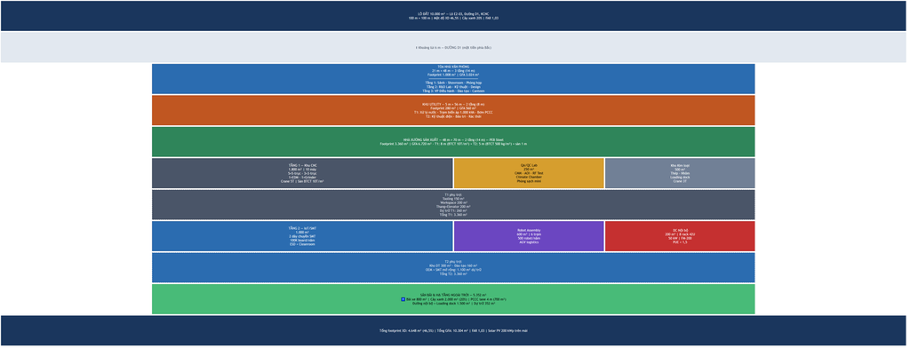

So do 14

### 4.1.4. Bảng Cân đối Diện tích

**A. Cân đối Footprint (mặt đất):**

| Hạng mục | Diện tích (m²) | Tỷ lệ (%) |
| --- | --- | --- |
| Tòa nhà Văn phòng (footprint) | 1.008 | 10,1% |
| Nhà xưởng Sản xuất (footprint) | 3.360 | 33,6% |
| Khu Utility (footprint) | 280 | 2,8% |
| **Tổng diện tích xây dựng** | **4.648** | **46,5%** |
| Đường nội bộ + Loading dock | 1.500 | 15,0% |
| Bãi xe (xe con + xe tải) | 800 | 8,0% |
| Cây xanh + Cảnh quan | 2.000 | 20,0% |
| PCCC lane (4m quanh công trình) | 700 | 7,0% |
| Dự trữ | 352 | 3,5% |
| **Tổng mặt bằng** | **10.000** | **100%** |

**B. Tổng hợp GFA (tổng diện tích sàn xây dựng):**

| Công trình | Footprint (m²) | Số tầng | GFA (m²) | Ghi chú |
| --- | --- | --- | --- | --- |
| Tòa nhà Văn phòng | 1.008 | 3 | 3.024 | BTCT, 14 m |
| Nhà xưởng Sản xuất | 3.360 | **2** | **6.720** | PEB Steel, 14 m (T1: 8 m + T2: 5 m + sàn 1 m) |
| Khu Utility | 280 | **2** | **560** | Kết cấu nhẹ, 8 m |
| **Tổng** | **4.648** | — | **10.304** | FAR = 1,03 |

> **Kiểm tra:** Mật độ xây dựng 46,5% < 70% (cho phép). Cây xanh 20,0% >= 20% (quy định KCNC). PCCC lane 4m quanh toàn bộ công trình. FAR = 10.304 / 10.000 = 1,03. Chiều cao tất cả công trình <= 14 m [C].